# Lipidomics analysis - data from October 2025

Ana Galhoz

2026-07-14

## Run Libraries

```r
rm(list=ls())

library(pheatmap)
library(ggplot2)
library(dichromat)
library(dplyr)
library(ggrepel)
library(reshape2)
library(umap)
library(ggthemes)
library(cowplot)
library(DEP)
library(readr)
library(naniar)
library(SummarizedExperiment)
library(data.table)
library(readxl)
library(writexl)
library(stringr)
library(vsn)
library(rmarkdown)
library(tidyr)
library(Polychrome)
library(RColorBrewer)
library(skimr)
library(rstatix)
# install.packages("devtools")
# if (!require("BiocManager", quietly = TRUE))
#     install.packages("BiocManager")
# options(repos = c(
#     CRAN = "https://cloud.r-project.org/",
#     BiocManager::repositories()))
# ## Install dependencies and package
# devtools::install_github(
#     "BioinfOMICS/LipidSigR",
#     build_vignettes = TRUE, dependencies = TRUE)
# BiocManager::install(
#     c('fgsea', 'gatom', 'mixOmics', 'S4Vectors', 'BiocGenerics',
#       'SummarizedExperiment', 'rgoslin'))
# install.packages(
#     c('devtools', 'magrittr', 'plotly', 'tidyverse', 'factoextra', 'ggthemes',
#       'ggforce', 'Hmisc', 'hwordcloud', 'heatmaply', 'iheatmapr', 'Rtsne', 'uwot',
#       'wordcloud', 'rsample', 'ranger', 'caret', 'yardstick', 'fastshap',
#       'SHAPforxgboost', 'visNetwork', 'tidygraph', 'ggraph'))
# devtools::install_github("ctlab/mwcsr")
```

## Set working directories

```r
knitr::opts_knit$set(root.dir = rprojroot::find_rstudio_root_file())

# create directory for results
dir.create(file.path(getwd(),'results'), showWarnings = FALSE)
# create directory for plots
dir.create(file.path(getwd(),'plots'), showWarnings = FALSE)
```

## Load data

Loading data including:

- All templates: information on the tube ID, rack, visit, country, type of fluid, position
- Shipment of all boxes file: information on the patient ID, visit, position
- Raw data: lipidomics expression with info on the tube ID for CSF and Plasma

### Step 1: merge info of all patients

The **first step** is to *merge* the information of the *“All templates”* and *“Shipment of all boxes”* files, and *create 3 datasets* (one for *plasma*, one for *CSF*, one for *urine*) with the information of *Patient ID, Position, Biofluid, Visit, Tube number, Country, Rack and Box*.

#### - CSF

```r
## sample info - CSF
paged_table(lipidomics_CSF_all)
```

| Patient | Position | Biofluid | Visit | Tube_number | Country | Rack | Box |
| --- | --- | --- | --- | --- | --- | --- | --- |
| TR101 | A1 | CSF | V0 | 7515628797 | Germany | 5500275415 | Box 1 |
| TR102 | A2 | CSF | V0 | 7515613011 | Germany | 5500275415 | Box 1 |
| TR103 | A3 | CSF | V0 | 7515612866 | Germany | 5500275415 | Box 1 |
| TR104 | A4 | CSF | V0 | NA | Germany | 5500275415 | Box 1 |
| TR105 | A5 | CSF | V0 | NA | Germany | 5500275415 | Box 1 |
| TR106 | A6 | CSF | V0 | 7515617365 | Germany | 5500275415 | Box 1 |
| TR201 | A7 | CSF | V0 | NA | Germany | 5500275415 | Box 1 |
| TR202 | A8 | CSF | V0 | 7515628101 | Germany | 5500275415 | Box 1 |
| TR203 | A9 | CSF | V0 | NA | Germany | 5500275415 | Box 1 |
| TR204 | A10 | CSF | V0 | NA | Germany | 5500275415 | Box 1 |

[output cut: 405 more lines]

```r
dim(lipidomics_CSF_all)
```

```
## [1] 415   8
```

```r
lipidomics_CSF_all_summary <- lipidomics_CSF_all %>%
  group_by(Visit) %>%
  summarise(
    total_patients = n_distinct(Patient, na.rm = TRUE),
    total_tubes = n_distinct(Tube_number, na.rm = TRUE),
    total_patients_tubes_pairs = n_distinct(
      paste(Patient, Tube_number)[!is.na(Patient) & !is.na(Tube_number)]))
lipidomics_CSF_all_summary
```

| Visit | total_patients | total_tubes | total_patients_tubes_pairs |
| --- | --- | --- | --- |
| V0 | 200 | 113 | 113 |
| V1 | 153 | 33 | 33 |

```r
# which tube IDs are missing for Patient IDs at V0
lipidomics_CSF_all_V0 = lipidomics_CSF_all %>%
  filter(Visit == "V0")
paged_table(lipidomics_CSF_all_V0 %>%
  filter(is.na(Tube_number) & !is.na(Patient)))
```

| Patient | Position | Biofluid | Visit | Tube_number | Country | Rack | Box |
| --- | --- | --- | --- | --- | --- | --- | --- |
| TR104 | A4 | CSF | V0 | NA | Germany | 5500275415 | Box 1 |
| TR105 | A5 | CSF | V0 | NA | Germany | 5500275415 | Box 1 |
| TR201 | A7 | CSF | V0 | NA | Germany | 5500275415 | Box 1 |
| TR203 | A9 | CSF | V0 | NA | Germany | 5500275415 | Box 1 |
| TR204 | A10 | CSF | V0 | NA | Germany | 5500275415 | Box 1 |
| TR205 | A11 | CSF | V0 | NA | Germany | 5500275415 | Box 1 |
| TR109 | E3 | CSF | V0 | NA | Germany | 5500275415 | Box 1 |
| TR110 | E4 | CSF | V0 | NA | Germany | 5500275415 | Box 1 |
| TR111 | E5 | CSF | V0 | NA | Germany | 5500275415 | Box 1 |
| TR209 | E9 | CSF | V0 | NA | Germany | 5500275415 | Box 1 |

[output cut: 77 more lines]

```r
# check which Patient IDs are duplicated at V0
paged_table(lipidomics_CSF_all_V0 %>%
  filter(Patient %in% lipidomics_CSF_all_V0[duplicated(lipidomics_CSF_all_V0$Patient) & !is.na(lipidomics_CSF_all_V0$Patient),]$Patient))
```

| Patient | Position | Biofluid | Visit | Tube_number | Country | Rack | Box |
| --- | --- | --- | --- | --- | --- | --- | --- |

```r
# which tube IDs are missing for Patient IDs at V1
lipidomics_CSF_all_V1 = lipidomics_CSF_all %>%
  filter(Visit == "V1")
paged_table(lipidomics_CSF_all_V1 %>%
  filter(is.na(Tube_number) & !is.na(Patient)))
```

| Patient | Position | Biofluid | Visit | Tube_number | Country | Rack | Box |
| --- | --- | --- | --- | --- | --- | --- | --- |
| TR103 | B3 | CSF | V1 | NA | Germany | 5500275415 | Box 1 |
| TR104 | B4 | CSF | V1 | NA | Germany | 5500275415 | Box 1 |
| TR105 | B5 | CSF | V1 | NA | Germany | 5500275415 | Box 1 |
| TR106 | B6 | CSF | V1 | NA | Germany | 5500275415 | Box 1 |
| TR201 | B7 | CSF | V1 | NA | Germany | 5500275415 | Box 1 |
| TR202 | B8 | CSF | V1 | NA | Germany | 5500275415 | Box 1 |
| TR203 | B9 | CSF | V1 | NA | Germany | 5500275415 | Box 1 |
| TR204 | B10 | CSF | V1 | NA | Germany | 5500275415 | Box 1 |
| TR205 | B11 | CSF | V1 | NA | Germany | 5500275415 | Box 1 |
| TR206 | B12 | CSF | V1 | NA | Germany | 5500275415 | Box 1 |

[output cut: 110 more lines]

```r
# check which Patient IDs are duplicated at V1
paged_table(lipidomics_CSF_all_V1 %>%
  filter(Patient %in% lipidomics_CSF_all_V1[duplicated(lipidomics_CSF_all_V1$Patient) & !is.na(lipidomics_CSF_all_V1$Patient),]$Patient))
```

| Patient | Position | Biofluid | Visit | Tube_number | Country | Rack | Box |
| --- | --- | --- | --- | --- | --- | --- | --- |

#### - Plasma

```r
## sample info - plasma
paged_table(lipidomics_plasma_all)
```

| Patient | Position | Biofluid | Visit | Tube_number | Country | Rack | Box |
| --- | --- | --- | --- | --- | --- | --- | --- |
| TR101 | A1 | plasma | V0 | 7515628742 | Germany | 5500275402 | Box 1 |
| TR102 | A2 | plasma | V0 | 7515613009 | Germany | 5500275402 | Box 1 |
| TR103 | A3 | plasma | V0 | 7515612917 | Germany | 5500275402 | Box 1 |
| TR104 | A4 | plasma | V0 | 7515610470 | Germany | 5500275402 | Box 1 |
| TR105 | A5 | plasma | V0 | 7515627002 | Germany | 5500275402 | Box 1 |
| TR106 | A6 | plasma | V0 | 7515617201 | Germany | 5500275402 | Box 1 |
| TR201 | A7 | plasma | V0 | 7515607576 | Germany | 5500275402 | Box 1 |
| TR202 | A8 | plasma | V0 | 7515628118 | Germany | 5500275402 | Box 1 |
| TR203 | A9 | plasma | V0 | 7515613868 | Germany | 5500275402 | Box 1 |
| TR204 | A10 | plasma | V0 | 7515611537 | Germany | 5500275402 | Box 1 |

[output cut: 405 more lines]

```r
dim(lipidomics_plasma_all)
```

```
## [1] 415   8
```

```r
lipidomics_plasma_all_summary <- lipidomics_plasma_all %>%
  group_by(Visit) %>%
   summarise(
    total_patients = n_distinct(Patient, na.rm = TRUE),
    total_tubes = n_distinct(Tube_number, na.rm = TRUE),
    total_patients_tubes_pairs = n_distinct(
      paste(Patient, Tube_number)[!is.na(Patient) & !is.na(Tube_number)]))
lipidomics_plasma_all_summary
```

| Visit | total_patients | total_tubes | total_patients_tubes_pairs |
| --- | --- | --- | --- |
| V0 | 200 | 200 | 200 |
| V1 | 153 | 119 | 119 |

```r
# which tube IDs are missing for Patient IDs at V0
lipidomics_plasma_all_V0 = lipidomics_plasma_all %>%
  filter(Visit == "V0")
paged_table(lipidomics_plasma_all_V0 %>%
  filter(is.na(Tube_number) & !is.na(Patient)))
```

| Patient | Position | Biofluid | Visit | Tube_number | Country | Rack | Box |
| --- | --- | --- | --- | --- | --- | --- | --- |

```r
# check which Patient IDs are duplicated at V0
paged_table(lipidomics_plasma_all_V0 %>%
  filter(Patient %in% lipidomics_plasma_all_V0[duplicated(lipidomics_plasma_all_V0$Patient) & !is.na(lipidomics_plasma_all_V0$Patient),]$Patient))
```

| Patient | Position | Biofluid | Visit | Tube_number | Country | Rack | Box |
| --- | --- | --- | --- | --- | --- | --- | --- |

```r
# which tube IDs are missing for Patient IDs at V1
lipidomics_plasma_all_V1 = lipidomics_plasma_all %>%
  filter(Visit == "V1")
paged_table(lipidomics_plasma_all_V1 %>%
  filter(is.na(Tube_number) & !is.na(Patient)))
```

| Patient | Position | Biofluid | Visit | Tube_number | Country | Rack | Box |
| --- | --- | --- | --- | --- | --- | --- | --- |
| TR306 | D6 | plasma | V1 | NA | Germany | 5500275402 | Box 1 |
| DE319 | D11 | plasma | V1 | NA | Germany | 5500275402 | Box 1 |
| DE320 | D12 | plasma | V1 | NA | Germany | 5500275402 | Box 1 |
| TR109 | F3 | plasma | V1 | NA | Germany | 5500275402 | Box 1 |
| DE321 | H7 | plasma | V1 | NA | Germany | 5500275402 | Box 1 |
| DE322 | H8 | plasma | V1 | NA | Germany | 5500275402 | Box 1 |
| DE324 | H10 | plasma | V1 | NA | Germany | 5500275402 | Box 1 |
| DE325 | H11 | plasma | V1 | NA | Germany | 5500275402 | Box 1 |
| DE326 | H12 | plasma | V1 | NA | Germany | 5500275402 | Box 1 |
| TR218 | B12 | plasma | V1 | NA | Germany | 5500275433 | Box 2 |

[output cut: 24 more lines]

```r
# check which Patient IDs are duplicated at V1
paged_table(lipidomics_plasma_all_V1 %>%
  filter(Patient %in% lipidomics_plasma_all_V1[duplicated(lipidomics_plasma_all_V1$Patient) & !is.na(lipidomics_plasma_all_V1$Patient),]$Patient))
```

| Patient | Position | Biofluid | Visit | Tube_number | Country | Rack | Box |
| --- | --- | --- | --- | --- | --- | --- | --- |

#### - Urine

```r
## sample info - urine
paged_table(lipidomics_urine_all)
```

| Patient | Position | Biofluid | Visit | Tube_number | Country | Rack | Box |
| --- | --- | --- | --- | --- | --- | --- | --- |
| TR101 | A1 | urine | V0 | 7515628815 | Germany | 5500275399 | Box 1 |
| TR102 | A2 | urine | V0 | 7515613242 | Germany | 5500275399 | Box 1 |
| TR103 | A3 | urine | V0 | 7515612089 | Germany | 5500275399 | Box 1 |
| TR104 | A4 | urine | V0 | 7515607709 | Germany | 5500275399 | Box 1 |
| TR105 | A5 | urine | V0 | 7515626125 | Germany | 5500275399 | Box 1 |
| TR106 | A6 | urine | V0 | 7515617237 | Germany | 5500275399 | Box 1 |
| TR201 | A7 | urine | V0 | 7515607513 | Germany | 5500275399 | Box 1 |
| TR202 | A8 | urine | V0 | 7515628130 | Germany | 5500275399 | Box 1 |
| TR203 | A9 | urine | V0 | 7515613144 | Germany | 5500275399 | Box 1 |
| TR204 | A10 | urine | V0 | 7515611691 | Germany | 5500275399 | Box 1 |

[output cut: 374 more lines]

```r
dim(lipidomics_urine_all)
```

```
## [1] 384   8
```

```r
lipidomics_urine_all_summary <- lipidomics_urine_all %>%
  group_by(Visit) %>%
  summarise(
    total_patients = n_distinct(Patient, na.rm = TRUE),
    total_tubes = n_distinct(Tube_number, na.rm = TRUE),
    total_patients_tubes_pairs = n_distinct(
      paste(Patient, Tube_number)[!is.na(Patient) & !is.na(Tube_number)]))
lipidomics_urine_all_summary
```

| Visit | total_patients | total_tubes | total_patients_tubes_pairs |
| --- | --- | --- | --- |
| V0 | 200 | 199 | 199 |
| V1 | 153 | 118 | 118 |

```r
# which tube IDs are missing for Patient IDs at V0
lipidomics_urine_all_V0 = lipidomics_urine_all %>%
  filter(Visit == "V0")
paged_table(lipidomics_urine_all_V0 %>%
  filter(is.na(Tube_number) & !is.na(Patient)))
```

| Patient | Position | Biofluid | Visit | Tube_number | Country | Rack | Box |
| --- | --- | --- | --- | --- | --- | --- | --- |
| SK314 | E6 | urine | V0 | NA | Germany | 5500275464 | Box 4 |

```r
# check which Patient IDs are duplicated at V0
paged_table(lipidomics_urine_all_V0 %>%
  filter(Patient %in% lipidomics_urine_all_V0[duplicated(lipidomics_urine_all_V0$Patient) & !is.na(lipidomics_urine_all_V0$Patient),]$Patient))
```

| Patient | Position | Biofluid | Visit | Tube_number | Country | Rack | Box |
| --- | --- | --- | --- | --- | --- | --- | --- |

```r
# which tube IDs are missing for Patient IDs at V1
lipidomics_urine_all_V1 = lipidomics_urine_all %>%
  filter(Visit == "V1")
paged_table(lipidomics_urine_all_V1 %>%
  filter(is.na(Tube_number) & !is.na(Patient)))
```

| Patient | Position | Biofluid | Visit | Tube_number | Country | Rack | Box |
| --- | --- | --- | --- | --- | --- | --- | --- |
| TR306 | D6 | urine | V1 | NA | Germany | 5500275399 | Box 1 |
| DE319 | D11 | urine | V1 | NA | Germany | 5500275399 | Box 1 |
| DE320 | D12 | urine | V1 | NA | Germany | 5500275399 | Box 1 |
| TR109 | F3 | urine | V1 | NA | Germany | 5500275399 | Box 1 |
| DE321 | H7 | urine | V1 | NA | Germany | 5500275399 | Box 1 |
| DE322 | H8 | urine | V1 | NA | Germany | 5500275399 | Box 1 |
| DE324 | H10 | urine | V1 | NA | Germany | 5500275399 | Box 1 |
| DE325 | H11 | urine | V1 | NA | Germany | 5500275399 | Box 1 |
| DE326 | H12 | urine | V1 | NA | Germany | 5500275399 | Box 1 |
| TR218 | B12 | urine | V1 | NA | Germany | 5500275429 | Box 2 |

[output cut: 25 more lines]

```r
# check which Patient IDs are duplicated at V1
paged_table(lipidomics_urine_all_V1 %>%
  filter(Patient %in% lipidomics_urine_all_V1[duplicated(lipidomics_urine_all_V1$Patient) & !is.na(lipidomics_urine_all_V1$Patient),]$Patient))
```

| Patient | Position | Biofluid | Visit | Tube_number | Country | Rack | Box |
| --- | --- | --- | --- | --- | --- | --- | --- |

### Step 2: aggregate all raw files

The **second step** is to *aggregate* all the raw data files together and save the batch information, in order to check later if there are any batch effects in the data.

#### - CSF

```r
paged_table(raw_data_CSF_final)
```

| Tube_number | Batch | CE(18:1-d7) | Cholesterol(d7) | DG(15:0/18:1-d7) | LPC(18:1-d7) | LPE(18:1-d7) | PC(15:0/18:1-d7) | PE(15:0/18:1-d7) | PG(15:0-18:1-d7)_(HG,172) | PI(15:0-18:1-d7)_(HG,260) | PS(15:0-18:1-d7)_(HG,185) | SM(d18:1/18:1-d9) | TG(15:0/18:1-d7/15:0) | CE(16:0) | CE(16:1) | CE(18:1) | CE(18:2) | CE(18:3) | CE(18:4) | CE(20:3) | CE(20:4) | CE(20:5) | CE(22:5) | CE(22:6) | Cer(32:1-2)_d16:1/16:0 | Cer(32:2-3)_d16:1/16:1 | Cer(33:2-3)_d18:1/15:1 | Cer(34:0-2)_d18:0/16:0 | Cer(34:1-4)_d18:1/16:0 | … |
| --- | --- | --- | --- | --- | --- | --- | --- | --- | --- | --- | --- | --- | --- | --- | --- | --- | --- | --- | --- | --- | --- | --- | --- | --- | --- | --- | --- | --- | --- | --- |
| QC_1 | Batch 1 | 57036.52 | 92077.00 | 84082.04 | 2667632 | 149876.70 | 98567592 | 956817.1 | 94732.98 | 11984.6579417542 | 369668.0 | 12718833 | 13983570 | N/A | N/A | N/A | 4839.1920722390996 | N/A | N/A | N/A | N/A | N/A | N/A | N/A | N/A | N/A | N/A | N/A | N/A | … |
| 7515609572 | Batch 1 | 98822.51 | 101391.30 | 96225.03 | 3078790 | 168844.93 | 86089708 | 844543.9 | 77681.08 | 15885.1774346367 | 450035.7 | 16404780 | 15222099 | N/A | N/A | N/A | N/A | N/A | N/A | N/A | N/A | N/A | N/A | N/A | N/A | N/A | N/A | N/A | N/A | … |
| 7515628582 | Batch 1 | 36841.74 | 122907.60 | 70407.52 | 2926459 | 139265.66 | 75916519 | 1005209.5 | 91965.79 | 23500.7566235973 | 393532.4 | 12863087 | 15018306 | N/A | N/A | N/A | N/A | N/A | N/A | N/A | 7576.8454325703397 | N/A | N/A | N/A | N/A | N/A | N/A | N/A | N/A | … |
| 7515619503 | Batch 1 | 70218.86 | 105725.52 | 103487.22 | 2682236 | 154127.39 | 76445289 | 1070983.3 | 49137.11 | 13789.7985634966 | 417197.9 | 13949443 | 15562744 | N/A | N/A | N/A | N/A | N/A | N/A | N/A | N/A | N/A | N/A | N/A | N/A | N/A | N/A | N/A | N/A | … |
| 7515612949 | Batch 1 | 68577.62 | 114305.80 | 50028.38 | 2718798 | 149322.90 | 70149416 | 1142727.1 | 96120.62 | 8012.86183536163 | 435862.2 | 15449725 | 14872686 | N/A | N/A | N/A | N/A | N/A | N/A | N/A | N/A | N/A | N/A | N/A | N/A | N/A | N/A | N/A | N/A | … |
| 7515628173 | Batch 1 | 59866.30 | 129428.19 | 75100.27 | 2597623 | 131372.11 | 89564285 | 939981.0 | 80357.74 | 7845.01895225742 | 411455.5 | 13632468 | 10805279 | N/A | N/A | N/A | N/A | N/A | N/A | N/A | N/A | N/A | N/A | N/A | N/A | N/A | N/A | N/A | N/A | … |
| QC_2 | Batch 1 | 69910.41 | 93186.04 | 67148.55 | 2485497 | 148225.45 | 83780545 | 913859.2 | 89479.81 | 13553.6094357404 | 326092.7 | 12608995 | 10869868 | N/A | N/A | N/A | N/A | N/A | N/A | N/A | N/A | N/A | N/A | N/A | N/A | N/A | N/A | N/A | N/A | … |
| 7515619901 | Batch 1 | 82617.69 | 110146.60 | 83437.72 | 2667307 | 163912.19 | 79196780 | 1165600.0 | 98366.39 | 7869.23271503102 | 420209.5 | 13367297 | 13782172 | N/A | N/A | N/A | 11702.277875243 | N/A | N/A | N/A | 6338.4768708642596 | N/A | N/A | N/A | N/A | N/A | N/A | N/A | N/A | … |
| 7515612736 | Batch 1 | 48860.26 | 58322.75 | 39578.03 | 1773840 | 110507.45 | 77668417 | 598723.4 | 81446.59 | 19246.3046838513 | 364040.4 | 8919491 | 7819690 | N/A | N/A | N/A | N/A | N/A | N/A | N/A | N/A | N/A | N/A | N/A | N/A | N/A | N/A | N/A | N/A | … |
| 7515602615 | Batch 1 | 86109.97 | 163921.93 | 104723.99 | 3299166 | 166646.92 | 84722436 | 1128642.1 | 126905.98 | 16215.3047645936 | 504843.2 | 15874837 | 10697510 | N/A | N/A | N/A | N/A | N/A | N/A | N/A | N/A | N/A | N/A | N/A | N/A | N/A | N/A | N/A | N/A | … |

[output cut: 164 more lines]

```r
dim(raw_data_CSF_final)
```

```
## [1] 174 894
```

```r
# how many rows of QC
length(grep("QC",raw_data_CSF_final$Tube_number))
```

```
## [1] 30
```

#### - Plasma

```r
paged_table(raw_data_plasma_final)
```

| Tube_number | Batch | CE(18:1-d7) | Cholesterol(d7) | DG(15:0/18:1-d7) | LPC(18:1-d7) | LPE(18:1-d7) | PC(15:0/18:1-d7) | PE(15:0/18:1-d7) | PG(15:0-18:1-d7)_(HG,172) | PI(15:0-18:1-d7)_(HG,260) | PS(15:0-18:1-d7)_(HG,185) | SM(d18:1/18:1-d9) | TG(15:0/18:1-d7/15:0) | CE(16:0) | CE(16:1) | CE(18:1) | CE(18:2) | CE(18:3) | CE(18:4) | CE(20:3) | CE(20:4) | CE(20:5) | CE(22:5) | CE(22:6) | Cer(32:1-2)_d16:1/16:0 | Cer(32:2-3)_d16:1/16:1 | Cer(33:2-3)_d18:1/15:1 | Cer(34:0-2)_d18:0/16:0 | Cer(34:1-4)_d18:1/16:0 | … |
| --- | --- | --- | --- | --- | --- | --- | --- | --- | --- | --- | --- | --- | --- | --- | --- | --- | --- | --- | --- | --- | --- | --- | --- | --- | --- | --- | --- | --- | --- | --- |
| QC_1 | Batch 1 | 3100.6851722240399 | 154706.47 | 12971.6820029516 | 2047565.6 | 122980.66 | 34903703 | 261250.28 | 34061.096 | 18768.290354106 | 300033.9 | 9303920 | 2138602.6 | 4893.3404173782101 | 10798.711783103799 | 55835.50 | 595351.6 | 51332.85 | N/A | 28521.7055880675 | 328116.50 | 68963.506680314 | N/A | 102970.07 | N/A | N/A | N/A | N/A | N/A | … |
| 7515627866 | Batch 1 | 10629.0962832189 | 94107.03 | 6395.8575486569798 | 1451732.0 | 70850.12 | 31361844 | 257116.51 | 28930.194 | 9586.9340836142601 | 179617.0 | 6420735 | 2344749.2 | 6659.0605832953197 | 8838.3955014120802 | 56335.86 | 605450.0 | 27883.11 | N/A | 22432.495202064 | 220592.96 | 60271.0888200998 | 5344.7275730826104 | 53755.52 | N/A | 7868.4319712301804 | N/A | N/A | 21075.102580717201 | … |
| 7515611579 | Batch 1 | 5762.9782282188899 | 136495.61 | 7347.5817177829103 | 2057510.3 | 106527.50 | 36150936 | 339392.23 | 82465.445 | 13744.517553154499 | 357628.0 | 7641750 | 2863451.6 | 4060.4794909522202 | 15209.435734891 | 88191.86 | 867197.5 | 58573.62 | N/A | 25755.8161263101 | 374462.32 | 121916.044990953 | 12409.123339280901 | 316582.11 | N/A | N/A | 22753.818084934199 | N/A | 17408.474221545199 | … |
| 7515617201 | Batch 1 | N/A | 153003.99 | 26670.269133645801 | 2029594.5 | 115730.80 | 32994916 | 283643.68 | 59239.131 | 13903.9050944724 | 346983.4 | 7779452 | 2666348.6 | 3137.1087097616901 | 8832.3529251603304 | 61088.23 | 567498.3 | 27298.97 | N/A | 13695.71197792 | 346660.65 | 26546.0095501612 | 3335.01767485851 | 73914.28 | N/A | 8915.3998102879304 | 15793.586970632799 | N/A | N/A | … |
| 7515610470 | Batch 1 | 4446.9091541370199 | 119671.34 | 9417.9491999053807 | 2028725.3 | 112521.42 | 31546964 | 293615.28 | 56785.629 | 10514.864595347501 | 311207.2 | 7684373 | 1929711.4 | N/A | 9328.1292310350891 | 72568.51 | 789781.8 | 58410.21 | N/A | 11172.8562806059 | 398759.64 | 36657.4874662003 | 3322.8959882461199 | 118923.78 | N/A | N/A | 19421.143027677801 | N/A | N/A | … |
| 7515619922 | Batch 1 | 10164.610453360599 | 152268.57 | 25466.7057779934 | 2121403.0 | 102560.87 | 39823878 | 321438.49 | 76173.415 | 15283.9343278653 | 339988.8 | 8305963 | 2524088.8 | 5334.7024236492398 | 7866.4558583825501 | 69905.60 | 678847.2 | 30265.01 | N/A | 10671.3657245716 | 271488.39 | 9164.43241780936 | N/A | 20968.39 | N/A | N/A | 21286.358704694401 | N/A | N/A | … |
| QC_2 | Batch 1 | 4453.0033379411798 | 129955.99 | 13684.8787041899 | 2279702.4 | 103122.01 | 37119533 | 262378.59 | 79437.661 | 12211.809099640401 | 334810.9 | 8439293 | 2982279.3 | 3561.0162369490299 | 15689.937058236501 | 55316.58 | 607368.1 | 59065.64 | N/A | 22836.2185605465 | 278482.56 | 58779.5629283958 | 8094.3289901548096 | 86941.30 | N/A | N/A | 20775.976681372402 | 16146.112620166199 | 21830.620033426501 | … |
| 7515612983 | Batch 1 | 4436.6003727262896 | 148692.67 | 10524.741065377601 | 2111042.5 | 111403.68 | 42465920 | 275307.71 | 31778.971 | 12955.7304315888 | 306997.2 | 8329751 | 2716185.6 | 2635.8280906444302 | 8351.36197345851 | 25936.42 | 654423.8 | 24028.49 | N/A | 27275.4357402292 | 336510.78 | 15437.7881610407 | 6327.9364054007501 | 57165.54 | N/A | N/A | 29678.131673891301 | N/A | N/A | … |
| 7515627780 | Batch 1 | 10189.5342194528 | 121005.55 | 41091.1665786046 | 2340475.1 | 118164.82 | 33404754 | 312672.26 | 36403.934 | 11958.013212485699 | 320598.4 | 7517446 | 1763032.3 | 6656.1038760521797 | 33823.503633979803 | 109741.30 | 662423.8 | 78375.38 | N/A | 27214.1438720106 | 426923.45 | 161977.83739169 | 6791.0388231079496 | 102776.40 | N/A | 12462.896957438399 | 14343.413398398499 | N/A | N/A | … |
| 7515613868 | Batch 1 | N/A | 133787.98 | 12534.437306370201 | 2073401.1 | 98600.35 | 37833460 | 284734.60 | 36104.206 | 40400.604601550302 | 279697.8 | 8502764 | 3239002.8 | 3112.27538790585 | 9816.8488743634607 | 49202.48 | 629327.7 | 38043.44 | N/A | 25233.9640686829 | 252911.02 | 62211.1004843835 | 10689.491753668401 | 137701.98 | N/A | N/A | 28378.6642356802 | N/A | N/A | … |

[output cut: 372 more lines]

```r
dim(raw_data_plasma_final)
```

```
## [1] 382 894
```

```r
# how many rows of QC
length(grep("QC",raw_data_plasma_final$Tube_number))
```

```
## [1] 66
```

## Overview of data

### Step 3: Combine raw data files with patient info

The **third step** is to *combine* the raw data files with the patient information, and check the amount of samples per visit for each fluid.

#### - CSF

```r
raw_data_CSF_IDs = raw_data_CSF_final %>%
  select(Tube_number,Batch)
raw_data_CSF_IDs <- raw_data_CSF_IDs %>%
  mutate(Tube_number4 = str_sub(Tube_number,-4)) %>% # last 4 digits
  filter(!str_detect(Tube_number, "QC")) # remove 30 QC IDs

# how many IDs in the raw data CSF
length(raw_data_CSF_IDs$Tube_number)
```

```
## [1] 144
```

```r
# how many unique IDs in the raw data CSF
length(unique(raw_data_CSF_IDs$Tube_number))
```

```
## [1] 144
```

```r
lipidomics_CSF_all <- lipidomics_CSF_all %>%
  mutate(Tube_number4 = str_sub(Tube_number,-4)) # last 4 digits
full_match_CSF = raw_data_CSF_IDs %>%
  left_join(lipidomics_CSF_all,by = "Tube_number") %>%
  mutate(match_type = ifelse(!is.na(Tube_number4.y),"Full",NA))
no_match_CSF = full_match_CSF %>%
  filter(is.na(match_type)) %>%
  dplyr::rename(Tube_number4 = Tube_number4.y) %>%
  select(-names(lipidomics_CSF_all)) %>%
  dplyr::rename(Tube_number4 = Tube_number4.x)
last4_match_CSF = no_match_CSF %>%
  left_join(lipidomics_CSF_all %>%
              filter(!Tube_number %in% (full_match_CSF %>% filter(!is.na(match_type)) %>%
                                          pull(Tube_number))),
            by = "Tube_number4") %>%
  mutate(match_type = ifelse(!is.na(Tube_number),"Last4","No match"))

# final description of the samples available in the raw data without QC samples
combined_data_CSF = full_match_CSF %>%
  filter(!is.na(match_type)) %>%
  select(-c(Tube_number4.x,Tube_number4.y,match_type)) %>%
  bind_rows(last4_match_CSF %>%
              select(-Tube_number) %>%
              left_join(raw_data_CSF_IDs %>% select(Tube_number,Tube_number4) %>%
                          filter(!Tube_number %in% (full_match_CSF %>% filter(!is.na(match_type)) %>%
                                          pull(Tube_number)))) %>%
              select(Tube_number,Patient,Position,Biofluid,Visit,Country,Rack,Box,Batch)) %>%
  distinct()

paged_table(combined_data_CSF)
```

| Tube_number | Batch | Patient | Position | Biofluid | Visit | Country | Rack | Box |
| --- | --- | --- | --- | --- | --- | --- | --- | --- |
| 7515609572 | Batch 1 | TR212 | F12 | CSF | V1 | Germany | 5500275415 | Box 1 |
| 7515628582 | Batch 1 | TR307 | G1 | CSF | V0 | Germany | 5500275415 | Box 1 |
| 7515619503 | Batch 1 | TR207 | E7 | CSF | V0 | Germany | 5500275415 | Box 1 |
| 7515612949 | Batch 1 | TR312 | G6 | CSF | V0 | Germany | 5500275415 | Box 1 |
| 7515628173 | Batch 1 | TR304 | C4 | CSF | V0 | Germany | 5500275415 | Box 1 |
| 7515619901 | Batch 1 | TR206 | A12 | CSF | V0 | Germany | 5500275415 | Box 1 |
| 7515612736 | Batch 1 | TR301 | C1 | CSF | V0 | Germany | 5500275415 | Box 1 |
| 7515602615 | Batch 1 | DE322 | G8 | CSF | V0 | Germany | 5500275415 | Box 1 |
| 7515607842 | Batch 1 | TR108 | F2 | CSF | V1 | Germany | 5500275415 | Box 1 |
| 7515628269 | Batch 1 | DE315 | C7 | CSF | V0 | Germany | 5500275415 | Box 1 |

[output cut: 134 more lines]

```r
# how many IDs in the raw data CSF now
length(combined_data_CSF$Tube_number)
```

```
## [1] 144
```

```r
# how many unique IDs in the raw data CSF now
length(unique(combined_data_CSF$Tube_number))
```

```
## [1] 144
```

```r
# how many unique Patient IDs
length(unique(na.omit(combined_data_CSF$Patient)))
```

```
## [1] 112
```

```r
# how many tube numbers and patient IDs per V0 and V1
combined_data_CSF %>%
  group_by(Visit) %>%
  summarise(
    total_patients = n_distinct(Patient, na.rm = TRUE), # amount of patient IDs
    total_tubes = n_distinct(Tube_number, na.rm = TRUE), # amount of tube numbers
    total_patients_tubes_pairs = n_distinct(
      paste(Patient, Tube_number)[!is.na(Patient) & !is.na(Tube_number)])) # amount of pairs
```

| Visit | total_patients | total_tubes | total_patients_tubes_pairs |
| --- | --- | --- | --- |
| V0 | 111 | 111 | 111 |
| V1 | 33 | 33 | 33 |

```r
# which Tube numbers at V1 do not have a patient ID
combined_data_CSF %>%
  filter(Visit == "V1") %>%
  filter(is.na(Patient))
```

| Tube_number | Batch | Patient | Position | Biofluid | Visit | Country | Rack | Box |
| --- | --- | --- | --- | --- | --- | --- | --- | --- |

```r
# patients at V0 and V1
patients_CSF_V0 <- combined_data_CSF %>%
  filter(Visit == "V0") %>%
  pull(Patient) %>%
  unique()
patients_CSF_V1 <- combined_data_CSF %>%
  filter(Visit == "V1") %>%
  pull(Patient) %>%
  unique() %>%
  na.omit()

# check if all patients at V1 are at V0
all(patients_CSF_V1 %in% patients_CSF_V0)
```

```
## [1] FALSE
```

```r
patients_CSF_V1[!patients_CSF_V1 %in% patients_CSF_V0] # patient TR319
```

```
## [1] "TR319"
```

```r
# check patient in the info_patient dataset
lipidomics_CSF_all[lipidomics_CSF_all$Patient %in% patients_CSF_V1[!patients_CSF_V1 %in% patients_CSF_V0],]
```

| Patient | Position | Biofluid | Visit | Tube_number | Country | Rack | Box | Tube_number4 |
| --- | --- | --- | --- | --- | --- | --- | --- | --- |
| TR319 | G1 | CSF | V0 | NA | Germany | 5500275414 | Box 2 | NA |
| TR319 | H1 | CSF | V1 | 7515621732 | Germany | 5500275414 | Box 2 | 1732 |

#### - Plasma

```r
raw_data_plasma_IDs = raw_data_plasma_final %>%
  select(Tube_number,Batch)
raw_data_plasma_IDs <- raw_data_plasma_IDs %>%
  mutate(Tube_number4 = str_sub(Tube_number,-4)) %>% # last 4 digits
  filter(!str_detect(Tube_number, "QC")) # remove 66 QC IDs

# how many IDs in the raw data plasma
length(raw_data_plasma_IDs$Tube_number)
```

```
## [1] 316
```

```r
# how many unique IDs in the raw data plasma
length(unique(raw_data_plasma_IDs$Tube_number))
```

```
## [1] 316
```

```r
lipidomics_plasma_all <- lipidomics_plasma_all %>%
  mutate(Tube_number4 = str_sub(Tube_number,-4)) # last 4 digits
full_match_plasma = raw_data_plasma_IDs %>%
  left_join(lipidomics_plasma_all,by = "Tube_number") %>%
  mutate(match_type = ifelse(!is.na(Tube_number4.y),"Full",NA))
no_match_plasma = full_match_plasma %>%
  filter(is.na(match_type)) %>%
  dplyr::rename(Tube_number4 = Tube_number4.y) %>%
  select(-names(lipidomics_plasma_all)) %>%
  dplyr::rename(Tube_number4 = Tube_number4.x)
last4_match_plasma = no_match_plasma %>%
  left_join(lipidomics_plasma_all,by = "Tube_number4") %>%
  mutate(match_type = ifelse(!is.na(Tube_number),"Last4","No match"))

# final description of the samples available in the raw data without QC samples
combined_data_plasma = full_match_plasma %>%
  filter(!is.na(match_type)) %>%
  select(-c(Tube_number4.x,Tube_number4.y,match_type)) %>%
  bind_rows(last4_match_plasma %>%
              select(-Tube_number) %>%
              left_join(raw_data_plasma_IDs %>% select(Tube_number,Tube_number4)) %>%
              select(Tube_number,Patient,Position,Biofluid,Visit,Country,Rack,Box,Batch)) %>%
  distinct()

paged_table(combined_data_plasma)
```

| Tube_number | Batch | Patient | Position | Biofluid | Visit | Country | Rack | Box |
| --- | --- | --- | --- | --- | --- | --- | --- | --- |
| 7515627866 | Batch 1 | DE318 | C10 | plasma | V0 | Germany | 5500275402 | Box 1 |
| 7515611579 | Batch 1 | TR204 | B10 | plasma | V1 | Germany | 5500275402 | Box 1 |
| 7515617201 | Batch 1 | TR106 | A6 | plasma | V0 | Germany | 5500275402 | Box 1 |
| 7515610470 | Batch 1 | TR104 | A4 | plasma | V0 | Germany | 5500275402 | Box 1 |
| 7515619922 | Batch 1 | TR206 | A12 | plasma | V0 | Germany | 5500275402 | Box 1 |
| 7515612983 | Batch 1 | TR102 | B2 | plasma | V1 | Germany | 5500275402 | Box 1 |
| 7515627780 | Batch 1 | DE317 | D9 | plasma | V1 | Germany | 5500275402 | Box 1 |
| 7515613868 | Batch 1 | TR203 | A9 | plasma | V0 | Germany | 5500275402 | Box 1 |
| 7515628259 | Batch 1 | DE315 | D7 | plasma | V1 | Germany | 5500275402 | Box 1 |
| 7515629161 | Batch 1 | TR303 | C3 | plasma | V0 | Germany | 5500275402 | Box 1 |

[output cut: 306 more lines]

```r
# how many IDs in the raw data plasma now
length(combined_data_plasma$Tube_number)
```

```
## [1] 316
```

```r
# how many unique IDs in the raw data plasma now
length(unique(combined_data_plasma$Tube_number))
```

```
## [1] 316
```

```r
# how many unique Patient IDs
length(unique(na.omit(combined_data_plasma$Patient)))
```

```
## [1] 200
```

```r
# how many tube numbers and patient IDs per V0 and V1
combined_data_plasma %>%
  group_by(Visit) %>%
  summarise(
    total_patients = n_distinct(Patient, na.rm = TRUE), # amount of patient IDs
    total_tubes = n_distinct(Tube_number, na.rm = TRUE), # amount of tube numbers
    total_patients_tubes_pairs = n_distinct(
      paste(Patient, Tube_number)[!is.na(Patient) & !is.na(Tube_number)])) # amount of pairs
```

| Visit | total_patients | total_tubes | total_patients_tubes_pairs |
| --- | --- | --- | --- |
| V0 | 197 | 197 | 197 |
| V1 | 119 | 119 | 119 |

```r
# which Tube numbers at V0 do not have a patient ID
combined_data_plasma %>%
  filter(Visit == "V0") %>%
  filter(is.na(Patient))
```

| Tube_number | Batch | Patient | Position | Biofluid | Visit | Country | Rack | Box |
| --- | --- | --- | --- | --- | --- | --- | --- | --- |

```r
# which Tube numbers at V1 do not have a patient ID
combined_data_plasma %>%
  filter(Visit == "V1") %>%
  filter(is.na(Patient))
```

| Tube_number | Batch | Patient | Position | Biofluid | Visit | Country | Rack | Box |
| --- | --- | --- | --- | --- | --- | --- | --- | --- |

```r
# patients at V0 and V1
patients_plasma_V0 <- combined_data_plasma %>%
  filter(Visit == "V0") %>%
  pull(Patient) %>%
  unique()
patients_plasma_V1 <- combined_data_plasma %>%
  filter(Visit == "V1") %>%
  pull(Patient) %>%
  unique() %>%
  na.omit()

# check if all patients at V1 are at V0
all(patients_plasma_V1 %in% patients_plasma_V0)
```

```
## [1] FALSE
```

```r
patients_plasma_V1[!patients_plasma_V1 %in% patients_plasma_V0] # patients TR207, TR116 and TR123
```

```
## [1] "TR207" "TR116" "TR123"
```

```r
# check patient in the info_patient dataset
lipidomics_plasma_all[lipidomics_plasma_all$Patient %in% patients_plasma_V1[!patients_plasma_V1 %in% patients_plasma_V0],]
```

| Patient | Position | Biofluid | Visit | Tube_number | Country | Rack | Box | Tube_number4 |
| --- | --- | --- | --- | --- | --- | --- | --- | --- |
| TR207 | E7 | plasma | V0 | 7515619537 | Germany | 5500275402 | Box 1 | 9537 |
| TR207 | F7 | plasma | V1 | 7515619460 | Germany | 5500275402 | Box 1 | 9460 |
| TR116 | A4 | plasma | V0 | 7515613830 | Germany | 5500275433 | Box 2 | 3830 |
| TR116 | B4 | plasma | V1 | 7515613777 | Germany | 5500275433 | Box 2 | 3777 |
| TR123 | E5 | plasma | V0 | 7515632728 | Germany | 5500275433 | Box 2 | 2728 |
| TR123 | F5 | plasma | V1 | 7515632680 | Germany | 5500275433 | Box 2 | 2680 |

#### Step 4: Overview of the samples based on status

The **fourth step** is to *give an overview* of how many samples of *eALS*, *PGMC*, *CTR* and *mimic* we have *per fluid*, *visit* and *country*.

#### - CSF (the patient IDs given by Laura) - not displaying, but it is in code

| PatientID | Visit | Patient | type | Country |
| --- | --- | --- | --- | --- |
| JM8KA1A3 | V0 | CH101 | PGMC | Switzerland |
| JM8KA1A3 | V0 | CH101 | C9orf72 | Switzerland |
| JM8KA1A3 | V1 | CH101 | PGMC | Switzerland |
| JM8KA1A3 | V1 | CH101 | C9orf72 | Switzerland |
| 353CQQM2 | V0 | CH102 | PGMC | Switzerland |
| 353CQQM2 | V0 | CH102 | C9orf72 | Switzerland |
| 353CQQM2 | V1 | CH102 | PGMC | Switzerland |
| 353CQQM2 | V1 | CH102 | C9orf72 | Switzerland |
| EWU49KM1 | V0 | CH201 | CTR | Switzerland |
| EWU49KM1 | V1 | CH201 | CTR | Switzerland |

[output cut: 222 more lines]

| Visit | Country | n_unique_patients |
| --- | --- | --- |
| V0 | Germany | 43 |
| V0 | Turkey | 34 |
| V0 | Slovakia | 32 |
| V0 | Switzerland | 10 |
| V0 | France | 9 |
| V0 | Israel | 7 |
| V0 | NA | 7 |
| V1 | Turkey | 18 |
| V1 | Germany | 9 |
| V1 | France | 4 |

[output cut: 4 more lines]

| Visit | Country | PGMC | CTR | ALS | mimic | SYMP | C9orf72 | SOD1 | TARDBP | FUS | other | NA |
| --- | --- | --- | --- | --- | --- | --- | --- | --- | --- | --- | --- | --- |
| V0 | France | 4 | 1 | 4 | 0 | 0 | 4 | 0 | 0 | 0 | 0 | 0 |
| V0 | Germany | 7 | 4 | 22 | 6 | 3 | 4 | 0 | 1 | 2 | 0 | 1 |
| V0 | Slovakia | 0 | 5 | 20 | 5 | 2 | 0 | 0 | 0 | 0 | 0 | 0 |
| V0 | Turkey | 12 | 7 | 12 | 2 | 1 | 4 | 6 | 1 | 0 | 1 | 0 |
| V0 | NA | 3 | 0 | 2 | 0 | 0 | 1 | 1 | 0 | 1 | 0 | 2 |
| V1 | France | 3 | 0 | 1 | 0 | 0 | 3 | 0 | 0 | 0 | 0 | 0 |
| V1 | Germany | 1 | 2 | 2 | 2 | 1 | 0 | 0 | 1 | 0 | 0 | 1 |
| V1 | Slovakia | 0 | 1 | 3 | 0 | 0 | 0 | 0 | 0 | 0 | 0 | 0 |
| V1 | Turkey | 6 | 3 | 7 | 2 | 0 | 3 | 2 | 0 | 0 | 1 | 0 |
| V0 | Israel | 3 | 2 | 0 | 0 | 0 | 3 | 0 | 0 | 0 | 0 | 2 |

[output cut: 4 more lines]

#### - CSF (the patient IDs existing in the raw data)

```r
IDs_CSF_data = combined_data_CSF %>%
  select(Patient,Visit,Tube_number) %>%
  distinct() %>%
  left_join(all_participants_IDs %>% dplyr::rename(Patient = ParticipantCode)) %>%
  mutate(
    Country = dplyr::case_when(
      grepl("TR", Patient) ~ "Turkey",
      grepl("CH", Patient) ~ "Switzerland",
      grepl("DE", Patient) ~ "Germany",
      grepl("SK", Patient) ~ "Slovakia",
      grepl("FR", Patient) ~ "France",
      grepl("IL", Patient) ~ "Israel",
      TRUE                 ~ NA_character_
    )) %>%
  arrange(Patient)

paged_table(IDs_CSF_data)
```

| Patient | Visit | Tube_number | PatientID | type | Country |
| --- | --- | --- | --- | --- | --- |
| CH101 | V0 | 7515618121 | JM8KA1A3 | PGMC | Switzerland |
| CH101 | V0 | 7515618121 | JM8KA1A3 | C9orf72 | Switzerland |
| CH101 | V1 | 7515618144 | JM8KA1A3 | PGMC | Switzerland |
| CH101 | V1 | 7515618144 | JM8KA1A3 | C9orf72 | Switzerland |
| CH102 | V1 | 7515618096 | 353CQQM2 | PGMC | Switzerland |
| CH102 | V1 | 7515618096 | 353CQQM2 | C9orf72 | Switzerland |
| CH102 | V0 | 7515618074 | 353CQQM2 | PGMC | Switzerland |
| CH102 | V0 | 7515618074 | 353CQQM2 | C9orf72 | Switzerland |
| CH201 | V0 | 7515624007 | EWU49KM1 | CTR | Switzerland |
| CH201 | V1 | 7515623988 | EWU49KM1 | CTR | Switzerland |

[output cut: 164 more lines]

```r
overview_country_CSF = IDs_CSF_data %>%
  group_by(Visit,Country) %>%
  summarise(n_unique_patients = n_distinct(Patient),.groups = "drop") %>%
  arrange(Visit,desc(n_unique_patients))
overview_country_CSF
```

| Visit | Country | n_unique_patients |
| --- | --- | --- |
| V0 | Germany | 38 |
| V0 | Turkey | 31 |
| V0 | Slovakia | 27 |
| V0 | Switzerland | 9 |
| V0 | France | 6 |
| V1 | Turkey | 18 |
| V1 | Germany | 10 |
| V1 | Switzerland | 3 |
| V1 | Slovakia | 2 |

```r
overview_status_CSF = IDs_CSF_data %>%
  group_by(type,Visit,Country) %>%
  distinct() %>%
  summarise(nr_samples = n_distinct(Patient)) %>%
  select(type, Visit,Country,nr_samples) %>%
  pivot_wider(
    names_from  = type,
    values_from = nr_samples,
    values_fill = 0) %>%
  select(Visit,Country,PGMC,CTR,ALS,mimic,SYMP,C9orf72,SOD1,TARDBP,FUS,other,N.A.) %>%
  arrange(Visit,Country)
overview_status_CSF
```

| Visit | Country | PGMC | CTR | ALS | mimic | SYMP | C9orf72 | SOD1 | TARDBP | FUS | other | N.A. |
| --- | --- | --- | --- | --- | --- | --- | --- | --- | --- | --- | --- | --- |
| V0 | France | 4 | 0 | 2 | 0 | 0 | 4 | 0 | 0 | 0 | 0 | 0 |
| V0 | Germany | 4 | 4 | 21 | 5 | 3 | 1 | 0 | 1 | 2 | 0 | 1 |
| V0 | Slovakia | 0 | 5 | 16 | 5 | 1 | 0 | 0 | 0 | 0 | 0 | 0 |
| V0 | Switzerland | 2 | 4 | 0 | 2 | 1 | 2 | 0 | 0 | 0 | 0 | 0 |
| V0 | Turkey | 11 | 7 | 10 | 2 | 1 | 4 | 5 | 1 | 0 | 1 | 0 |
| V1 | Germany | 1 | 2 | 3 | 2 | 1 | 0 | 0 | 1 | 0 | 0 | 1 |
| V1 | Slovakia | 0 | 1 | 1 | 0 | 0 | 0 | 0 | 0 | 0 | 0 | 0 |
| V1 | Switzerland | 2 | 1 | 0 | 0 | 0 | 2 | 0 | 0 | 0 | 0 | 0 |
| V1 | Turkey | 6 | 3 | 7 | 2 | 0 | 3 | 2 | 0 | 0 | 1 | 0 |

```r
# Date info
date_CTR <- IDs_CSF_data %>%
  dplyr::left_join(Sex_age_all_participants %>% dplyr::rename(Patient = ParticipantCode)) %>%
  select(PatientID,age,Visit,type) %>%
  filter(type == "CTR")
date_ALS <- IDs_CSF_data %>%
  dplyr::left_join(Sex_age_all_participants %>% dplyr::rename(Patient = ParticipantCode)) %>%
  select(PatientID,age,Visit,type) %>%
  filter(type == "ALS")
date_mimic <- IDs_CSF_data %>%
  dplyr::left_join(Sex_age_all_participants %>% dplyr::rename(Patient = ParticipantCode)) %>%
  select(PatientID,age,Visit,type) %>%
  filter(type == "mimic")
date_PGMC <- IDs_CSF_data %>%
  dplyr::left_join(Sex_age_all_participants %>% dplyr::rename(Patient = ParticipantCode)) %>%
  select(PatientID,age,Visit,type) %>%
  filter(type == "PGMC")
date_SYMP <- IDs_CSF_data %>%
  dplyr::left_join(Sex_age_all_participants %>% dplyr::rename(Patient = ParticipantCode)) %>%
  select(PatientID,age,Visit,type) %>%
  filter(type == "SYMP")
date_NA <- IDs_CSF_data %>%
  dplyr::left_join(Sex_age_all_participants %>% dplyr::rename(Patient = ParticipantCode)) %>%
  select(PatientID,age,Visit,type) %>%
  filter(type == "NA")

skim(date_CTR %>% filter(Visit == "V0"))
```

Data summary

| Name | date_CTR %>% filter(Visit… |
| --- | --- |
| Number of rows | 20 |
| Number of columns | 4 |
| _______________________ |  |
| Column type frequency: |  |
| character | 3 |
| numeric | 1 |
| ________________________ |  |
| Group variables | None |

**Variable type: character**

| skim_variable | n_missing | complete_rate | min | max | empty | n_unique | whitespace |
| --- | --- | --- | --- | --- | --- | --- | --- |
| PatientID | 0 | 1 | 8 | 8 | 0 | 20 | 0 |
| Visit | 0 | 1 | 2 | 2 | 0 | 1 | 0 |
| type | 0 | 1 | 3 | 3 | 0 | 1 | 0 |

**Variable type: numeric**

| skim_variable | n_missing | complete_rate | mean | sd | p0 | p25 | p50 | p75 | p100 | hist |
| --- | --- | --- | --- | --- | --- | --- | --- | --- | --- | --- |
| age | 0 | 1 | 46.55 | 9.19 | 32 | 38.75 | 47 | 53.75 | 62 | ▇▃▇▂▅ |

```r
skim(date_CTR %>% filter(Visit == "V1"))
```

Data summary

| Name | date_CTR %>% filter(Visit… |
| --- | --- |
| Number of rows | 7 |
| Number of columns | 4 |
| _______________________ |  |
| Column type frequency: |  |
| character | 3 |
| numeric | 1 |
| ________________________ |  |
| Group variables | None |

**Variable type: character**

| skim_variable | n_missing | complete_rate | min | max | empty | n_unique | whitespace |
| --- | --- | --- | --- | --- | --- | --- | --- |
| PatientID | 0 | 1 | 8 | 8 | 0 | 7 | 0 |
| Visit | 0 | 1 | 2 | 2 | 0 | 1 | 0 |
| type | 0 | 1 | 3 | 3 | 0 | 1 | 0 |

**Variable type: numeric**

| skim_variable | n_missing | complete_rate | mean | sd | p0 | p25 | p50 | p75 | p100 | hist |
| --- | --- | --- | --- | --- | --- | --- | --- | --- | --- | --- |
| age | 0 | 1 | 50.86 | 9.53 | 34 | 48 | 48 | 57.5 | 63 | ▂▁▇▂▅ |

```r
skim(date_ALS  %>% filter(Visit == "V0"))
```

Data summary

| Name | date_ALS %>% filter(Visit… |
| --- | --- |
| Number of rows | 49 |
| Number of columns | 4 |
| _______________________ |  |
| Column type frequency: |  |
| character | 3 |
| numeric | 1 |
| ________________________ |  |
| Group variables | None |

**Variable type: character**

| skim_variable | n_missing | complete_rate | min | max | empty | n_unique | whitespace |
| --- | --- | --- | --- | --- | --- | --- | --- |
| PatientID | 0 | 1 | 8 | 8 | 0 | 49 | 0 |
| Visit | 0 | 1 | 2 | 2 | 0 | 1 | 0 |
| type | 0 | 1 | 3 | 3 | 0 | 1 | 0 |

**Variable type: numeric**

| skim_variable | n_missing | complete_rate | mean | sd | p0 | p25 | p50 | p75 | p100 | hist |
| --- | --- | --- | --- | --- | --- | --- | --- | --- | --- | --- |
| age | 0 | 1 | 62.63 | 11.58 | 29 | 57 | 64 | 71 | 85 | ▁▁▇▇▃ |

```r
skim(date_ALS  %>% filter(Visit == "V1"))
```

Data summary

| Name | date_ALS %>% filter(Visit… |
| --- | --- |
| Number of rows | 11 |
| Number of columns | 4 |
| _______________________ |  |
| Column type frequency: |  |
| character | 3 |
| numeric | 1 |
| ________________________ |  |
| Group variables | None |

**Variable type: character**

| skim_variable | n_missing | complete_rate | min | max | empty | n_unique | whitespace |
| --- | --- | --- | --- | --- | --- | --- | --- |
| PatientID | 0 | 1 | 8 | 8 | 0 | 11 | 0 |
| Visit | 0 | 1 | 2 | 2 | 0 | 1 | 0 |
| type | 0 | 1 | 3 | 3 | 0 | 1 | 0 |

**Variable type: numeric**

| skim_variable | n_missing | complete_rate | mean | sd | p0 | p25 | p50 | p75 | p100 | hist |
| --- | --- | --- | --- | --- | --- | --- | --- | --- | --- | --- |
| age | 0 | 1 | 59.45 | 6.17 | 51 | 57 | 58 | 61.5 | 74 | ▃▇▇▁▂ |

```r
skim(date_mimic %>% filter(Visit == "V0"))
```

Data summary

| Name | date_mimic %>% filter(Vis… |
| --- | --- |
| Number of rows | 14 |
| Number of columns | 4 |
| _______________________ |  |
| Column type frequency: |  |
| character | 3 |
| numeric | 1 |
| ________________________ |  |
| Group variables | None |

**Variable type: character**

| skim_variable | n_missing | complete_rate | min | max | empty | n_unique | whitespace |
| --- | --- | --- | --- | --- | --- | --- | --- |
| PatientID | 0 | 1 | 8 | 8 | 0 | 14 | 0 |
| Visit | 0 | 1 | 2 | 2 | 0 | 1 | 0 |
| type | 0 | 1 | 5 | 5 | 0 | 1 | 0 |

**Variable type: numeric**

| skim_variable | n_missing | complete_rate | mean | sd | p0 | p25 | p50 | p75 | p100 | hist |
| --- | --- | --- | --- | --- | --- | --- | --- | --- | --- | --- |
| age | 0 | 1 | 52.21 | 14.71 | 22 | 44.25 | 56.5 | 61.25 | 71 | ▂▃▆▇▇ |

```r
skim(date_mimic %>% filter(Visit == "V1"))
```

Data summary

| Name | date_mimic %>% filter(Vis… |
| --- | --- |
| Number of rows | 4 |
| Number of columns | 4 |
| _______________________ |  |
| Column type frequency: |  |
| character | 3 |
| numeric | 1 |
| ________________________ |  |
| Group variables | None |

**Variable type: character**

| skim_variable | n_missing | complete_rate | min | max | empty | n_unique | whitespace |
| --- | --- | --- | --- | --- | --- | --- | --- |
| PatientID | 0 | 1 | 8 | 8 | 0 | 4 | 0 |
| Visit | 0 | 1 | 2 | 2 | 0 | 1 | 0 |
| type | 0 | 1 | 5 | 5 | 0 | 1 | 0 |

**Variable type: numeric**

| skim_variable | n_missing | complete_rate | mean | sd | p0 | p25 | p50 | p75 | p100 | hist |
| --- | --- | --- | --- | --- | --- | --- | --- | --- | --- | --- |
| age | 0 | 1 | 59.75 | 16.88 | 35 | 56 | 66.5 | 70.25 | 71 | ▃▁▁▃▇ |

```r
skim(date_PGMC %>% filter(Visit == "V0"))
```

Data summary

| Name | date_PGMC %>% filter(Visi… |
| --- | --- |
| Number of rows | 21 |
| Number of columns | 4 |
| _______________________ |  |
| Column type frequency: |  |
| character | 3 |
| numeric | 1 |
| ________________________ |  |
| Group variables | None |

**Variable type: character**

| skim_variable | n_missing | complete_rate | min | max | empty | n_unique | whitespace |
| --- | --- | --- | --- | --- | --- | --- | --- |
| PatientID | 0 | 1 | 8 | 8 | 0 | 21 | 0 |
| Visit | 0 | 1 | 2 | 2 | 0 | 1 | 0 |
| type | 0 | 1 | 4 | 4 | 0 | 1 | 0 |

**Variable type: numeric**

| skim_variable | n_missing | complete_rate | mean | sd | p0 | p25 | p50 | p75 | p100 | hist |
| --- | --- | --- | --- | --- | --- | --- | --- | --- | --- | --- |
| age | 0 | 1 | 41.48 | 12.79 | 23 | 34 | 37 | 46 | 79 | ▇▇▃▁▁ |

```r
skim(date_PGMC %>% filter(Visit == "V1"))
```

Data summary

| Name | date_PGMC %>% filter(Visi… |
| --- | --- |
| Number of rows | 9 |
| Number of columns | 4 |
| _______________________ |  |
| Column type frequency: |  |
| character | 3 |
| numeric | 1 |
| ________________________ |  |
| Group variables | None |

**Variable type: character**

| skim_variable | n_missing | complete_rate | min | max | empty | n_unique | whitespace |
| --- | --- | --- | --- | --- | --- | --- | --- |
| PatientID | 0 | 1 | 8 | 8 | 0 | 9 | 0 |
| Visit | 0 | 1 | 2 | 2 | 0 | 1 | 0 |
| type | 0 | 1 | 4 | 4 | 0 | 1 | 0 |

**Variable type: numeric**

| skim_variable | n_missing | complete_rate | mean | sd | p0 | p25 | p50 | p75 | p100 | hist |
| --- | --- | --- | --- | --- | --- | --- | --- | --- | --- | --- |
| age | 0 | 1 | 40.67 | 10.26 | 32 | 35 | 37 | 43 | 65 | ▇▁▁▁▁ |

```r
skimr::skim(date_NA %>% filter(Visit == "V0"))
```

Data summary

| Name | date_NA %>% filter(Visit … |
| --- | --- |
| Number of rows | 0 |
| Number of columns | 4 |
| _______________________ |  |
| Column type frequency: |  |
| character | 3 |
| numeric | 1 |
| ________________________ |  |
| Group variables | None |

**Variable type: character**

| skim_variable | n_missing | complete_rate | min | max | empty | n_unique | whitespace |
| --- | --- | --- | --- | --- | --- | --- | --- |
| PatientID | 0 | NaN | NA | NA | 0 | 0 | 0 |
| Visit | 0 | NaN | NA | NA | 0 | 0 | 0 |
| type | 0 | NaN | NA | NA | 0 | 0 | 0 |

**Variable type: numeric**

| skim_variable | n_missing | complete_rate | mean | sd | p0 | p25 | p50 | p75 | p100 | hist |
| --- | --- | --- | --- | --- | --- | --- | --- | --- | --- | --- |
| age | 0 | NaN | NaN | NA | NA | NA | NA | NA | NA |  |

```r
skimr::skim(date_NA %>% filter(Visit == "V1"))
```

Data summary

| Name | date_NA %>% filter(Visit … |
| --- | --- |
| Number of rows | 0 |
| Number of columns | 4 |
| _______________________ |  |
| Column type frequency: |  |
| character | 3 |
| numeric | 1 |
| ________________________ |  |
| Group variables | None |

**Variable type: character**

| skim_variable | n_missing | complete_rate | min | max | empty | n_unique | whitespace |
| --- | --- | --- | --- | --- | --- | --- | --- |
| PatientID | 0 | NaN | NA | NA | 0 | 0 | 0 |
| Visit | 0 | NaN | NA | NA | 0 | 0 | 0 |
| type | 0 | NaN | NA | NA | 0 | 0 | 0 |

**Variable type: numeric**

| skim_variable | n_missing | complete_rate | mean | sd | p0 | p25 | p50 | p75 | p100 | hist |
| --- | --- | --- | --- | --- | --- | --- | --- | --- | --- | --- |
| age | 0 | NaN | NaN | NA | NA | NA | NA | NA | NA |  |

```r
skimr::skim(date_SYMP  %>% filter(Visit == "V0"))
```

Data summary

| Name | date_SYMP %>% filter(Visi… |
| --- | --- |
| Number of rows | 6 |
| Number of columns | 4 |
| _______________________ |  |
| Column type frequency: |  |
| character | 3 |
| numeric | 1 |
| ________________________ |  |
| Group variables | None |

**Variable type: character**

| skim_variable | n_missing | complete_rate | min | max | empty | n_unique | whitespace |
| --- | --- | --- | --- | --- | --- | --- | --- |
| PatientID | 0 | 1 | 8 | 8 | 0 | 6 | 0 |
| Visit | 0 | 1 | 2 | 2 | 0 | 1 | 0 |
| type | 0 | 1 | 4 | 4 | 0 | 1 | 0 |

**Variable type: numeric**

| skim_variable | n_missing | complete_rate | mean | sd | p0 | p25 | p50 | p75 | p100 | hist |
| --- | --- | --- | --- | --- | --- | --- | --- | --- | --- | --- |
| age | 0 | 1 | 64.83 | 12.17 | 45 | 61.5 | 64.5 | 71.25 | 81 | ▂▁▇▂▂ |

```r
skimr::skim(date_SYMP  %>% filter(Visit == "V1"))
```

Data summary

| Name | date_SYMP %>% filter(Visi… |
| --- | --- |
| Number of rows | 1 |
| Number of columns | 4 |
| _______________________ |  |
| Column type frequency: |  |
| character | 3 |
| numeric | 1 |
| ________________________ |  |
| Group variables | None |

**Variable type: character**

| skim_variable | n_missing | complete_rate | min | max | empty | n_unique | whitespace |
| --- | --- | --- | --- | --- | --- | --- | --- |
| PatientID | 0 | 1 | 8 | 8 | 0 | 1 | 0 |
| Visit | 0 | 1 | 2 | 2 | 0 | 1 | 0 |
| type | 0 | 1 | 4 | 4 | 0 | 1 | 0 |

**Variable type: numeric**

| skim_variable | n_missing | complete_rate | mean | sd | p0 | p25 | p50 | p75 | p100 | hist |
| --- | --- | --- | --- | --- | --- | --- | --- | --- | --- | --- |
| age | 0 | 1 | 64 | NA | 64 | 64 | 64 | 64 | 64 | ▁▁▇▁▁ |

```r
date_all_CSF <- do.call("rbind",list(date_CTR,date_ALS,date_mimic,date_PGMC,date_SYMP,date_NA))

# -> Kruskal Wallis test between samples
kruskal_test(data = date_all_CSF %>% filter(Visit == "V0"),age~type)
```

|  | .y. | n | statistic | df | p | method |
| --- | --- | --- | --- | --- | --- | --- |
| 1 | age | 110 | 41.67036 | 4 | 1.952329e-08 | Kruskal-Wallis |

```r
dunn_test(data = date_all_CSF %>% filter(Visit == "V0"),age~type)
```

|  | .y. | group1 | group2 | n1 | n2 | statistic | p | p.adj | p.adj.signif |
| --- | --- | --- | --- | --- | --- | --- | --- | --- | --- |
| 1 | age | ALS | CTR | 49 | 20 | -4.260202 | 2.042426e-05 | 1.838184e-04 | *** |
| 2 | age | ALS | mimic | 49 | 14 | -2.229679 | 2.576876e-02 | 1.546125e-01 | ns |
| 3 | age | ALS | PGMC | 49 | 21 | -5.537932 | 3.060636e-08 | 3.060636e-07 | **** |
| 4 | age | ALS | SYMP | 49 | 6 | 0.389415 | 6.969692e-01 | 6.969692e-01 | ns |
| 5 | age | CTR | mimic | 20 | 14 | 1.304948 | 1.919106e-01 | 5.757319e-01 | ns |
| 6 | age | CTR | PGMC | 20 | 21 | -1.004928 | 3.149315e-01 | 6.298629e-01 | ns |
| 7 | age | CTR | SYMP | 20 | 6 | 2.790388 | 5.264485e-03 | 3.685140e-02 | * |
| 8 | age | mimic | PGMC | 14 | 21 | -2.227934 | 2.588494e-02 | 1.546125e-01 | ns |
| 9 | age | mimic | SYMP | 14 | 6 | 1.729942 | 8.364068e-02 | 3.345627e-01 | ns |
| 10 | age | PGMC | SYMP | 21 | 6 | 3.484122 | 4.937535e-04 | 3.950028e-03 | ** |

```r
kruskal_test(data = date_all_CSF %>% filter(Visit == "V1"),age~type)
```

|  | .y. | n | statistic | df | p | method |
| --- | --- | --- | --- | --- | --- | --- |
| 1 | age | 32 | 12.84695 | 4 | 0.01204836 | Kruskal-Wallis |

```r
dunn_test(data = date_all_CSF %>% filter(Visit == "V1"),age~type)
```

|  | .y. | group1 | group2 | n1 | n2 | statistic | p | p.adj | p.adj.signif |
| --- | --- | --- | --- | --- | --- | --- | --- | --- | --- |
| 1 | age | ALS | CTR | 11 | 7 | -1.4420171 | 0.149297545 | 1.00000000 | ns |
| 2 | age | ALS | mimic | 11 | 4 | 0.3742713 | 0.708202495 | 1.00000000 | ns |
| 3 | age | ALS | PGMC | 11 | 9 | -2.9603731 | 0.003072667 | 0.03072667 | * |
| 4 | age | ALS | SYMP | 11 | 1 | 0.7206605 | 0.471118439 | 1.00000000 | ns |
| 5 | age | CTR | mimic | 7 | 4 | 1.4610055 | 0.144013935 | 1.00000000 | ns |
| 6 | age | CTR | PGMC | 7 | 9 | -1.2568293 | 0.208815446 | 1.00000000 | ns |
| 7 | age | CTR | SYMP | 7 | 1 | 1.3562681 | 0.175013873 | 1.00000000 | ns |
| 8 | age | mimic | PGMC | 4 | 9 | -2.5778850 | 0.009940707 | 0.08946637 | ns |
| 9 | age | mimic | SYMP | 4 | 1 | 0.4777833 | 0.632804451 | 1.00000000 | ns |
| 10 | age | PGMC | SYMP | 9 | 1 | 1.9763863 | 0.048111044 | 0.38488835 | ns |

```r
## Sex analysis
Sex_CTR <- IDs_CSF_data %>%
  left_join(Sex_age_all_participants %>% dplyr::rename(Patient = ParticipantCode)) %>%
  select(PatientID,sex,Visit,type) %>%
  filter(type == "CTR")
Sex_ALS <-  IDs_CSF_data %>%
  left_join(Sex_age_all_participants %>% dplyr::rename(Patient = ParticipantCode)) %>%
  select(PatientID,sex,Visit,type) %>%
  filter(type == "ALS")
Sex_mimic <-  IDs_CSF_data %>%
  left_join(Sex_age_all_participants %>% dplyr::rename(Patient = ParticipantCode)) %>%
  select(PatientID,sex,Visit,type) %>%
  filter(type == "mimic")
Sex_PGMC <-  IDs_CSF_data %>%
  left_join(Sex_age_all_participants %>% dplyr::rename(Patient = ParticipantCode)) %>%
  select(PatientID,sex,Visit,type) %>%
  filter(type == "PGMC")
Sex_SYMP <-  IDs_CSF_data %>%
  left_join(Sex_age_all_participants %>% dplyr::rename(Patient = ParticipantCode)) %>%
  select(PatientID,sex,Visit,type) %>%
  filter(type == "SYMP")
Sex_NA =   IDs_CSF_data %>%
  left_join(Sex_age_all_participants %>% dplyr::rename(Patient = ParticipantCode)) %>%
  select(PatientID,sex,Visit,type) %>%
  filter(type == "NA")

Sex_all_CSF <- do.call("rbind",list(Sex_ALS,
                                Sex_CTR,
                                Sex_mimic,
                                Sex_PGMC,
                                Sex_SYMP,
                                Sex_NA))
Sex_all_CSF <- Sex_all_CSF %>% filter(!is.na(sex))
Sex_all_CSF_V0 = Sex_all_CSF %>% filter(Visit == "V0")
Sex_all_CSF_V1 = Sex_all_CSF %>% filter(Visit == "V1")
table(Sex_all_CSF_V0$type,Sex_all_CSF_V0$sex)
```

```
##
##          F  M
##   ALS   19 30
##   CTR    7 13
##   mimic  4 10
##   PGMC   8 13
##   SYMP   2  4
```

```r
fisher.test(Sex_all_CSF_V0$type,Sex_all_CSF_V0$sex)
```

```
##
##  Fisher's Exact Test for Count Data
##
## data:  Sex_all_CSF_V0$type and Sex_all_CSF_V0$sex
## p-value = 0.9816
## alternative hypothesis: two.sided
```

```r
pairwise_fisher_test(table(Sex_all_CSF_V0$type,Sex_all_CSF_V0$sex), p.adjust.method = "holm")
```

|  | group1 | group2 | n | p | p.adj | p.adj.signif |
| --- | --- | --- | --- | --- | --- | --- |
| 1 | ALS | CTR | 69 | 1.0000000 | 1 | ns |
| 2 | ALS | mimic | 63 | 0.5462561 | 1 | ns |
| 3 | ALS | PGMC | 70 | 1.0000000 | 1 | ns |
| 4 | ALS | SYMP | 55 | 1.0000000 | 1 | ns |
| 5 | CTR | mimic | 34 | 1.0000000 | 1 | ns |
| 6 | CTR | PGMC | 41 | 1.0000000 | 1 | ns |
| 7 | CTR | SYMP | 26 | 1.0000000 | 1 | ns |
| 8 | mimic | PGMC | 35 | 0.7210234 | 1 | ns |
| 9 | mimic | SYMP | 20 | 1.0000000 | 1 | ns |
| 10 | PGMC | SYMP | 27 | 1.0000000 | 1 | ns |

```r
table(Sex_all_CSF_V1$type,Sex_all_CSF_V1$sex)
```

```
##
##         F M
##   ALS   2 9
##   CTR   3 4
##   mimic 1 3
##   PGMC  4 5
##   SYMP  0 1
```

```r
fisher.test(Sex_all_CSF_V1$type,Sex_all_CSF_V1$sex)
```

```
##
##  Fisher's Exact Test for Count Data
##
## data:  Sex_all_CSF_V1$type and Sex_all_CSF_V1$sex
## p-value = 0.7033
## alternative hypothesis: two.sided
```

```r
pairwise_fisher_test(table(Sex_all_CSF_V1$type,Sex_all_CSF_V1$sex), p.adjust.method = "holm")
```

|  | group1 | group2 | n | p | p.adj | p.adj.signif |
| --- | --- | --- | --- | --- | --- | --- |
| 1 | ALS | CTR | 18 | 0.3259804 | 1 | ns |
| 2 | ALS | mimic | 15 | 1.0000000 | 1 | ns |
| 3 | ALS | PGMC | 20 | 0.3359133 | 1 | ns |
| 4 | ALS | SYMP | 12 | 1.0000000 | 1 | ns |
| 5 | CTR | mimic | 11 | 1.0000000 | 1 | ns |
| 6 | CTR | PGMC | 16 | 1.0000000 | 1 | ns |
| 7 | CTR | SYMP | 8 | 1.0000000 | 1 | ns |
| 8 | mimic | PGMC | 13 | 1.0000000 | 1 | ns |
| 9 | mimic | SYMP | 5 | 1.0000000 | 1 | ns |
| 10 | PGMC | SYMP | 10 | 1.0000000 | 1 | ns |

#### - Plasma (the patient IDs given by Laura) - not displaying, but it is in code

| PatientID | Visit | Patient | type | Country |
| --- | --- | --- | --- | --- |
| JM8KA1A3 | V0 | CH101 | PGMC | Switzerland |
| JM8KA1A3 | V0 | CH101 | C9orf72 | Switzerland |
| JM8KA1A3 | V1 | CH101 | PGMC | Switzerland |
| JM8KA1A3 | V1 | CH101 | C9orf72 | Switzerland |
| 353CQQM2 | V0 | CH102 | PGMC | Switzerland |
| 353CQQM2 | V0 | CH102 | C9orf72 | Switzerland |
| 353CQQM2 | V1 | CH102 | PGMC | Switzerland |
| 353CQQM2 | V1 | CH102 | C9orf72 | Switzerland |
| 27W21Q61 | V0 | CH103 | PGMC | Switzerland |
| 27W21Q61 | V0 | CH103 | SOD1 | Switzerland |

[output cut: 598 more lines]

| Visit | Country | n_unique_patients |
| --- | --- | --- |
| V0 | Turkey | 79 |
| V0 | Germany | 60 |
| V0 | Slovakia | 52 |
| V0 | France | 35 |
| V0 | Switzerland | 20 |
| V0 | Israel | 13 |
| V0 | NA | 12 |
| V1 | Turkey | 72 |
| V1 | Slovakia | 30 |
| V1 | Germany | 29 |

[output cut: 6 more lines]

| Visit | Country | PGMC | CTR | ALS | mimic | SYMP | C9orf72 | SOD1 | TARDBP | FUS | other | NA |
| --- | --- | --- | --- | --- | --- | --- | --- | --- | --- | --- | --- | --- |
| V0 | France | 11 | 6 | 17 | 1 | 0 | 8 | 1 | 0 | 0 | 0 | 0 |
| V0 | Germany | 10 | 10 | 27 | 8 | 3 | 6 | 1 | 1 | 2 | 0 | 2 |
| V0 | Israel | 7 | 3 | 1 | 0 | 0 | 7 | 0 | 0 | 0 | 0 | 2 |
| V0 | Slovakia | 3 | 11 | 30 | 6 | 2 | 1 | 1 | 0 | 0 | 1 | 0 |
| V0 | Switzerland | 5 | 9 | 1 | 4 | 1 | 3 | 1 | 0 | 0 | 1 | 0 |
| V0 | Turkey | 32 | 25 | 17 | 3 | 2 | 6 | 13 | 5 | 0 | 8 | 0 |
| V0 | NA | 5 | 3 | 2 | 0 | 0 | 1 | 3 | 0 | 1 | 0 | 2 |
| V1 | France | 9 | 0 | 2 | 0 | 0 | 7 | 0 | 0 | 0 | 0 | 0 |
| V1 | Germany | 7 | 4 | 12 | 3 | 2 | 3 | 1 | 1 | 2 | 0 | 1 |
| V1 | Israel | 6 | 3 | 1 | 0 | 0 | 6 | 0 | 0 | 0 | 0 | 2 |

[output cut: 6 more lines]

#### - Plasma (the patient IDs existing in the raw data)

```r
IDs_plasma_data = combined_data_plasma %>%
  select(Patient,Visit,Tube_number) %>%
  distinct() %>%
  left_join(all_participants_IDs %>% dplyr::rename(Patient = ParticipantCode)) %>%
  mutate(
    Country = dplyr::case_when(
      grepl("TR", Patient) ~ "Turkey",
      grepl("CH", Patient) ~ "Switzerland",
      grepl("DE", Patient) ~ "Germany",
      grepl("SK", Patient) ~ "Slovakia",
      grepl("FR", Patient) ~ "France",
      grepl("IL", Patient) ~ "Israel",
      TRUE                 ~ NA_character_
    )) %>%
  arrange(Patient)

paged_table(IDs_plasma_data)
```

| Patient | Visit | Tube_number | PatientID | type | Country |
| --- | --- | --- | --- | --- | --- |
| CH101 | V0 | 7515618137 | JM8KA1A3 | PGMC | Switzerland |
| CH101 | V0 | 7515618137 | JM8KA1A3 | C9orf72 | Switzerland |
| CH101 | V1 | 7515618140 | JM8KA1A3 | PGMC | Switzerland |
| CH101 | V1 | 7515618140 | JM8KA1A3 | C9orf72 | Switzerland |
| CH102 | V0 | 7515618233 | 353CQQM2 | PGMC | Switzerland |
| CH102 | V0 | 7515618233 | 353CQQM2 | C9orf72 | Switzerland |
| CH102 | V1 | 7515618076 | 353CQQM2 | PGMC | Switzerland |
| CH102 | V1 | 7515618076 | 353CQQM2 | C9orf72 | Switzerland |
| CH103 | V0 | 7515621553 | 27W21Q61 | PGMC | Switzerland |
| CH103 | V0 | 7515621553 | 27W21Q61 | SOD1 | Switzerland |

[output cut: 390 more lines]

```r
overview_country_plasma = IDs_plasma_data %>%
  group_by(Visit,Country) %>%
  summarise(n_unique_patients = n_distinct(Patient),.groups = "drop") %>%
  arrange(Visit,desc(n_unique_patients))
overview_country_plasma
```

| Visit | Country | n_unique_patients |
| --- | --- | --- |
| V0 | Turkey | 75 |
| V0 | Germany | 49 |
| V0 | Slovakia | 43 |
| V0 | Switzerland | 16 |
| V0 | France | 14 |
| V1 | Turkey | 72 |
| V1 | Germany | 22 |
| V1 | Slovakia | 19 |
| V1 | Switzerland | 6 |

```r
overview_status_plasma = IDs_plasma_data %>%
  group_by(type,Visit,Country) %>%
  distinct() %>%
  summarise(nr_samples = n_distinct(Patient)) %>%
  select(type, Visit,Country,nr_samples) %>%
  pivot_wider(
    names_from  = type,
    values_from = nr_samples,
    values_fill = 0) %>%
  select(Visit,Country,PGMC,CTR,ALS,mimic,SYMP,C9orf72,SOD1,TARDBP,FUS,other,N.A.) %>%
  arrange(Visit,Country)
overview_status_plasma
```

| Visit | Country | PGMC | CTR | ALS | mimic | SYMP | C9orf72 | SOD1 | TARDBP | FUS | other | N.A. |
| --- | --- | --- | --- | --- | --- | --- | --- | --- | --- | --- | --- | --- |
| V0 | France | 9 | 1 | 4 | 0 | 0 | 7 | 0 | 0 | 0 | 0 | 0 |
| V0 | Germany | 7 | 6 | 25 | 7 | 3 | 3 | 1 | 1 | 2 | 0 | 1 |
| V0 | Slovakia | 2 | 9 | 25 | 6 | 1 | 1 | 0 | 0 | 0 | 1 | 0 |
| V0 | Switzerland | 4 | 6 | 1 | 4 | 1 | 2 | 1 | 0 | 0 | 1 | 0 |
| V0 | Turkey | 29 | 24 | 17 | 3 | 2 | 6 | 12 | 5 | 0 | 6 | 0 |
| V1 | Germany | 4 | 4 | 9 | 2 | 2 | 1 | 0 | 1 | 2 | 0 | 1 |
| V1 | Slovakia | 0 | 7 | 9 | 3 | 0 | 0 | 0 | 0 | 0 | 0 | 0 |
| V1 | Switzerland | 2 | 2 | 0 | 1 | 1 | 2 | 0 | 0 | 0 | 0 | 0 |
| V1 | Turkey | 29 | 24 | 14 | 3 | 2 | 6 | 12 | 5 | 0 | 6 | 0 |

```r
# Date info
date_CTR <- IDs_plasma_data %>%
  left_join(Sex_age_all_participants %>% dplyr::rename(Patient = ParticipantCode)) %>%
  select(PatientID,age,Visit,type) %>%
  filter(type == "CTR")
date_ALS <- IDs_plasma_data %>%
  left_join(Sex_age_all_participants %>% dplyr::rename(Patient = ParticipantCode)) %>%
  select(PatientID,age,Visit,type) %>%
  filter(type == "ALS")
date_mimic <- IDs_plasma_data %>%
  left_join(Sex_age_all_participants %>% dplyr::rename(Patient = ParticipantCode)) %>%
  select(PatientID,age,Visit,type) %>%
  filter(type == "mimic")
date_PGMC <- IDs_plasma_data %>%
  left_join(Sex_age_all_participants %>% dplyr::rename(Patient = ParticipantCode)) %>%
  select(PatientID,age,Visit,type) %>%
  filter(type == "PGMC")
date_SYMP <- IDs_plasma_data %>%
  left_join(Sex_age_all_participants %>% dplyr::rename(Patient = ParticipantCode)) %>%
  select(PatientID,age,Visit,type) %>%
  filter(type == "SYMP")
date_NA = IDs_plasma_data %>%
  left_join(Sex_age_all_participants %>% dplyr::rename(Patient = ParticipantCode)) %>%
  select(PatientID,age,Visit,type) %>%
  filter(type == "NA")

skim(date_CTR %>% filter(Visit == "V0"))
```

Data summary

| Name | date_CTR %>% filter(Visit… |
| --- | --- |
| Number of rows | 46 |
| Number of columns | 4 |
| _______________________ |  |
| Column type frequency: |  |
| character | 3 |
| numeric | 1 |
| ________________________ |  |
| Group variables | None |

**Variable type: character**

| skim_variable | n_missing | complete_rate | min | max | empty | n_unique | whitespace |
| --- | --- | --- | --- | --- | --- | --- | --- |
| PatientID | 0 | 1 | 8 | 8 | 0 | 46 | 0 |
| Visit | 0 | 1 | 2 | 2 | 0 | 1 | 0 |
| type | 0 | 1 | 3 | 3 | 0 | 1 | 0 |

**Variable type: numeric**

| skim_variable | n_missing | complete_rate | mean | sd | p0 | p25 | p50 | p75 | p100 | hist |
| --- | --- | --- | --- | --- | --- | --- | --- | --- | --- | --- |
| age | 0 | 1 | 47.07 | 11.26 | 23 | 39.25 | 47 | 55.25 | 77 | ▃▆▇▆▁ |

```r
skim(date_CTR %>% filter(Visit == "V1"))
```

Data summary

| Name | date_CTR %>% filter(Visit… |
| --- | --- |
| Number of rows | 37 |
| Number of columns | 4 |
| _______________________ |  |
| Column type frequency: |  |
| character | 3 |
| numeric | 1 |
| ________________________ |  |
| Group variables | None |

**Variable type: character**

| skim_variable | n_missing | complete_rate | min | max | empty | n_unique | whitespace |
| --- | --- | --- | --- | --- | --- | --- | --- |
| PatientID | 0 | 1 | 8 | 8 | 0 | 37 | 0 |
| Visit | 0 | 1 | 2 | 2 | 0 | 1 | 0 |
| type | 0 | 1 | 3 | 3 | 0 | 1 | 0 |

**Variable type: numeric**

| skim_variable | n_missing | complete_rate | mean | sd | p0 | p25 | p50 | p75 | p100 | hist |
| --- | --- | --- | --- | --- | --- | --- | --- | --- | --- | --- |
| age | 0 | 1 | 49.76 | 10.96 | 33 | 42 | 48 | 59 | 78 | ▇▇▇▃▁ |

```r
skim(date_ALS  %>% filter(Visit == "V0"))
```

Data summary

| Name | date_ALS %>% filter(Visit… |
| --- | --- |
| Number of rows | 72 |
| Number of columns | 4 |
| _______________________ |  |
| Column type frequency: |  |
| character | 3 |
| numeric | 1 |
| ________________________ |  |
| Group variables | None |

**Variable type: character**

| skim_variable | n_missing | complete_rate | min | max | empty | n_unique | whitespace |
| --- | --- | --- | --- | --- | --- | --- | --- |
| PatientID | 0 | 1 | 8 | 8 | 0 | 72 | 0 |
| Visit | 0 | 1 | 2 | 2 | 0 | 1 | 0 |
| type | 0 | 1 | 3 | 3 | 0 | 1 | 0 |

**Variable type: numeric**

| skim_variable | n_missing | complete_rate | mean | sd | p0 | p25 | p50 | p75 | p100 | hist |
| --- | --- | --- | --- | --- | --- | --- | --- | --- | --- | --- |
| age | 0 | 1 | 60.38 | 11.79 | 28 | 56.75 | 62 | 67 | 85 | ▂▂▇▇▂ |

```r
skim(date_ALS  %>% filter(Visit == "V1"))
```

Data summary

| Name | date_ALS %>% filter(Visit… |
| --- | --- |
| Number of rows | 32 |
| Number of columns | 4 |
| _______________________ |  |
| Column type frequency: |  |
| character | 3 |
| numeric | 1 |
| ________________________ |  |
| Group variables | None |

**Variable type: character**

| skim_variable | n_missing | complete_rate | min | max | empty | n_unique | whitespace |
| --- | --- | --- | --- | --- | --- | --- | --- |
| PatientID | 0 | 1 | 8 | 8 | 0 | 32 | 0 |
| Visit | 0 | 1 | 2 | 2 | 0 | 1 | 0 |
| type | 0 | 1 | 3 | 3 | 0 | 1 | 0 |

**Variable type: numeric**

| skim_variable | n_missing | complete_rate | mean | sd | p0 | p25 | p50 | p75 | p100 | hist |
| --- | --- | --- | --- | --- | --- | --- | --- | --- | --- | --- |
| age | 0 | 1 | 58.84 | 11.29 | 30 | 54.25 | 58 | 64.25 | 84 | ▂▂▇▃▂ |

```r
skim(date_mimic %>% filter(Visit == "V0"))
```

Data summary

| Name | date_mimic %>% filter(Vis… |
| --- | --- |
| Number of rows | 20 |
| Number of columns | 4 |
| _______________________ |  |
| Column type frequency: |  |
| character | 3 |
| numeric | 1 |
| ________________________ |  |
| Group variables | None |

**Variable type: character**

| skim_variable | n_missing | complete_rate | min | max | empty | n_unique | whitespace |
| --- | --- | --- | --- | --- | --- | --- | --- |
| PatientID | 0 | 1 | 8 | 8 | 0 | 20 | 0 |
| Visit | 0 | 1 | 2 | 2 | 0 | 1 | 0 |
| type | 0 | 1 | 5 | 5 | 0 | 1 | 0 |

**Variable type: numeric**

| skim_variable | n_missing | complete_rate | mean | sd | p0 | p25 | p50 | p75 | p100 | hist |
| --- | --- | --- | --- | --- | --- | --- | --- | --- | --- | --- |
| age | 0 | 1 | 54.55 | 14.82 | 22 | 44.75 | 58 | 63.75 | 77 | ▂▃▃▇▆ |

```r
skim(date_mimic %>% filter(Visit == "V1"))
```

Data summary

| Name | date_mimic %>% filter(Vis… |
| --- | --- |
| Number of rows | 9 |
| Number of columns | 4 |
| _______________________ |  |
| Column type frequency: |  |
| character | 3 |
| numeric | 1 |
| ________________________ |  |
| Group variables | None |

**Variable type: character**

| skim_variable | n_missing | complete_rate | min | max | empty | n_unique | whitespace |
| --- | --- | --- | --- | --- | --- | --- | --- |
| PatientID | 0 | 1 | 8 | 8 | 0 | 9 | 0 |
| Visit | 0 | 1 | 2 | 2 | 0 | 1 | 0 |
| type | 0 | 1 | 5 | 5 | 0 | 1 | 0 |

**Variable type: numeric**

| skim_variable | n_missing | complete_rate | mean | sd | p0 | p25 | p50 | p75 | p100 | hist |
| --- | --- | --- | --- | --- | --- | --- | --- | --- | --- | --- |
| age | 0 | 1 | 53.33 | 14.94 | 34 | 37 | 59 | 63 | 71 | ▇▁▂▇▅ |

```r
skim(date_PGMC %>% filter(Visit == "V0"))
```

Data summary

| Name | date_PGMC %>% filter(Visi… |
| --- | --- |
| Number of rows | 51 |
| Number of columns | 4 |
| _______________________ |  |
| Column type frequency: |  |
| character | 3 |
| numeric | 1 |
| ________________________ |  |
| Group variables | None |

**Variable type: character**

| skim_variable | n_missing | complete_rate | min | max | empty | n_unique | whitespace |
| --- | --- | --- | --- | --- | --- | --- | --- |
| PatientID | 0 | 1 | 8 | 8 | 0 | 51 | 0 |
| Visit | 0 | 1 | 2 | 2 | 0 | 1 | 0 |
| type | 0 | 1 | 4 | 4 | 0 | 1 | 0 |

**Variable type: numeric**

| skim_variable | n_missing | complete_rate | mean | sd | p0 | p25 | p50 | p75 | p100 | hist |
| --- | --- | --- | --- | --- | --- | --- | --- | --- | --- | --- |
| age | 0 | 1 | 48.16 | 14.6 | 22 | 36.5 | 47 | 56 | 82 | ▅▇▇▂▂ |

```r
skim(date_PGMC %>% filter(Visit == "V1"))
```

Data summary

| Name | date_PGMC %>% filter(Visi… |
| --- | --- |
| Number of rows | 35 |
| Number of columns | 4 |
| _______________________ |  |
| Column type frequency: |  |
| character | 3 |
| numeric | 1 |
| ________________________ |  |
| Group variables | None |

**Variable type: character**

| skim_variable | n_missing | complete_rate | min | max | empty | n_unique | whitespace |
| --- | --- | --- | --- | --- | --- | --- | --- |
| PatientID | 0 | 1 | 8 | 8 | 0 | 35 | 0 |
| Visit | 0 | 1 | 2 | 2 | 0 | 1 | 0 |
| type | 0 | 1 | 4 | 4 | 0 | 1 | 0 |

**Variable type: numeric**

| skim_variable | n_missing | complete_rate | mean | sd | p0 | p25 | p50 | p75 | p100 | hist |
| --- | --- | --- | --- | --- | --- | --- | --- | --- | --- | --- |
| age | 0 | 1 | 48.51 | 15.47 | 23 | 37 | 46 | 57 | 87 | ▃▇▅▂▂ |

```r
skimr::skim(date_NA %>% filter(Visit == "V0"))
```

Data summary

| Name | date_NA %>% filter(Visit … |
| --- | --- |
| Number of rows | 0 |
| Number of columns | 4 |
| _______________________ |  |
| Column type frequency: |  |
| character | 3 |
| numeric | 1 |
| ________________________ |  |
| Group variables | None |

**Variable type: character**

| skim_variable | n_missing | complete_rate | min | max | empty | n_unique | whitespace |
| --- | --- | --- | --- | --- | --- | --- | --- |
| PatientID | 0 | NaN | NA | NA | 0 | 0 | 0 |
| Visit | 0 | NaN | NA | NA | 0 | 0 | 0 |
| type | 0 | NaN | NA | NA | 0 | 0 | 0 |

**Variable type: numeric**

| skim_variable | n_missing | complete_rate | mean | sd | p0 | p25 | p50 | p75 | p100 | hist |
| --- | --- | --- | --- | --- | --- | --- | --- | --- | --- | --- |
| age | 0 | NaN | NaN | NA | NA | NA | NA | NA | NA |  |

```r
skimr::skim(date_NA %>% filter(Visit == "V1"))
```

Data summary

| Name | date_NA %>% filter(Visit … |
| --- | --- |
| Number of rows | 0 |
| Number of columns | 4 |
| _______________________ |  |
| Column type frequency: |  |
| character | 3 |
| numeric | 1 |
| ________________________ |  |
| Group variables | None |

**Variable type: character**

| skim_variable | n_missing | complete_rate | min | max | empty | n_unique | whitespace |
| --- | --- | --- | --- | --- | --- | --- | --- |
| PatientID | 0 | NaN | NA | NA | 0 | 0 | 0 |
| Visit | 0 | NaN | NA | NA | 0 | 0 | 0 |
| type | 0 | NaN | NA | NA | 0 | 0 | 0 |

**Variable type: numeric**

| skim_variable | n_missing | complete_rate | mean | sd | p0 | p25 | p50 | p75 | p100 | hist |
| --- | --- | --- | --- | --- | --- | --- | --- | --- | --- | --- |
| age | 0 | NaN | NaN | NA | NA | NA | NA | NA | NA |  |

```r
skimr::skim(date_SYMP  %>% filter(Visit == "V0"))
```

Data summary

| Name | date_SYMP %>% filter(Visi… |
| --- | --- |
| Number of rows | 7 |
| Number of columns | 4 |
| _______________________ |  |
| Column type frequency: |  |
| character | 3 |
| numeric | 1 |
| ________________________ |  |
| Group variables | None |

**Variable type: character**

| skim_variable | n_missing | complete_rate | min | max | empty | n_unique | whitespace |
| --- | --- | --- | --- | --- | --- | --- | --- |
| PatientID | 0 | 1 | 8 | 8 | 0 | 7 | 0 |
| Visit | 0 | 1 | 2 | 2 | 0 | 1 | 0 |
| type | 0 | 1 | 4 | 4 | 0 | 1 | 0 |

**Variable type: numeric**

| skim_variable | n_missing | complete_rate | mean | sd | p0 | p25 | p50 | p75 | p100 | hist |
| --- | --- | --- | --- | --- | --- | --- | --- | --- | --- | --- |
| age | 0 | 1 | 64.71 | 11.12 | 45 | 62 | 64 | 69.5 | 81 | ▂▁▇▂▂ |

```r
skimr::skim(date_SYMP  %>% filter(Visit == "V1"))
```

Data summary

| Name | date_SYMP %>% filter(Visi… |
| --- | --- |
| Number of rows | 5 |
| Number of columns | 4 |
| _______________________ |  |
| Column type frequency: |  |
| character | 3 |
| numeric | 1 |
| ________________________ |  |
| Group variables | None |

**Variable type: character**

| skim_variable | n_missing | complete_rate | min | max | empty | n_unique | whitespace |
| --- | --- | --- | --- | --- | --- | --- | --- |
| PatientID | 0 | 1 | 8 | 8 | 0 | 5 | 0 |
| Visit | 0 | 1 | 2 | 2 | 0 | 1 | 0 |
| type | 0 | 1 | 4 | 4 | 0 | 1 | 0 |

**Variable type: numeric**

| skim_variable | n_missing | complete_rate | mean | sd | p0 | p25 | p50 | p75 | p100 | hist |
| --- | --- | --- | --- | --- | --- | --- | --- | --- | --- | --- |
| age | 0 | 1 | 66.4 | 4.62 | 62 | 64 | 65 | 67 | 74 | ▇▃▃▁▃ |

```r
date_all_plasma <- do.call("rbind",list(date_CTR,date_ALS,date_mimic,date_PGMC,date_SYMP,date_NA))

# -> Kruskal Wallis test between samples
kruskal_test(data = date_all_plasma %>% filter(Visit == "V0"),age~type)
```

|  | .y. | n | statistic | df | p | method |
| --- | --- | --- | --- | --- | --- | --- |
| 1 | age | 196 | 44.28417 | 4 | 5.600372e-09 | Kruskal-Wallis |

```r
dunn_test(data = date_all_plasma %>% filter(Visit == "V0"),age~type)
```

|  | .y. | group1 | group2 | n1 | n2 | statistic | p | p.adj | p.adj.signif |
| --- | --- | --- | --- | --- | --- | --- | --- | --- | --- |
| 1 | age | ALS | CTR | 72 | 46 | -5.3369785 | 9.450825e-08 | 9.450825e-07 | **** |
| 2 | age | ALS | mimic | 72 | 20 | -1.5946902 | 1.107815e-01 | 3.830733e-01 | ns |
| 3 | age | ALS | PGMC | 72 | 51 | -5.0854999 | 3.666590e-07 | 3.299931e-06 | **** |
| 4 | age | ALS | SYMP | 72 | 7 | 0.8295622 | 4.067864e-01 | 8.135727e-01 | ns |
| 5 | age | CTR | mimic | 46 | 20 | 2.2561743 | 2.405972e-02 | 1.443583e-01 | ns |
| 6 | age | CTR | PGMC | 46 | 51 | 0.3768149 | 7.063112e-01 | 8.135727e-01 | ns |
| 7 | age | CTR | SYMP | 46 | 7 | 3.2925641 | 9.927825e-04 | 7.942260e-03 | ** |
| 8 | age | mimic | PGMC | 20 | 51 | -2.0000380 | 4.549616e-02 | 2.274808e-01 | ns |
| 9 | age | mimic | SYMP | 20 | 7 | 1.6657244 | 9.576832e-02 | 3.830733e-01 | ns |
| 10 | age | PGMC | SYMP | 51 | 7 | 3.1239957 | 1.784131e-03 | 1.248891e-02 | * |

```r
kruskal_test(data = date_all_plasma %>% filter(Visit == "V1"),age~type)
```

|  | .y. | n | statistic | df | p | method |
| --- | --- | --- | --- | --- | --- | --- |
| 1 | age | 118 | 20.50384 | 4 | 0.0003970768 | Kruskal-Wallis |

```r
dunn_test(data = date_all_plasma %>% filter(Visit == "V1"),age~type)
```

|  | .y. | group1 | group2 | n1 | n2 | statistic | p | p.adj | p.adj.signif |
| --- | --- | --- | --- | --- | --- | --- | --- | --- | --- |
| 1 | age | ALS | CTR | 32 | 37 | -2.8957923 | 0.0037820261 | 0.026474183 | * |
| 2 | age | ALS | mimic | 32 | 9 | -1.0013768 | 0.3166446723 | 0.949934017 | ns |
| 3 | age | ALS | PGMC | 32 | 35 | -3.3546502 | 0.0007946541 | 0.007946541 | ** |
| 4 | age | ALS | SYMP | 32 | 5 | 1.5054873 | 0.1321988419 | 0.660994209 | ns |
| 5 | age | CTR | mimic | 37 | 9 | 0.8643043 | 0.3874207321 | 0.949934017 | ns |
| 6 | age | CTR | PGMC | 37 | 35 | -0.5149925 | 0.6065582739 | 0.949934017 | ns |
| 7 | age | CTR | SYMP | 37 | 5 | 2.9865842 | 0.0028211315 | 0.022569052 | * |
| 8 | age | mimic | PGMC | 9 | 35 | -1.1844215 | 0.2362462367 | 0.944984947 | ns |
| 9 | age | mimic | SYMP | 9 | 5 | 1.9753415 | 0.0482294062 | 0.289376437 | ns |
| 10 | age | PGMC | SYMP | 35 | 5 | 3.2304700 | 0.0012358687 | 0.011122819 | * |

```r
## Sex analysis
Sex_CTR <- IDs_plasma_data %>%
  left_join(Sex_age_all_participants %>% dplyr::rename(Patient = ParticipantCode)) %>%
  select(PatientID,sex,Visit,type) %>%
  filter(type == "CTR")
Sex_ALS <- IDs_plasma_data %>%
  left_join(Sex_age_all_participants %>% dplyr::rename(Patient = ParticipantCode)) %>%
  select(PatientID,sex,Visit,type) %>%
  filter(type == "ALS")
Sex_mimic <- IDs_plasma_data %>%
  left_join(Sex_age_all_participants %>% dplyr::rename(Patient = ParticipantCode)) %>%
  select(PatientID,sex,Visit,type) %>%
  filter(type == "mimic")
Sex_PGMC <- IDs_plasma_data %>%
  left_join(Sex_age_all_participants %>% dplyr::rename(Patient = ParticipantCode)) %>%
  select(PatientID,sex,Visit,type) %>%
  filter(type == "PGMC")
Sex_SYMP <- IDs_plasma_data %>%
  left_join(Sex_age_all_participants %>% dplyr::rename(Patient = ParticipantCode)) %>%
  select(PatientID,sex,Visit,type) %>%
  filter(type == "SYMP")
Sex_NA = IDs_plasma_data %>%
  left_join(Sex_age_all_participants %>% dplyr::rename(Patient = ParticipantCode)) %>%
  select(PatientID,sex,Visit,type) %>%
  filter(type == "NA")

Sex_all_plasma <- do.call("rbind",list(Sex_ALS,
                                Sex_CTR,
                                Sex_mimic,
                                Sex_PGMC,
                                Sex_SYMP,
                                Sex_NA))
Sex_all_plasma <- Sex_all_plasma %>% filter(!is.na(sex))
Sex_all_plasma_V0 = Sex_all_plasma %>% filter(Visit == "V0")
Sex_all_plasma_V1 = Sex_all_plasma %>% filter(Visit == "V1")
table(Sex_all_plasma_V0$type,Sex_all_plasma_V0$sex)
```

```
##
##          F  M
##   ALS   27 45
##   CTR   21 25
##   mimic  4 16
##   PGMC  30 21
##   SYMP   2  5
```

```r
fisher.test(Sex_all_plasma_V0$type,Sex_all_plasma_V0$sex)
```

```
##
##  Fisher's Exact Test for Count Data
##
## data:  Sex_all_plasma_V0$type and Sex_all_plasma_V0$sex
## p-value = 0.02373
## alternative hypothesis: two.sided
```

```r
pairwise_fisher_test(table(Sex_all_plasma_V0$type,Sex_all_plasma_V0$sex), p.adjust.method = "holm")
```

|  | group1 | group2 | n | p | p.adj | p.adj.signif |
| --- | --- | --- | --- | --- | --- | --- |
| 1 | ALS | CTR | 118 | 0.44366787 | 1.0000000 | ns |
| 2 | ALS | mimic | 92 | 0.18556147 | 1.0000000 | ns |
| 3 | ALS | PGMC | 123 | 0.02739301 | 0.2465371 | ns |
| 4 | ALS | SYMP | 79 | 1.00000000 | 1.0000000 | ns |
| 5 | CTR | mimic | 66 | 0.05794463 | 0.4635570 | ns |
| 6 | CTR | PGMC | 97 | 0.22543153 | 1.0000000 | ns |
| 7 | CTR | SYMP | 53 | 0.68513504 | 1.0000000 | ns |
| 8 | mimic | PGMC | 71 | 0.00385176 | 0.0385176 | * |
| 9 | mimic | SYMP | 27 | 0.63336374 | 1.0000000 | ns |
| 10 | PGMC | SYMP | 58 | 0.22475794 | 1.0000000 | ns |

```r
table(Sex_all_plasma_V1$type,Sex_all_plasma_V1$sex)
```

```
##
##          F  M
##   ALS   13 19
##   CTR   19 18
##   mimic  2  7
##   PGMC  21 14
##   SYMP   2  3
```

```r
fisher.test(Sex_all_plasma_V1$type,Sex_all_plasma_V1$sex)
```

```
##
##  Fisher's Exact Test for Count Data
##
## data:  Sex_all_plasma_V1$type and Sex_all_plasma_V1$sex
## p-value = 0.2516
## alternative hypothesis: two.sided
```

```r
pairwise_fisher_test(table(Sex_all_plasma_V1$type,Sex_all_plasma_V1$sex), p.adjust.method = "holm")
```

|  | group1 | group2 | n | p | p.adj | p.adj.signif |
| --- | --- | --- | --- | --- | --- | --- |
| 1 | ALS | CTR | 69 | 0.46943682 | 1.0000000 | ns |
| 2 | ALS | mimic | 41 | 0.44470409 | 1.0000000 | ns |
| 3 | ALS | PGMC | 67 | 0.14492917 | 1.0000000 | ns |
| 4 | ALS | SYMP | 37 | 1.00000000 | 1.0000000 | ns |
| 5 | CTR | mimic | 46 | 0.15064516 | 1.0000000 | ns |
| 6 | CTR | PGMC | 72 | 0.48662275 | 1.0000000 | ns |
| 7 | CTR | SYMP | 42 | 1.00000000 | 1.0000000 | ns |
| 8 | mimic | PGMC | 44 | 0.06419081 | 0.6419081 | ns |
| 9 | mimic | SYMP | 14 | 0.58041958 | 1.0000000 | ns |
| 10 | PGMC | SYMP | 40 | 0.63396190 | 1.0000000 | ns |

#### - CSF & Plasma (patient IDs in both raw CSF and Plasma data)

```r
IDs_CSF_plasma_data = rbind(IDs_CSF_data,
                            IDs_plasma_data) %>%
  select(-Tube_number) %>%
  distinct()

overview_country_CSF_plasma = IDs_CSF_plasma_data %>%
  group_by(Visit,Country) %>%
  summarise(n_unique_patients = n_distinct(Patient),.groups = "drop") %>%
  arrange(Visit,desc(n_unique_patients))
overview_country_CSF_plasma
```

| Visit | Country | n_unique_patients |
| --- | --- | --- |
| V0 | Turkey | 76 |
| V0 | Germany | 49 |
| V0 | Slovakia | 43 |
| V0 | Switzerland | 16 |
| V0 | France | 14 |
| V1 | Turkey | 72 |
| V1 | Germany | 22 |
| V1 | Slovakia | 19 |
| V1 | Switzerland | 6 |

```r
overview_status_CSF_plasma = IDs_CSF_plasma_data %>%
  group_by(type,Visit,Country) %>%
  distinct() %>%
  summarise(nr_samples = n_distinct(Patient)) %>%
  select(type, Visit,Country,nr_samples) %>%
  pivot_wider(
    names_from  = type,
    values_from = nr_samples,
    values_fill = 0) %>%
  select(Visit,Country,PGMC,CTR,ALS,mimic,SYMP,C9orf72,SOD1,TARDBP,FUS,other,N.A.) %>%
  arrange(Visit,Country)
overview_status_CSF_plasma
```

| Visit | Country | PGMC | CTR | ALS | mimic | SYMP | C9orf72 | SOD1 | TARDBP | FUS | other | N.A. |
| --- | --- | --- | --- | --- | --- | --- | --- | --- | --- | --- | --- | --- |
| V0 | France | 9 | 1 | 4 | 0 | 0 | 7 | 0 | 0 | 0 | 0 | 0 |
| V0 | Germany | 7 | 6 | 25 | 7 | 3 | 3 | 1 | 1 | 2 | 0 | 1 |
| V0 | Slovakia | 2 | 9 | 25 | 6 | 1 | 1 | 0 | 0 | 0 | 1 | 0 |
| V0 | Switzerland | 4 | 6 | 1 | 4 | 1 | 2 | 1 | 0 | 0 | 1 | 0 |
| V0 | Turkey | 29 | 25 | 17 | 3 | 2 | 6 | 12 | 5 | 0 | 6 | 0 |
| V1 | Germany | 4 | 4 | 9 | 2 | 2 | 1 | 0 | 1 | 2 | 0 | 1 |
| V1 | Slovakia | 0 | 7 | 9 | 3 | 0 | 0 | 0 | 0 | 0 | 0 | 0 |
| V1 | Switzerland | 2 | 2 | 0 | 1 | 1 | 2 | 0 | 0 | 0 | 0 | 0 |
| V1 | Turkey | 29 | 24 | 14 | 3 | 2 | 6 | 12 | 5 | 0 | 6 | 0 |

```r
# overview of ALS mutations
ALS_mutations_ID %>%
    select(PatientID,type) %>%
    filter(PatientID %in% na.omit((IDs_CSF_plasma_data[IDs_CSF_plasma_data$type == "ALS",]$PatientID %>%unique()))) %>%
  arrange(type)
```

| PatientID | type |
| --- | --- |
| TKV4AG87 | C9orf72 |
| 6L1PVM85 | C9orf72 |
| PFNN0C60 | C9orf72 |
| 74ARLQH6 | SOD1 |
| 4ER78QF0 | SOD1 |
| 9CVLPFE4 | SOD1 |
| 73LALEC5 | TARDBP |
| HEFA12P2 | other |
| 52CN7P04 | other |
| 0XUJ8G10 | other |

[output cut: 1 more lines]

```r
# Date info
date_CTR <- IDs_CSF_plasma_data %>%
  left_join(Sex_age_all_participants %>% dplyr::rename(Patient = ParticipantCode)) %>%
  select(PatientID,age,Visit,type) %>%
  filter(type == "CTR")
date_ALS <- IDs_CSF_plasma_data %>%
  left_join(Sex_age_all_participants %>% dplyr::rename(Patient = ParticipantCode)) %>%
  select(PatientID,age,Visit,type) %>%
  filter(type == "ALS")
date_mimic <- IDs_CSF_plasma_data %>%
  left_join(Sex_age_all_participants %>% dplyr::rename(Patient = ParticipantCode)) %>%
  select(PatientID,age,Visit,type) %>%
  filter(type == "mimic")
date_PGMC <- IDs_CSF_plasma_data %>%
  left_join(Sex_age_all_participants %>% dplyr::rename(Patient = ParticipantCode)) %>%
  select(PatientID,age,Visit,type) %>%
  filter(type == "PGMC")
date_SYMP <- IDs_CSF_plasma_data %>%
  left_join(Sex_age_all_participants %>% dplyr::rename(Patient = ParticipantCode)) %>%
  select(PatientID,age,Visit,type) %>%
  filter(type == "SYMP")
date_NA = IDs_CSF_plasma_data %>%
  left_join(Sex_age_all_participants %>% dplyr::rename(Patient = ParticipantCode)) %>%
  select(PatientID,age,Visit,type) %>%
  filter(type == "NA")


skim(date_CTR %>% filter(Visit == "V0"))
```

Data summary

| Name | date_CTR %>% filter(Visit… |
| --- | --- |
| Number of rows | 47 |
| Number of columns | 4 |
| _______________________ |  |
| Column type frequency: |  |
| character | 3 |
| numeric | 1 |
| ________________________ |  |
| Group variables | None |

**Variable type: character**

| skim_variable | n_missing | complete_rate | min | max | empty | n_unique | whitespace |
| --- | --- | --- | --- | --- | --- | --- | --- |
| PatientID | 0 | 1 | 8 | 8 | 0 | 47 | 0 |
| Visit | 0 | 1 | 2 | 2 | 0 | 1 | 0 |
| type | 0 | 1 | 3 | 3 | 0 | 1 | 0 |

**Variable type: numeric**

| skim_variable | n_missing | complete_rate | mean | sd | p0 | p25 | p50 | p75 | p100 | hist |
| --- | --- | --- | --- | --- | --- | --- | --- | --- | --- | --- |
| age | 0 | 1 | 46.74 | 11.35 | 23 | 38.5 | 47 | 54.5 | 77 | ▃▆▇▆▁ |

```r
skim(date_CTR %>% filter(Visit == "V1"))
```

Data summary

| Name | date_CTR %>% filter(Visit… |
| --- | --- |
| Number of rows | 37 |
| Number of columns | 4 |
| _______________________ |  |
| Column type frequency: |  |
| character | 3 |
| numeric | 1 |
| ________________________ |  |
| Group variables | None |

**Variable type: character**

| skim_variable | n_missing | complete_rate | min | max | empty | n_unique | whitespace |
| --- | --- | --- | --- | --- | --- | --- | --- |
| PatientID | 0 | 1 | 8 | 8 | 0 | 37 | 0 |
| Visit | 0 | 1 | 2 | 2 | 0 | 1 | 0 |
| type | 0 | 1 | 3 | 3 | 0 | 1 | 0 |

**Variable type: numeric**

| skim_variable | n_missing | complete_rate | mean | sd | p0 | p25 | p50 | p75 | p100 | hist |
| --- | --- | --- | --- | --- | --- | --- | --- | --- | --- | --- |
| age | 0 | 1 | 49.76 | 10.96 | 33 | 42 | 48 | 59 | 78 | ▇▇▇▃▁ |

```r
skim(date_ALS  %>% filter(Visit == "V0"))
```

Data summary

| Name | date_ALS %>% filter(Visit… |
| --- | --- |
| Number of rows | 72 |
| Number of columns | 4 |
| _______________________ |  |
| Column type frequency: |  |
| character | 3 |
| numeric | 1 |
| ________________________ |  |
| Group variables | None |

**Variable type: character**

| skim_variable | n_missing | complete_rate | min | max | empty | n_unique | whitespace |
| --- | --- | --- | --- | --- | --- | --- | --- |
| PatientID | 0 | 1 | 8 | 8 | 0 | 72 | 0 |
| Visit | 0 | 1 | 2 | 2 | 0 | 1 | 0 |
| type | 0 | 1 | 3 | 3 | 0 | 1 | 0 |

**Variable type: numeric**

| skim_variable | n_missing | complete_rate | mean | sd | p0 | p25 | p50 | p75 | p100 | hist |
| --- | --- | --- | --- | --- | --- | --- | --- | --- | --- | --- |
| age | 0 | 1 | 60.38 | 11.79 | 28 | 56.75 | 62 | 67 | 85 | ▂▂▇▇▂ |

```r
skim(date_ALS  %>% filter(Visit == "V1"))
```

Data summary

| Name | date_ALS %>% filter(Visit… |
| --- | --- |
| Number of rows | 32 |
| Number of columns | 4 |
| _______________________ |  |
| Column type frequency: |  |
| character | 3 |
| numeric | 1 |
| ________________________ |  |
| Group variables | None |

**Variable type: character**

| skim_variable | n_missing | complete_rate | min | max | empty | n_unique | whitespace |
| --- | --- | --- | --- | --- | --- | --- | --- |
| PatientID | 0 | 1 | 8 | 8 | 0 | 32 | 0 |
| Visit | 0 | 1 | 2 | 2 | 0 | 1 | 0 |
| type | 0 | 1 | 3 | 3 | 0 | 1 | 0 |

**Variable type: numeric**

| skim_variable | n_missing | complete_rate | mean | sd | p0 | p25 | p50 | p75 | p100 | hist |
| --- | --- | --- | --- | --- | --- | --- | --- | --- | --- | --- |
| age | 0 | 1 | 58.84 | 11.29 | 30 | 54.25 | 58 | 64.25 | 84 | ▂▂▇▃▂ |

```r
skim(date_mimic %>% filter(Visit == "V0"))
```

Data summary

| Name | date_mimic %>% filter(Vis… |
| --- | --- |
| Number of rows | 20 |
| Number of columns | 4 |
| _______________________ |  |
| Column type frequency: |  |
| character | 3 |
| numeric | 1 |
| ________________________ |  |
| Group variables | None |

**Variable type: character**

| skim_variable | n_missing | complete_rate | min | max | empty | n_unique | whitespace |
| --- | --- | --- | --- | --- | --- | --- | --- |
| PatientID | 0 | 1 | 8 | 8 | 0 | 20 | 0 |
| Visit | 0 | 1 | 2 | 2 | 0 | 1 | 0 |
| type | 0 | 1 | 5 | 5 | 0 | 1 | 0 |

**Variable type: numeric**

| skim_variable | n_missing | complete_rate | mean | sd | p0 | p25 | p50 | p75 | p100 | hist |
| --- | --- | --- | --- | --- | --- | --- | --- | --- | --- | --- |
| age | 0 | 1 | 54.55 | 14.82 | 22 | 44.75 | 58 | 63.75 | 77 | ▂▃▃▇▆ |

```r
skim(date_mimic %>% filter(Visit == "V1"))
```

Data summary

| Name | date_mimic %>% filter(Vis… |
| --- | --- |
| Number of rows | 9 |
| Number of columns | 4 |
| _______________________ |  |
| Column type frequency: |  |
| character | 3 |
| numeric | 1 |
| ________________________ |  |
| Group variables | None |

**Variable type: character**

| skim_variable | n_missing | complete_rate | min | max | empty | n_unique | whitespace |
| --- | --- | --- | --- | --- | --- | --- | --- |
| PatientID | 0 | 1 | 8 | 8 | 0 | 9 | 0 |
| Visit | 0 | 1 | 2 | 2 | 0 | 1 | 0 |
| type | 0 | 1 | 5 | 5 | 0 | 1 | 0 |

**Variable type: numeric**

| skim_variable | n_missing | complete_rate | mean | sd | p0 | p25 | p50 | p75 | p100 | hist |
| --- | --- | --- | --- | --- | --- | --- | --- | --- | --- | --- |
| age | 0 | 1 | 53.33 | 14.94 | 34 | 37 | 59 | 63 | 71 | ▇▁▂▇▅ |

```r
skim(date_PGMC %>% filter(Visit == "V0"))
```

Data summary

| Name | date_PGMC %>% filter(Visi… |
| --- | --- |
| Number of rows | 51 |
| Number of columns | 4 |
| _______________________ |  |
| Column type frequency: |  |
| character | 3 |
| numeric | 1 |
| ________________________ |  |
| Group variables | None |

**Variable type: character**

| skim_variable | n_missing | complete_rate | min | max | empty | n_unique | whitespace |
| --- | --- | --- | --- | --- | --- | --- | --- |
| PatientID | 0 | 1 | 8 | 8 | 0 | 51 | 0 |
| Visit | 0 | 1 | 2 | 2 | 0 | 1 | 0 |
| type | 0 | 1 | 4 | 4 | 0 | 1 | 0 |

**Variable type: numeric**

| skim_variable | n_missing | complete_rate | mean | sd | p0 | p25 | p50 | p75 | p100 | hist |
| --- | --- | --- | --- | --- | --- | --- | --- | --- | --- | --- |
| age | 0 | 1 | 48.16 | 14.6 | 22 | 36.5 | 47 | 56 | 82 | ▅▇▇▂▂ |

```r
skim(date_PGMC %>% filter(Visit == "V1"))
```

Data summary

| Name | date_PGMC %>% filter(Visi… |
| --- | --- |
| Number of rows | 35 |
| Number of columns | 4 |
| _______________________ |  |
| Column type frequency: |  |
| character | 3 |
| numeric | 1 |
| ________________________ |  |
| Group variables | None |

**Variable type: character**

| skim_variable | n_missing | complete_rate | min | max | empty | n_unique | whitespace |
| --- | --- | --- | --- | --- | --- | --- | --- |
| PatientID | 0 | 1 | 8 | 8 | 0 | 35 | 0 |
| Visit | 0 | 1 | 2 | 2 | 0 | 1 | 0 |
| type | 0 | 1 | 4 | 4 | 0 | 1 | 0 |

**Variable type: numeric**

| skim_variable | n_missing | complete_rate | mean | sd | p0 | p25 | p50 | p75 | p100 | hist |
| --- | --- | --- | --- | --- | --- | --- | --- | --- | --- | --- |
| age | 0 | 1 | 48.51 | 15.47 | 23 | 37 | 46 | 57 | 87 | ▃▇▅▂▂ |

```r
skimr::skim(date_NA %>% filter(Visit == "V0"))
```

Data summary

| Name | date_NA %>% filter(Visit … |
| --- | --- |
| Number of rows | 0 |
| Number of columns | 4 |
| _______________________ |  |
| Column type frequency: |  |
| character | 3 |
| numeric | 1 |
| ________________________ |  |
| Group variables | None |

**Variable type: character**

| skim_variable | n_missing | complete_rate | min | max | empty | n_unique | whitespace |
| --- | --- | --- | --- | --- | --- | --- | --- |
| PatientID | 0 | NaN | NA | NA | 0 | 0 | 0 |
| Visit | 0 | NaN | NA | NA | 0 | 0 | 0 |
| type | 0 | NaN | NA | NA | 0 | 0 | 0 |

**Variable type: numeric**

| skim_variable | n_missing | complete_rate | mean | sd | p0 | p25 | p50 | p75 | p100 | hist |
| --- | --- | --- | --- | --- | --- | --- | --- | --- | --- | --- |
| age | 0 | NaN | NaN | NA | NA | NA | NA | NA | NA |  |

```r
skimr::skim(date_NA %>% filter(Visit == "V1"))
```

Data summary

| Name | date_NA %>% filter(Visit … |
| --- | --- |
| Number of rows | 0 |
| Number of columns | 4 |
| _______________________ |  |
| Column type frequency: |  |
| character | 3 |
| numeric | 1 |
| ________________________ |  |
| Group variables | None |

**Variable type: character**

| skim_variable | n_missing | complete_rate | min | max | empty | n_unique | whitespace |
| --- | --- | --- | --- | --- | --- | --- | --- |
| PatientID | 0 | NaN | NA | NA | 0 | 0 | 0 |
| Visit | 0 | NaN | NA | NA | 0 | 0 | 0 |
| type | 0 | NaN | NA | NA | 0 | 0 | 0 |

**Variable type: numeric**

| skim_variable | n_missing | complete_rate | mean | sd | p0 | p25 | p50 | p75 | p100 | hist |
| --- | --- | --- | --- | --- | --- | --- | --- | --- | --- | --- |
| age | 0 | NaN | NaN | NA | NA | NA | NA | NA | NA |  |

```r
skimr::skim(date_SYMP  %>% filter(Visit == "V0"))
```

Data summary

| Name | date_SYMP %>% filter(Visi… |
| --- | --- |
| Number of rows | 7 |
| Number of columns | 4 |
| _______________________ |  |
| Column type frequency: |  |
| character | 3 |
| numeric | 1 |
| ________________________ |  |
| Group variables | None |

**Variable type: character**

| skim_variable | n_missing | complete_rate | min | max | empty | n_unique | whitespace |
| --- | --- | --- | --- | --- | --- | --- | --- |
| PatientID | 0 | 1 | 8 | 8 | 0 | 7 | 0 |
| Visit | 0 | 1 | 2 | 2 | 0 | 1 | 0 |
| type | 0 | 1 | 4 | 4 | 0 | 1 | 0 |

**Variable type: numeric**

| skim_variable | n_missing | complete_rate | mean | sd | p0 | p25 | p50 | p75 | p100 | hist |
| --- | --- | --- | --- | --- | --- | --- | --- | --- | --- | --- |
| age | 0 | 1 | 64.71 | 11.12 | 45 | 62 | 64 | 69.5 | 81 | ▂▁▇▂▂ |

```r
skimr::skim(date_SYMP  %>% filter(Visit == "V1"))
```

Data summary

| Name | date_SYMP %>% filter(Visi… |
| --- | --- |
| Number of rows | 5 |
| Number of columns | 4 |
| _______________________ |  |
| Column type frequency: |  |
| character | 3 |
| numeric | 1 |
| ________________________ |  |
| Group variables | None |

**Variable type: character**

| skim_variable | n_missing | complete_rate | min | max | empty | n_unique | whitespace |
| --- | --- | --- | --- | --- | --- | --- | --- |
| PatientID | 0 | 1 | 8 | 8 | 0 | 5 | 0 |
| Visit | 0 | 1 | 2 | 2 | 0 | 1 | 0 |
| type | 0 | 1 | 4 | 4 | 0 | 1 | 0 |

**Variable type: numeric**

| skim_variable | n_missing | complete_rate | mean | sd | p0 | p25 | p50 | p75 | p100 | hist |
| --- | --- | --- | --- | --- | --- | --- | --- | --- | --- | --- |
| age | 0 | 1 | 66.4 | 4.62 | 62 | 64 | 65 | 67 | 74 | ▇▃▃▁▃ |

```r
date_all_plasma_CSF <- do.call("rbind",list(date_CTR,date_ALS,date_mimic,date_PGMC))

# -> Kruskal Wallis test between samples
kruskal_test(data = date_all_plasma_CSF %>% filter(Visit == "V0"),age~type)
```

|  | .y. | n | statistic | df | p | method |
| --- | --- | --- | --- | --- | --- | --- |
| 1 | age | 190 | 40.50375 | 3 | 8.332206e-09 | Kruskal-Wallis |

```r
dunn_test(data = date_all_plasma_CSF %>% filter(Visit == "V0"),age~type)
```

|  | .y. | group1 | group2 | n1 | n2 | statistic | p | p.adj | p.adj.signif |
| --- | --- | --- | --- | --- | --- | --- | --- | --- | --- |
| 1 | age | ALS | CTR | 72 | 47 | -5.4811221 | 4.226366e-08 | 2.535819e-07 | **** |
| 2 | age | ALS | mimic | 72 | 20 | -1.5903510 | 1.117557e-01 | 2.235114e-01 | ns |
| 3 | age | ALS | PGMC | 72 | 51 | -5.1080683 | 3.254689e-07 | 1.627345e-06 | **** |
| 4 | age | CTR | mimic | 47 | 20 | 2.3442648 | 1.906463e-02 | 7.625852e-02 | ns |
| 5 | age | CTR | PGMC | 47 | 51 | 0.4597498 | 6.456958e-01 | 6.456958e-01 | ns |
| 6 | age | mimic | PGMC | 20 | 51 | -2.0198509 | 4.339886e-02 | 1.301966e-01 | ns |

```r
kruskal_test(data = date_all_plasma_CSF %>% filter(Visit == "V1"),age~type)
```

|  | .y. | n | statistic | df | p | method |
| --- | --- | --- | --- | --- | --- | --- |
| 1 | age | 113 | 13.73277 | 3 | 0.003292417 | Kruskal-Wallis |

```r
dunn_test(data = date_all_plasma_CSF %>% filter(Visit == "V1"),age~type)
```

|  | .y. | group1 | group2 | n1 | n2 | statistic | p | p.adj | p.adj.signif |
| --- | --- | --- | --- | --- | --- | --- | --- | --- | --- |
| 1 | age | ALS | CTR | 32 | 37 | -2.9207620 | 0.0034917650 | 0.017458825 | * |
| 2 | age | ALS | mimic | 32 | 9 | -1.0411825 | 0.2977908635 | 0.910601235 | ns |
| 3 | age | ALS | PGMC | 32 | 35 | -3.4496924 | 0.0005612256 | 0.003367353 | ** |
| 4 | age | CTR | mimic | 37 | 9 | 0.8401131 | 0.4008450023 | 0.910601235 | ns |
| 5 | age | CTR | PGMC | 37 | 35 | -0.5880141 | 0.5565228160 | 0.910601235 | ns |
| 6 | age | mimic | PGMC | 9 | 35 | -1.2064337 | 0.2276503088 | 0.910601235 | ns |

```r
## Sex analysis
Sex_CTR <- IDs_CSF_plasma_data %>%
  left_join(Sex_age_all_participants %>% dplyr::rename(Patient = ParticipantCode)) %>%
  select(PatientID,sex,Visit,type) %>%
  filter(type == "CTR")
Sex_ALS <- IDs_CSF_plasma_data %>%
  left_join(Sex_age_all_participants %>% dplyr::rename(Patient = ParticipantCode)) %>%
  select(PatientID,sex,Visit,type) %>%
  filter(type == "ALS")
Sex_mimic <- IDs_CSF_plasma_data %>%
  left_join(Sex_age_all_participants %>% dplyr::rename(Patient = ParticipantCode)) %>%
  select(PatientID,sex,Visit,type) %>%
  filter(type == "mimic")
Sex_PGMC <- IDs_CSF_plasma_data %>%
  left_join(Sex_age_all_participants %>% dplyr::rename(Patient = ParticipantCode)) %>%
  select(PatientID,sex,Visit,type) %>%
  filter(type == "PGMC")
Sex_SYMP <- IDs_CSF_plasma_data %>%
  left_join(Sex_age_all_participants %>% dplyr::rename(Patient = ParticipantCode)) %>%
  select(PatientID,sex,Visit,type) %>%
  filter(type == "SYMP")
Sex_NA = IDs_CSF_plasma_data %>%
  left_join(Sex_age_all_participants %>% dplyr::rename(Patient = ParticipantCode)) %>%
  select(PatientID,sex,Visit,type) %>%
  filter(type == "NA")

Sex_all_plasma_CSF <- do.call("rbind",list(Sex_ALS,
                                Sex_CTR,
                                Sex_mimic,
                                Sex_PGMC,
                                Sex_SYMP,
                                Sex_NA))
Sex_all_plasma_CSF <- Sex_all_plasma_CSF %>% filter(!is.na(sex))
Sex_all_plasma_CSF_V0 = Sex_all_plasma_CSF %>% filter(Visit == "V0")
Sex_all_plasma_CSF_V1 = Sex_all_plasma_CSF %>% filter(Visit == "V1")
table(Sex_all_plasma_CSF_V0$type,Sex_all_plasma_CSF_V0$sex)
```

```
##
##          F  M
##   ALS   27 45
##   CTR   21 26
##   mimic  4 16
##   PGMC  30 21
##   SYMP   2  5
```

```r
fisher.test(Sex_all_plasma_CSF_V0$type,Sex_all_plasma_CSF_V0$sex)
```

```
##
##  Fisher's Exact Test for Count Data
##
## data:  Sex_all_plasma_CSF_V0$type and Sex_all_plasma_CSF_V0$sex
## p-value = 0.02457
## alternative hypothesis: two.sided
```

```r
pairwise_fisher_test(table(Sex_all_plasma_CSF_V0$type,Sex_all_plasma_CSF_V0$sex), p.adjust.method = "holm")
```

|  | group1 | group2 | n | p | p.adj | p.adj.signif |
| --- | --- | --- | --- | --- | --- | --- |
| 1 | ALS | CTR | 119 | 0.45117643 | 1.0000000 | ns |
| 2 | ALS | mimic | 92 | 0.18556147 | 1.0000000 | ns |
| 3 | ALS | PGMC | 123 | 0.02739301 | 0.2465371 | ns |
| 4 | ALS | SYMP | 79 | 1.00000000 | 1.0000000 | ns |
| 5 | CTR | mimic | 67 | 0.09623030 | 0.7698424 | ns |
| 6 | CTR | PGMC | 98 | 0.22457028 | 1.0000000 | ns |
| 7 | CTR | SYMP | 54 | 0.68535099 | 1.0000000 | ns |
| 8 | mimic | PGMC | 71 | 0.00385176 | 0.0385176 | * |
| 9 | mimic | SYMP | 27 | 0.63336374 | 1.0000000 | ns |
| 10 | PGMC | SYMP | 58 | 0.22475794 | 1.0000000 | ns |

```r
table(Sex_all_plasma_CSF_V1$type,Sex_all_plasma_CSF_V1$sex)
```

```
##
##          F  M
##   ALS   13 19
##   CTR   19 18
##   mimic  2  7
##   PGMC  21 14
##   SYMP   2  3
```

```r
fisher.test(Sex_all_plasma_CSF_V1$type,Sex_all_plasma_CSF_V1$sex)
```

```
##
##  Fisher's Exact Test for Count Data
##
## data:  Sex_all_plasma_CSF_V1$type and Sex_all_plasma_CSF_V1$sex
## p-value = 0.2516
## alternative hypothesis: two.sided
```

```r
pairwise_fisher_test(table(Sex_all_plasma_CSF_V1$type,Sex_all_plasma_CSF_V1$sex), p.adjust.method = "holm")
```

|  | group1 | group2 | n | p | p.adj | p.adj.signif |
| --- | --- | --- | --- | --- | --- | --- |
| 1 | ALS | CTR | 69 | 0.46943682 | 1.0000000 | ns |
| 2 | ALS | mimic | 41 | 0.44470409 | 1.0000000 | ns |
| 3 | ALS | PGMC | 67 | 0.14492917 | 1.0000000 | ns |
| 4 | ALS | SYMP | 37 | 1.00000000 | 1.0000000 | ns |
| 5 | CTR | mimic | 46 | 0.15064516 | 1.0000000 | ns |
| 6 | CTR | PGMC | 72 | 0.48662275 | 1.0000000 | ns |
| 7 | CTR | SYMP | 42 | 1.00000000 | 1.0000000 | ns |
| 8 | mimic | PGMC | 44 | 0.06419081 | 0.6419081 | ns |
| 9 | mimic | SYMP | 14 | 0.58041958 | 1.0000000 | ns |
| 10 | PGMC | SYMP | 40 | 0.63396190 | 1.0000000 | ns |

## Bioinformatic analyses

#### Step 5: creation of summarised experiment datasets

The **fifth step** is to *remove* the QC rows, *save* the experimental setup (info of patient ID, batch, sample ID, visit, etc.), *structure* the lipidomics dataset to numeric and *create* summarised experiments datasets.

#### - CSF

```r
# removal of QC rows
raw_data_CSF_use = raw_data_CSF_final %>%
  filter(!str_detect(Tube_number, "QC"))

tube_batch_CSF = raw_data_CSF_use[,1:2] %>%
  left_join(combined_data_CSF %>% select(Tube_number,Batch,Patient,Visit))
raw_data_CSF_use_mat = as.matrix(raw_data_CSF_use[,3:ncol(raw_data_CSF_use)])
rownames(raw_data_CSF_use_mat) = tube_batch_CSF %>% pull(Tube_number)

# matrix with raw lipidomics data (rows - lipids and column - tube ID)
lipidomics_CSF = as.data.frame(t(raw_data_CSF_use_mat))
dim(lipidomics_CSF)
```

```
## [1] 892 144
```

```r
# make columns numeric
for(i in 1:ncol(lipidomics_CSF)){lipidomics_CSF[,i] = as.numeric(lipidomics_CSF[,i])}

#make a list for all dataframes
lipidomics_data_CSF = list(raw_data = lipidomics_CSF)

## summarized objects
tube_batch_CSF = tube_batch_CSF %>%
  left_join(IDs_CSF_data) %>%
  mutate(subtype = ifelse(type == "C9orf72","C9orf72",
                          ifelse(type == "SOD1","SOD1",
                                 ifelse(type == "FUS","FUS",
                                        ifelse(type == "other","other",
                                               ifelse(type == "TARDBP","TARDBP",NA)))))) %>%
  mutate(type = ifelse(type %in% c("C9orf72","SOD1","FUS","TARDBP","other"),
                       "PGMC",type)) %>%
  arrange(subtype) %>%
  distinct(Tube_number, Batch,Patient,PatientID,type, .keep_all = TRUE)

# Check which tube numbers do not have a patient ID or type assigned (majority uncertain PURE MOTOR SYMPTOM (PMS) / MND MIMIC / EARLY ALS (EALS))
tube_number_CSF_missing = tube_batch_CSF %>%
  filter(is.na(Patient) | is.na(type)) %>%
  arrange(Patient)
tube_number_CSF_missing
```

| Tube_number | Batch | Patient | Visit | PatientID | type | Country | subtype |
| --- | --- | --- | --- | --- | --- | --- | --- |

```r
GeneralDocumentation %>%
  select(ParticipantCode,PatientID,PGMC,ALSuncertainty,ALSFUdiagnosis) %>%
  filter(ParticipantCode %in% tube_number_CSF_missing$Patient) %>%
  filter(!is.na(ParticipantCode))
```

| ParticipantCode | PatientID | PGMC | ALSuncertainty | ALSFUdiagnosis |
| --- | --- | --- | --- | --- |

```r
abundance.columns <- 1:ncol(lipidomics_data_CSF$raw_data) # get abundance column numbers
      clin = data.frame(label = tube_batch_CSF$Tube_number,
                        condition = tube_batch_CSF$type,
                        sub_condition = tube_batch_CSF$subtype,
                        batch = tube_batch_CSF$Batch)

      lipidomics_data_CSF$raw_data$name = lipidomics_data_CSF$raw_data$ID = rownames(lipidomics_data_CSF$raw_data)
      experimental.design = clin
      experimental.design <- experimental.design %>%
        group_by(condition) %>%
        mutate(replicate = row_number()) %>%
        ungroup()

      lipidomics_data_CSF$se <- make_se(lipidomics_data_CSF$raw_data, abundance.columns, experimental.design)
lipidomics_data_CSF$se
```

```
## class: SummarizedExperiment
## dim: 892 144
## metadata(0):
## assays(1): ''
## rownames(892): CE(18:1-d7) Cholesterol(d7) ... PS(38:4)_PS(18:0/20:4)
##   PS(40:4)_PS(20:0/20:4)
## rowData names(2): ID name
## colnames(144): PGMC_1 PGMC_2 ... CTR_26 CTR_27
## colData names(6): label ID ... batch replicate
```

```r
 writexl::write_xlsx(lipidomics_data_CSF$raw_data,"results/lipidomics_CSF_raw_data.xlsx")
```

#### - Plasma

```r
# removal of QC rows
raw_data_plasma_use = raw_data_plasma_final %>%
  filter(!str_detect(Tube_number, "QC"))

tube_batch_plasma = raw_data_plasma_use[,1:2] %>%
  left_join(combined_data_plasma %>% select(Tube_number,Batch,Patient,Visit))
raw_data_plasma_use_mat = as.matrix(raw_data_plasma_use[,3:ncol(raw_data_plasma_use)])
rownames(raw_data_plasma_use_mat) = tube_batch_plasma %>% pull(Tube_number)

# matrix with raw lipidomics data (rows - lipids and column - tube ID)
lipidomics_plasma = as.data.frame(t(raw_data_plasma_use_mat))
dim(lipidomics_plasma)
```

```
## [1] 892 316
```

```r
# make columns numeric
for(i in 1:ncol(lipidomics_plasma)){lipidomics_plasma[,i] = as.numeric(lipidomics_plasma[,i])}

#make a list for all dataframes
lipidomics_data_plasma = list(raw_data = lipidomics_plasma)

## summarized objects
tube_batch_plasma = tube_batch_plasma %>%
  left_join(IDs_plasma_data) %>%
  mutate(subtype = ifelse(type == "C9orf72","C9orf72",
                          ifelse(type == "SOD1","SOD1",
                                 ifelse(type == "FUS","FUS",
                                        ifelse(type == "other","other",
                                               ifelse(type == "TARDBP","TARDBP",NA)))))) %>%
  mutate(type = ifelse(type %in% c("C9orf72","SOD1","FUS","TARDBP","other"),
                       "PGMC",type)) %>%
  arrange(subtype) %>%
  distinct(Tube_number, Batch,Patient,PatientID,type, .keep_all = TRUE)

# Check which tube numbers do not have a patient ID or type assigned (majority uncertain PURE MOTOR SYMPTOM (PMS) / MND MIMIC / EARLY ALS (EALS))
tube_number_plasma_missing = tube_batch_plasma %>%
  filter(is.na(Patient) | is.na(type)) %>%
  arrange(Patient)
tube_number_plasma_missing
```

| Tube_number | Batch | Patient | Visit | PatientID | type | Country | subtype |
| --- | --- | --- | --- | --- | --- | --- | --- |

```r
GeneralDocumentation %>%
  select(ParticipantCode,PatientID,PGMC,ALSuncertainty,ALSFUdiagnosis) %>%
  filter(ParticipantCode %in% tube_number_plasma_missing$Patient) %>%
  filter(!is.na(ParticipantCode))
```

| ParticipantCode | PatientID | PGMC | ALSuncertainty | ALSFUdiagnosis |
| --- | --- | --- | --- | --- |

```r
abundance.columns <- 1:ncol(lipidomics_data_plasma$raw_data) # get abundance column numbers
      clin = data.frame(label = tube_batch_plasma$Tube_number,
                        condition = tube_batch_plasma$type,
                        sub_condition = tube_batch_plasma$subtype,
                        batch = tube_batch_plasma$Batch)

      lipidomics_data_plasma$raw_data$name = lipidomics_data_plasma$raw_data$ID = rownames(lipidomics_data_plasma$raw_data)
      experimental.design = clin
      experimental.design <- experimental.design %>%
        group_by(condition) %>%
        mutate(replicate = row_number()) %>%
        ungroup()

      lipidomics_data_plasma$se <- make_se(lipidomics_data_plasma$raw_data, abundance.columns, experimental.design)
 lipidomics_data_plasma$se
```

```
## class: SummarizedExperiment
## dim: 892 316
## metadata(0):
## assays(1): ''
## rownames(892): CE(18:1-d7) Cholesterol(d7) ... PS(38:4)_PS(18:0/20:4)
##   PS(40:4)_PS(20:0/20:4)
## rowData names(2): ID name
## colnames(316): PGMC_1 PGMC_2 ... mimic_29 ALS_104
## colData names(6): label ID ... batch replicate
```

```r
 writexl::write_xlsx(lipidomics_data_plasma$raw_data,"results/lipidomics_plasma_raw_data.xlsx")
```

#### Step 6: missing analyses

The **sixth step** is to *check* for missing omics per patient and overall, *filter* lipids that are not quantified in less than 1/3 of the samples and *normalise* the data (using vsn).

#### - CSF

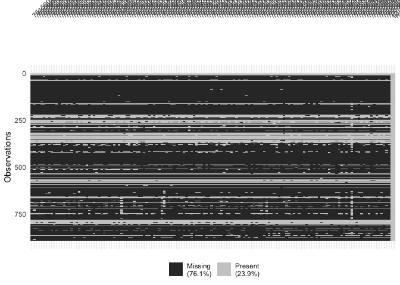

```r
# heatmap missing
vis_miss(lipidomics_data_CSF$raw_data,show_perc = TRUE,show_perc_col = TRUE,cluster = F)
```

```r
ggsave("plots/missing_vis_miss_heatmap_CSF.png", width = 15, height = 10, units = "in")

# filter for lipids that are quantified in at least 2/3 of the samples
lipidomics_data_CSF$se_filtered = filter_proteins(lipidomics_data_CSF$se,"fraction",min = 0.66)

#dimensions of the data
dim(lipidomics_data_CSF$se)
```

```
## [1] 892 144
```

```r
dim(lipidomics_data_CSF$se_filtered)
```

```
## [1] 186 144
```

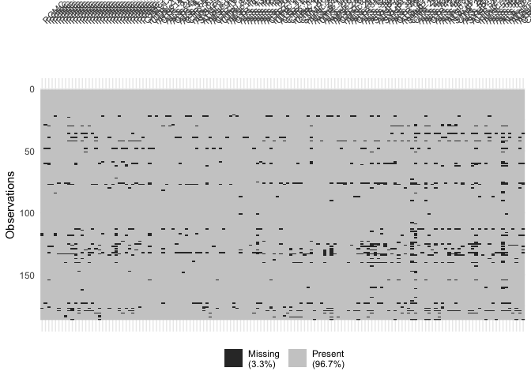

```r
# heatmap missing for filtered data
vis_miss(as.data.frame(assay(lipidomics_data_CSF$se_filtered)),show_perc = TRUE,show_perc_col = TRUE,cluster = F)
```

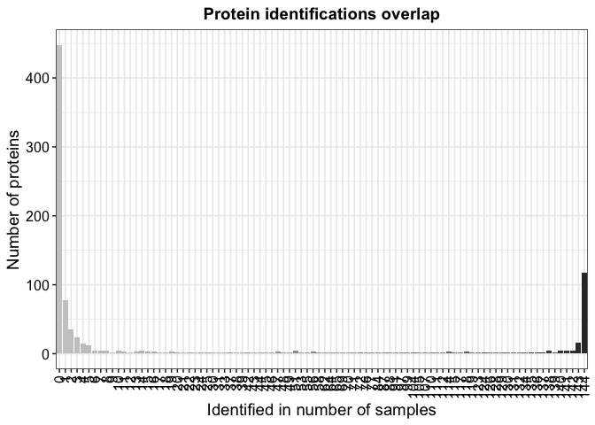

```r
ggsave("plots/missing_vis_miss_heatmap_filtered_CSF.png", width = 12, height = 8, units = "in")

plot_frequency(lipidomics_data_CSF$se)
```

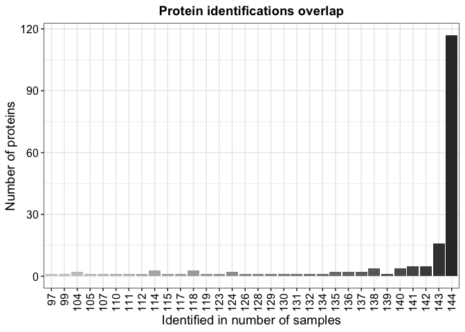

```r
ggsave("plots/frequency_met_identification_raw_CSF.pdf", width = 11, height = 8, units = "in")
plot_frequency(lipidomics_data_CSF$se_filtered)
```

```r
ggsave("plots/frequency_met_identification_filtered_CSF.pdf", width = 11, height = 8, units = "in")

# % missing per patient:
round(apply(X = as.data.frame(assay(lipidomics_data_CSF$se)), function(x) sum(is.na(x)), MARGIN = 2) / nrow(as.data.frame(assay(lipidomics_data_CSF$se))) * 100 , 1)
```

```
##   PGMC_1   PGMC_2   PGMC_3   PGMC_4   PGMC_5   PGMC_6   PGMC_7   PGMC_8
##     77.5     76.3     77.9     77.5     77.4     77.7     77.0     77.2
##   PGMC_9  PGMC_10  PGMC_11  PGMC_12  PGMC_13  PGMC_14  PGMC_15  PGMC_16
##     79.0     79.8     76.9     78.6     76.7     78.6     77.8     77.7
##  PGMC_17  PGMC_18  PGMC_19  PGMC_20  PGMC_21  PGMC_22  PGMC_23  PGMC_24
##     78.3     78.6     77.1     76.6     77.5     77.6     78.9     79.0
##  PGMC_25  PGMC_26  PGMC_27  PGMC_28  PGMC_29  PGMC_30    CTR_1  mimic_1
##     78.6     78.0     77.5     77.2     78.4     77.8     76.5     73.0
##    CTR_2  mimic_2    ALS_1    CTR_3    ALS_2    ALS_3    ALS_4    CTR_4
##     77.1     75.8     73.8     73.3     78.3     75.9     76.5     76.9
##    ALS_5    ALS_6    CTR_5    CTR_6  mimic_3    ALS_7   SYMP_1    ALS_8
##     76.1     76.2     75.9     77.2     77.0     74.8     78.0     76.3
##  mimic_4    ALS_9   ALS_10    CTR_7  mimic_5    CTR_8  mimic_6   ALS_11
##     76.3     78.5     76.1     76.3     76.1     76.8     76.1     75.8
##   ALS_12    CTR_9   ALS_13   ALS_14   ALS_15   ALS_16   ALS_17   ALS_18
##     76.6     76.9     75.7     72.5     74.6     73.9     73.5     76.9
##   ALS_19   ALS_20   ALS_21   CTR_10  mimic_7   CTR_11   ALS_22   CTR_12
##     78.3     76.2     78.4     77.7     78.4     78.6     75.0     72.9
##   CTR_13   CTR_14  mimic_8   CTR_15   CTR_16   SYMP_2  mimic_9   ALS_23
##     78.4     77.1     77.6     77.6     78.0     77.8     75.4     77.9
##   ALS_24 mimic_10   CTR_17   ALS_25   ALS_26 mimic_11   ALS_27   ALS_28
##     79.1     75.6     76.9     77.0     78.6     76.6     79.9     75.8
##   CTR_18 mimic_12   ALS_29   ALS_30   ALS_31   CTR_19   ALS_32   ALS_33
##     77.9     76.0     76.2     75.3     77.9     77.7     78.1     78.8
##   ALS_34   ALS_35   SYMP_3   ALS_36   ALS_37   SYMP_4   ALS_38   ALS_39
##     78.5     79.3     80.0     78.0     79.0     78.1     77.5     78.0
##   ALS_40   CTR_20   ALS_41 mimic_13   SYMP_5   CTR_21   CTR_22   ALS_42
##     75.2     79.0     77.9     77.5     76.5     77.2     80.4     81.1
##   ALS_43   ALS_44   ALS_45   CTR_23   ALS_46   ALS_47   ALS_48 mimic_14
##     76.6     74.4     79.3     79.1     77.1     78.7     77.9     78.8
##   ALS_49   N.A._1   SYMP_6   CTR_24   ALS_50   ALS_51   SYMP_7   ALS_52
##     77.5     79.4     78.1     79.0     77.8     76.0     76.3     77.7
##   CTR_25 mimic_15 mimic_16   ALS_53   ALS_54   ALS_55   ALS_56   ALS_57
##     78.8     79.8     77.9     59.3     78.3     78.4     78.0     76.6
##   ALS_58   N.A._2 mimic_17   ALS_59 mimic_18   ALS_60   CTR_26   CTR_27
##     74.9     81.6     80.2     77.4     76.9     77.0     78.3     78.5
```

```r
round(apply(X = as.data.frame(assay(lipidomics_data_CSF$se_filtered)), function(x) sum(is.na(x)), MARGIN = 2) / nrow(as.data.frame(assay(lipidomics_data_CSF$se_filtered))) * 100 , 1)
```

```
##   PGMC_1   PGMC_2   PGMC_3   PGMC_4   PGMC_5   PGMC_6   PGMC_7   PGMC_8
##      1.6      2.2      5.4      1.1      2.2      2.2      0.5      2.7
##   PGMC_9  PGMC_10  PGMC_11  PGMC_12  PGMC_13  PGMC_14  PGMC_15  PGMC_16
##      6.5      6.5      7.0      3.2      4.8      3.8      3.8      3.8
##  PGMC_17  PGMC_18  PGMC_19  PGMC_20  PGMC_21  PGMC_22  PGMC_23  PGMC_24
##      3.2      4.8      2.2      0.5      2.2      2.7      7.0      3.8
##  PGMC_25  PGMC_26  PGMC_27  PGMC_28  PGMC_29  PGMC_30    CTR_1  mimic_1
##      3.2      3.8      3.8      4.8      3.2      2.7      2.2      0.0
##    CTR_2  mimic_2    ALS_1    CTR_3    ALS_2    ALS_3    ALS_4    CTR_4
##      5.4      0.5      0.5      0.0      3.2      1.1      1.1      1.1
##    ALS_5    ALS_6    CTR_5    CTR_6  mimic_3    ALS_7   SYMP_1    ALS_8
##      1.6      2.7      1.1      2.7      1.6      2.2      3.8      1.1
##  mimic_4    ALS_9   ALS_10    CTR_7  mimic_5    CTR_8  mimic_6   ALS_11
##      2.2      4.8      1.6      1.1      1.1      2.2      1.1      0.5
##   ALS_12    CTR_9   ALS_13   ALS_14   ALS_15   ALS_16   ALS_17   ALS_18
##      1.1      1.6      1.1      2.2      0.5      0.5      0.5      1.6
##   ALS_19   ALS_20   ALS_21   CTR_10  mimic_7   CTR_11   ALS_22   CTR_12
##      6.5      2.2      3.2      1.6      3.8      2.7      0.5      2.7
##   CTR_13   CTR_14  mimic_8   CTR_15   CTR_16   SYMP_2  mimic_9   ALS_23
##      2.7      1.6      3.8      2.2      2.7      3.8      1.1      2.2
##   ALS_24 mimic_10   CTR_17   ALS_25   ALS_26 mimic_11   ALS_27   ALS_28
##      6.5      1.1      1.1      1.1      4.3      2.2      8.1      1.1
##   CTR_18 mimic_12   ALS_29   ALS_30   ALS_31   CTR_19   ALS_32   ALS_33
##      2.2      1.6      1.6      1.1      2.2      2.2      3.2      4.3
##   ALS_34   ALS_35   SYMP_3   ALS_36   ALS_37   SYMP_4   ALS_38   ALS_39
##      3.2      5.9      9.1      5.4      6.5      4.3      4.8      2.7
##   ALS_40   CTR_20   ALS_41 mimic_13   SYMP_5   CTR_21   CTR_22   ALS_42
##      3.2      5.4      4.3      3.2      2.2      2.7     11.3     14.0
##   ALS_43   ALS_44   ALS_45   CTR_23   ALS_46   ALS_47   ALS_48 mimic_14
##      2.7      1.1      8.1      6.5      1.6      7.0      3.2      5.4
##   ALS_49   N.A._1   SYMP_6   CTR_24   ALS_50   ALS_51   SYMP_7   ALS_52
##      1.6      6.5      3.2      7.5      4.3      2.7      0.5      2.2
##   CTR_25 mimic_15 mimic_16   ALS_53   ALS_54   ALS_55   ALS_56   ALS_57
##      7.0      9.7      3.8      0.5      3.8      3.8      3.8      1.6
##   ALS_58   N.A._2 mimic_17   ALS_59 mimic_18   ALS_60   CTR_26   CTR_27
##      0.5     17.7      8.6      3.2      1.6      3.2      4.8      5.4
```

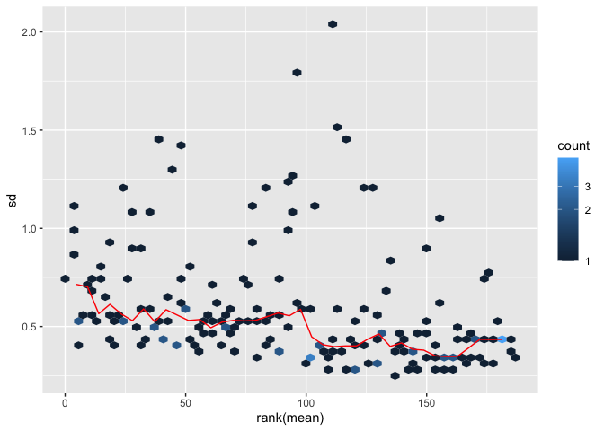

```r
#normalization
lipidomics_data_CSF$se_filt_norm <- normalize_vsn(lipidomics_data_CSF$se_filtered)
DEP::meanSdPlot(lipidomics_data_CSF$se_filt_norm)
```

```r
writexl::write_xlsx(as.data.frame(assay(lipidomics_data_CSF$se_filtered)),"results/data_filtered_CSF.xlsx")
writexl::write_xlsx(as.data.frame(assay(lipidomics_data_CSF$se_filt_norm)),"results/data_filtered_normalized_CSF.xlsx")

# imputation
set.seed(42)
lipidomics_data_CSF$se_filt_impute <- impute(
  lipidomics_data_CSF$se_filt_norm,fun = "MinProb",q = 0.01)
```

```
## Imputing along margin 2 (samples/columns).
```

```
## [1] 0.4905946
```

```r
writexl::write_xlsx(as.data.frame(assay(lipidomics_data_CSF$se_filt_impute)),"results/data_filtered_normalized_imputed_CSF.xlsx")
```

#### - Plasma

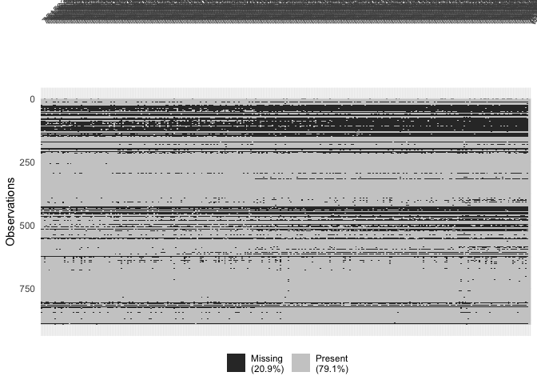

```r
# heatmap missing
vis_miss(lipidomics_data_plasma$raw_data,show_perc = TRUE,show_perc_col = TRUE,cluster = F)
```

```r
ggsave("plots/missing_vis_miss_heatmap_plasma.png", width = 15, height = 10, units = "in")

# filter for lipids that are quantified in at least 2/3 of the samples
lipidomics_data_plasma$se_filtered = filter_proteins(lipidomics_data_plasma$se,"fraction",min = 0.66)

#dimensions of the data
dim(lipidomics_data_plasma$se)
```

```
## [1] 892 316
```

```r
dim(lipidomics_data_plasma$se_filtered)
```

```
## [1] 684 316
```

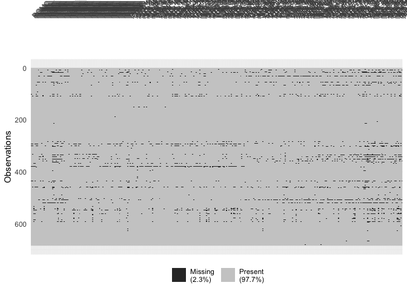

```r
# heatmap missing for filtered data
vis_miss(as.data.frame(assay(lipidomics_data_plasma$se_filtered)),show_perc = TRUE,show_perc_col = TRUE,cluster = F)
```

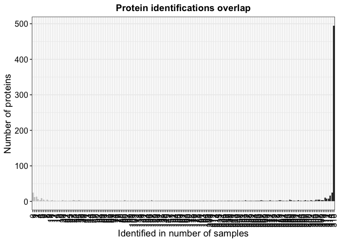

```r
ggsave("plots/missing_vis_miss_heatmap_filtered_plasma.png", width = 12, height = 8, units = "in")

plot_frequency(lipidomics_data_plasma$se)
```

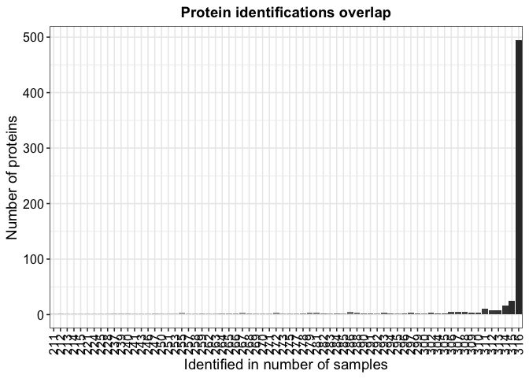

```r
ggsave("plots/frequency_met_identification_raw_plasma.pdf", width = 11, height = 8, units = "in")
plot_frequency(lipidomics_data_plasma$se_filtered)
```

```r
ggsave("plots/frequency_met_identification_filtered_plasma.pdf", width = 11, height = 8, units = "in")

# % missing per patient:
round(apply(X = as.data.frame(assay(lipidomics_data_plasma$se)), function(x) sum(is.na(x)), MARGIN = 2) / nrow(as.data.frame(assay(lipidomics_data_plasma$se))) * 100 , 1)
```

```
##   PGMC_1   PGMC_2   PGMC_3   PGMC_4   PGMC_5   PGMC_6   PGMC_7   PGMC_8
##     16.6     18.7     19.7     19.1     19.5     18.8     20.0     20.7
##   PGMC_9  PGMC_10  PGMC_11  PGMC_12  PGMC_13  PGMC_14  PGMC_15  PGMC_16
##     22.0     22.6     23.1     23.7     22.3     21.1     21.3     22.2
##  PGMC_17  PGMC_18  PGMC_19  PGMC_20  PGMC_21  PGMC_22  PGMC_23  PGMC_24
##     22.4     22.3     27.9     29.1     25.7     24.3     27.5     28.4
##  PGMC_25  PGMC_26  PGMC_27  PGMC_28  PGMC_29  PGMC_30  PGMC_31  PGMC_32
##     24.4     26.9     26.8     24.8     23.1     22.1     22.6     22.1
##  PGMC_33  PGMC_34  PGMC_35  PGMC_36  PGMC_37  PGMC_38  PGMC_39  PGMC_40
##     16.8     16.7     16.7     18.6     20.2     19.3     17.8     18.0
##  PGMC_41  PGMC_42  PGMC_43  PGMC_44  PGMC_45  PGMC_46  PGMC_47  PGMC_48
##     18.5     20.4     20.0     16.6     18.2     18.5     19.1     17.9
##  PGMC_49  PGMC_50  PGMC_51  PGMC_52  PGMC_53  PGMC_54  PGMC_55  PGMC_56
##     18.5     17.9     19.8     23.8     25.0     20.0     20.1     21.5
##  PGMC_57  PGMC_58  PGMC_59  PGMC_60  PGMC_61  PGMC_62  PGMC_63  PGMC_64
##     21.3     22.4     17.4     15.5     17.9     18.2     16.4     16.8
##  PGMC_65  PGMC_66  PGMC_67  PGMC_68  PGMC_69  PGMC_70  PGMC_71  PGMC_72
##     17.5     18.6     16.7     18.0     23.3     23.0     16.1     19.4
##  PGMC_73  PGMC_74  PGMC_75  PGMC_76  PGMC_77  PGMC_78  PGMC_79  PGMC_80
##     19.1     20.1     18.7     23.1     18.3     21.6     20.6     19.1
##  PGMC_81  PGMC_82  PGMC_83  PGMC_84    ALS_1    CTR_1    CTR_2    ALS_2
##     19.7     22.9     28.1     25.4     18.2     17.9     17.6     16.0
##    CTR_3    ALS_3    ALS_4    CTR_4    ALS_5    ALS_6    ALS_7   SYMP_1
##     17.8     17.9     20.9     15.7     16.8     15.8     17.2     16.4
##    ALS_8    ALS_9    CTR_5    CTR_6   ALS_10   ALS_11   ALS_12    CTR_7
##     15.7     14.1     16.1     15.5     18.3     18.4     18.2     21.7
##    CTR_8    CTR_9   SYMP_2   CTR_10   ALS_13   CTR_11   ALS_14   ALS_15
##     16.6     16.8     17.2     18.8     16.7     18.2     16.4     16.5
##   ALS_16   CTR_12   ALS_17   ALS_18   ALS_19   CTR_13   ALS_20   ALS_21
##     14.8     17.4     14.8     17.4     15.4     16.0     15.4     16.8
##   CTR_14  mimic_1  mimic_2  mimic_3   ALS_22   CTR_15   CTR_16  mimic_4
##     17.9     18.3     20.0     19.2     21.9     18.0     17.2     17.0
##   ALS_23   CTR_17   ALS_24   CTR_18  mimic_5   CTR_19   CTR_20  mimic_6
##     18.4     17.6     17.2     19.8     19.3     17.5     18.5     17.5
##   CTR_21   CTR_22  mimic_7   ALS_25   CTR_23  mimic_8   ALS_26   ALS_27
##     17.8     20.1     18.5     16.8     19.2     20.1     17.7     23.8
##   ALS_28   ALS_29   ALS_30   CTR_24   CTR_25   ALS_31   CTR_26   CTR_27
##     16.1     19.5     17.3     21.0     19.7     21.1     19.3     20.0
##   ALS_32   ALS_33   CTR_28   CTR_29   CTR_30   CTR_31   CTR_32   CTR_33
##     18.9     17.2     16.7     17.3     18.9     19.6     19.3     19.1
```

[output cut: 25 more lines]

```
##     21.7     23.3     23.3     21.6     22.2     26.3     22.4     23.2
##   ALS_76   CTR_71   CTR_72   ALS_77   ALS_78 mimic_25   ALS_79   ALS_80
##     22.8     23.9     23.2     23.2     25.2     21.6     22.6     22.9
##   CTR_73   CTR_74   CTR_75   ALS_81   CTR_76   ALS_82   CTR_77   ALS_83
##     20.1     23.1     23.9     26.0     22.3     23.3     23.5     23.3
##   ALS_84   N.A._2 mimic_26  SYMP_11   CTR_78   CTR_79   ALS_85   CTR_80
##     23.4     22.2     23.4     28.9     27.6     27.7     31.1     29.3
##   ALS_86   ALS_87   ALS_88   ALS_89   ALS_90 mimic_27   CTR_81   ALS_91
##     25.0     25.1     27.0     27.0     28.9     24.4     25.8     27.5
##   ALS_92   ALS_93   ALS_94   ALS_95  SYMP_12   ALS_96   CTR_82   ALS_97
##     25.8     25.9     28.1     25.7     26.3     25.4     23.0     24.2
##   ALS_98  PGMC_85   CTR_83   ALS_99  ALS_100  ALS_101  ALS_102  PGMC_86
##     25.3     23.0     26.7     23.0     25.7     24.7     25.8     27.5
## mimic_28  ALS_103 mimic_29  ALS_104
##     26.9     27.1     27.6     23.2
```

```r
round(apply(X = as.data.frame(assay(lipidomics_data_plasma$se_filtered)), function(x) sum(is.na(x)), MARGIN = 2) / nrow(as.data.frame(assay(lipidomics_data_plasma$se_filtered))) * 100 , 1)
```

```
##   PGMC_1   PGMC_2   PGMC_3   PGMC_4   PGMC_5   PGMC_6   PGMC_7   PGMC_8
##      1.6      2.5      4.8      3.9      2.3      1.8      0.9      1.2
##   PGMC_9  PGMC_10  PGMC_11  PGMC_12  PGMC_13  PGMC_14  PGMC_15  PGMC_16
##      1.6      2.6      2.9      3.4      1.8      0.7      1.2      1.3
##  PGMC_17  PGMC_18  PGMC_19  PGMC_20  PGMC_21  PGMC_22  PGMC_23  PGMC_24
##      1.5      1.8      6.6      7.9      4.8      3.7      6.3      7.6
##  PGMC_25  PGMC_26  PGMC_27  PGMC_28  PGMC_29  PGMC_30  PGMC_31  PGMC_32
##      2.9      5.8      5.7      3.9      2.8      1.3      1.6      1.6
##  PGMC_33  PGMC_34  PGMC_35  PGMC_36  PGMC_37  PGMC_38  PGMC_39  PGMC_40
##      1.3      1.3      0.7      1.3      2.6      2.3      1.5      2.0
##  PGMC_41  PGMC_42  PGMC_43  PGMC_44  PGMC_45  PGMC_46  PGMC_47  PGMC_48
##      1.3      3.4      2.8      0.6      1.2      0.9      2.0      1.3
##  PGMC_49  PGMC_50  PGMC_51  PGMC_52  PGMC_53  PGMC_54  PGMC_55  PGMC_56
##      0.9      1.3      1.6      2.9      5.8      1.2      1.0      2.2
##  PGMC_57  PGMC_58  PGMC_59  PGMC_60  PGMC_61  PGMC_62  PGMC_63  PGMC_64
##      1.5      1.8      1.8      0.4      2.8      2.2      0.6      2.0
##  PGMC_65  PGMC_66  PGMC_67  PGMC_68  PGMC_69  PGMC_70  PGMC_71  PGMC_72
##      1.2      1.3      0.4      0.9      1.9      2.3      0.4      2.9
##  PGMC_73  PGMC_74  PGMC_75  PGMC_76  PGMC_77  PGMC_78  PGMC_79  PGMC_80
##      1.0      2.8      0.9      5.4      1.3      1.2      1.0      0.4
##  PGMC_81  PGMC_82  PGMC_83  PGMC_84    ALS_1    CTR_1    CTR_2    ALS_2
##      1.0      1.8      7.0      4.2      2.8      0.9      1.8      0.4
##    CTR_3    ALS_3    ALS_4    CTR_4    ALS_5    ALS_6    ALS_7   SYMP_1
##      0.9      0.9      4.2      1.0      0.6      0.7      1.9      1.0
##    ALS_8    ALS_9    CTR_5    CTR_6   ALS_10   ALS_11   ALS_12    CTR_7
##      0.6      0.9      1.3      0.7      2.3      1.9      1.9      5.8
##    CTR_8    CTR_9   SYMP_2   CTR_10   ALS_13   CTR_11   ALS_14   ALS_15
##      0.3      0.9      0.9      1.3      1.0      1.5      0.9      0.6
##   ALS_16   CTR_12   ALS_17   ALS_18   ALS_19   CTR_13   ALS_20   ALS_21
##      0.1      1.0      0.4      1.8      0.7      0.1      0.4      0.7
##   CTR_14  mimic_1  mimic_2  mimic_3   ALS_22   CTR_15   CTR_16  mimic_4
##      2.0      0.3      2.9      1.9      4.1      0.6      1.0      0.9
##   ALS_23   CTR_17   ALS_24   CTR_18  mimic_5   CTR_19   CTR_20  mimic_6
##      1.6      1.0      1.3      1.9      2.0      2.3      1.6      0.9
##   CTR_21   CTR_22  mimic_7   ALS_25   CTR_23  mimic_8   ALS_26   ALS_27
##      1.5      2.2      0.9      0.3      1.5      1.3      0.6      6.3
##   ALS_28   ALS_29   ALS_30   CTR_24   CTR_25   ALS_31   CTR_26   CTR_27
##      0.6      1.3      0.3      2.8      1.9      3.9      1.5      1.9
##   ALS_32   ALS_33   CTR_28   CTR_29   CTR_30   CTR_31   CTR_32   CTR_33
##      1.0      0.6      0.4      0.4      2.2      2.0      1.8      2.2
```

[output cut: 25 more lines]

```
##      1.2      3.1      2.6      1.2      1.8      6.0      1.5      1.9
##   ALS_76   CTR_71   CTR_72   ALS_77   ALS_78 mimic_25   ALS_79   ALS_80
##      2.2      3.1      2.2      2.6      4.5      1.2      1.8      1.6
##   CTR_73   CTR_74   CTR_75   ALS_81   CTR_76   ALS_82   CTR_77   ALS_83
##      0.9      2.8      3.5      6.1      2.2      2.0      2.8      3.4
##   ALS_84   N.A._2 mimic_26  SYMP_11   CTR_78   CTR_79   ALS_85   CTR_80
##      2.6      1.5      2.5      8.0      6.7      6.4     10.8      9.1
##   ALS_86   ALS_87   ALS_88   ALS_89   ALS_90 mimic_27   CTR_81   ALS_91
##      4.2      4.2      6.6      5.7      8.8      3.2      4.5      7.0
##   ALS_92   ALS_93   ALS_94   ALS_95  SYMP_12   ALS_96   CTR_82   ALS_97
##      4.7      4.7      7.9      4.7      4.7      4.5      2.2      3.4
##   ALS_98  PGMC_85   CTR_83   ALS_99  ALS_100  ALS_101  ALS_102  PGMC_86
##      4.4      3.5      5.4      2.5      4.7      3.7      4.2      6.1
## mimic_28  ALS_103 mimic_29  ALS_104
##      6.3      6.7      6.4      2.6
```

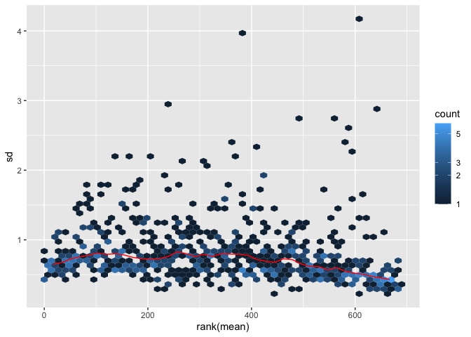

```r
#normalization
lipidomics_data_plasma$se_filt_norm <- normalize_vsn(lipidomics_data_plasma$se_filtered)
DEP::meanSdPlot(lipidomics_data_plasma$se_filt_norm)
```

```r
writexl::write_xlsx(as.data.frame(assay(lipidomics_data_plasma$se_filtered)),"results/data_filtered_plasma.xlsx")
writexl::write_xlsx(as.data.frame(assay(lipidomics_data_plasma$se_filt_norm)),"results/data_filtered_normalized_plasma.xlsx")

# imputation
set.seed(42)
lipidomics_data_plasma$se_filt_impute <- impute(
  lipidomics_data_plasma$se_filt_norm,fun = "MinProb",q = 0.01)
```

```
## Imputing along margin 2 (samples/columns).
```

```
## [1] 0.6924497
```

```r
writexl::write_xlsx(as.data.frame(assay(lipidomics_data_plasma$se_filt_impute)),"results/data_filtered_normalized_imputed_plasma.xlsx")
```

#### - CSF

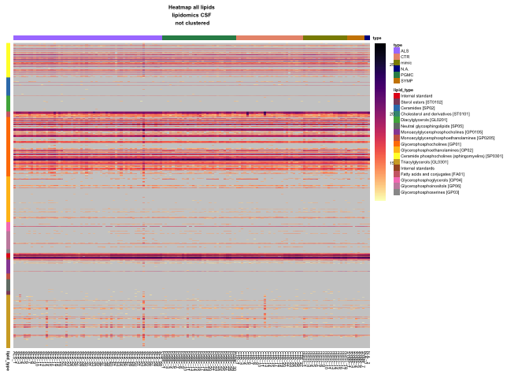

```r
## Distribution of expression values per ID and tube number
mean_expression_plot(data = t(assay(lipidomics_data_CSF$se)),
                      file_sample = "plots/boxplots_expression_each_sample_CSF.pdf",
                      file_mass = "plots/boxplots_expression_each_lipid_CSF.pdf",
                      title = "CSF lipidomics")

## Heatmaps
# CSF
title = "lipidomics CSF"

data = assay(lipidomics_data_CSF$se)
data_z = t(scale(t(data),center = TRUE,scale = TRUE))
data_z[is.na(data_z)] <- 0

#row annotation
names_lipids = rownames(data)
Lipids_final <- read_excel("data input/RE_ metabolomics/Lipids_final.xlsx")
lipids = Lipids_final %>%
  select(Name,Class) %>%
  filter(Name %in% names_lipids)
lipids = lipids[match(lipids$Name,names_lipids),]
lipids_overview = lipids %>%
  group_by(Class) %>%
  summarise(n_lipids = n()) %>%
  arrange(desc(n_lipids))
writexl::write_xlsx(lipids_overview,"results/lipids_overview.xlsx")
annotation_row = data.frame(lipid_type = as.factor(lipids$Class))
rownames(annotation_row) = lipids$Name
participant_type = tube_batch_CSF
annotation_col = data.frame(type = as.factor(lipidomics_data_CSF$se$condition))
rownames(annotation_col) = lipidomics_data_CSF$se$ID
annotation_col$type <- factor(
  annotation_col$type,
  levels = c("ALS","PGMC","CTR","mimic","SYMP", "N.A."))
colors_type = c("mediumpurple1", "darksalmon", "yellow4","blue4","seagreen4","orange3")
names(colors_type) = c("ALS","CTR","mimic","N.A.","PGMC","SYMP")
mycolors = colorRampPalette(brewer.pal(9, "Set1"))(length(unique(annotation_row$lipid_type)))
names(mycolors) <- unique(annotation_row$lipid_type)
annotation_colours <- list(
  lipid_type = mycolors,
  type = colors_type)

# order data
row_order <- order(annotation_row$lipid_type)
col_order <- order(annotation_col$type)
data          <- data[row_order, col_order]
data_z          <- data_z[row_order, col_order]
annotation_row <- annotation_row[row_order, , drop = FALSE]
annotation_col <- annotation_col[col_order, , drop = FALSE]

#without grouping, all lipids, expression data
p = make_pheatmap(data = data,
                  cluster_cols = F,
                  main = paste0("Heatmap all lipids\n",title, "\n not clustered"),
                  show_rownames = F,
                  labels_col = colnames(data),
                  #color = colorRampPalette(c("navy", "white", "firebrick3"))(100))
                  color = viridis::magma(100, direction = -1))
```

```r
save_pheatmap_pdf(p, filename = paste0("plots/heatmap_raw_",title,".pdf"))
```

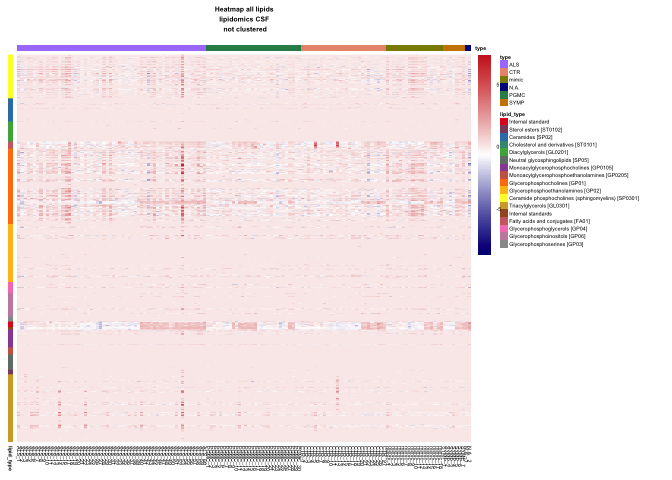

```r
#without grouping, all lipids, z-score
p = make_pheatmap(data = data_z,
                  cluster_cols = F,
                  main = paste0("Heatmap all lipids\n",title, "\n not clustered"),
                  show_rownames = F,
                  labels_col = colnames(data),
                  color = colorRampPalette(c("navy", "white", "firebrick3"))(100))
```

```r
                  #color = viridis::magma(100, direction = -1))
save_pheatmap_pdf(p, filename = paste0("plots/heatmap_zscore_raw_",title,".pdf"))
```

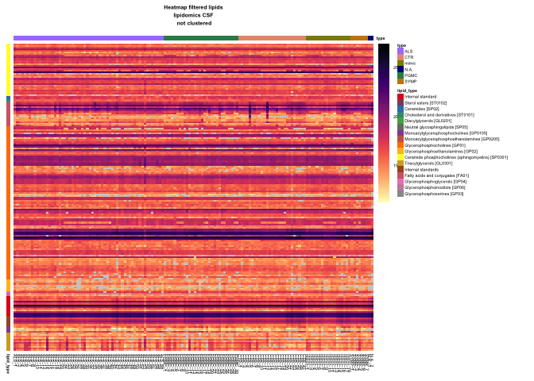

```r
#without grouping, filtered lipids
data = assay(lipidomics_data_CSF$se_filt_norm)
data_z = t(scale(t(data),center = TRUE,scale = TRUE))
data_z[is.na(data_z)] <- 0

#row annotation
names_lipids = rownames(data)
lipids = Lipids_final %>%
  select(Name,Class) %>%
  filter(Name %in% names_lipids)
idx <- match(names_lipids, lipids$Name)
keep <- !is.na(idx)
lipids <- lipids[idx[keep], ]
data   <- data[keep, , drop = FALSE]
annotation_row = data.frame(lipid_type = as.factor(lipids$Class))
rownames(annotation_row) = lipids$Name

# order data
row_order <- order(annotation_row$lipid_type)
data          <- data[row_order, col_order]
data_z          <- data_z[row_order, col_order]
annotation_row <- annotation_row[row_order, , drop = FALSE]

# expression data
p = make_pheatmap(data = data,
                  cluster_cols = F,
                  main = paste0("Heatmap filtered lipids\n",title, "\n not clustered"),
                  show_rownames = F,
                  labels_col = colnames(data),
                  #color = colorRampPalette(c("navy", "white", "firebrick3"))(100))
                  color = viridis::magma(100, direction = -1))
```

```r
save_pheatmap_pdf(p, filename = paste0("plots/heatmap_filtered_",title,".pdf"))
```

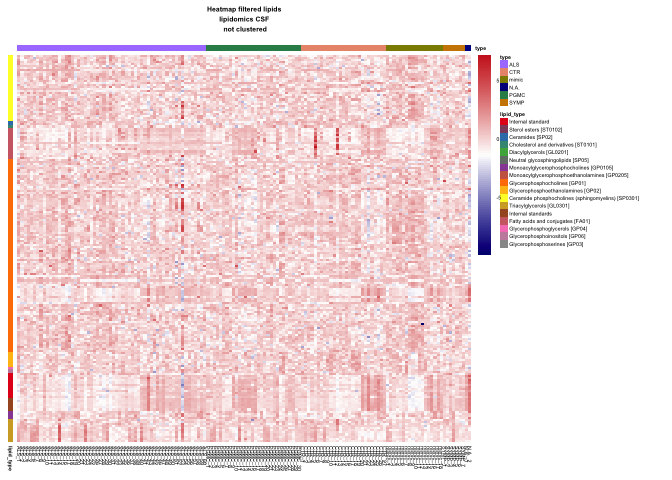

```r
# z-score
p = make_pheatmap(data = data_z,
                  cluster_cols = F,
                  main = paste0("Heatmap filtered lipids\n",title, "\n not clustered"),
                  show_rownames = F,
                  labels_col = colnames(data),
                  color = colorRampPalette(c("navy", "white", "firebrick3"))(100))
```

```r
                  #color = viridis::magma(100, direction = -1))
save_pheatmap_pdf(p, filename = paste0("plots/heatmap_zscore_filtered_",title,".pdf"))
```

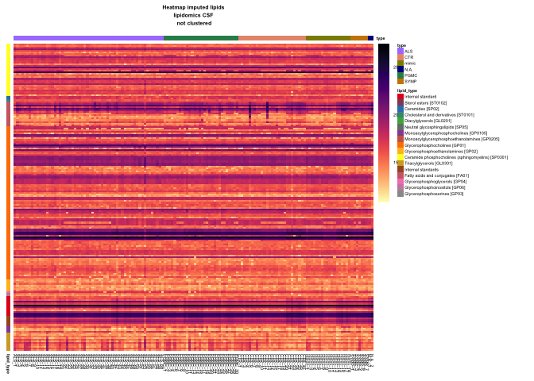

```r
#without grouping, filtered and imputed
data = assay(lipidomics_data_CSF$se_filt_impute)
data_z = t(scale(t(data),center = TRUE,scale = TRUE))
data_z[is.na(data_z)] <- 0

#row annotation
names_lipids = rownames(data)
lipids = Lipids_final %>%
  select(Name,Class) %>%
  filter(Name %in% names_lipids)
idx <- match(names_lipids, lipids$Name)
keep <- !is.na(idx)
lipids <- lipids[idx[keep], ]
data   <- data[keep, , drop = FALSE]
annotation_row = data.frame(lipid_type = as.factor(lipids$Class))
rownames(annotation_row) = lipids$Name

# order data
row_order <- order(annotation_row$lipid_type)
data          <- data[row_order, col_order]
data_z          <- data_z[row_order, col_order]
annotation_row <- annotation_row[row_order, , drop = FALSE]

# expression data
p = make_pheatmap(data = data,
                  cluster_cols = F,
                  main = paste0("Heatmap imputed lipids\n",title, "\n not clustered"),
                  show_rownames = F,
                  labels_col = colnames(data),
                  #color = colorRampPalette(c("navy", "white", "firebrick3"))(100))
                  color = viridis::magma(100, direction = -1))
```

```r
save_pheatmap_pdf(p, filename = paste0("plots/heatmap_imputed_",title,".pdf"))
```

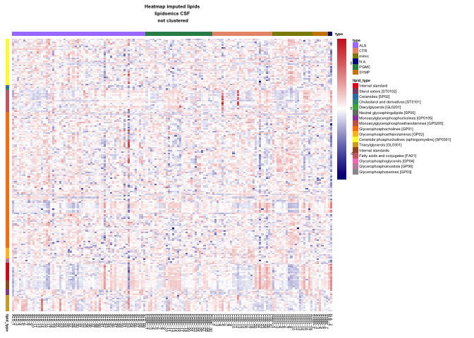

```r
# z-score
p = make_pheatmap(data = data_z,
                  cluster_cols = F,
                  main = paste0("Heatmap imputed lipids\n",title, "\n not clustered"),
                  show_rownames = F,
                  labels_col = colnames(data),
                  color = colorRampPalette(c("navy", "white", "firebrick3"))(100))
```

```r
                  #color = viridis::magma(100, direction = -1))
save_pheatmap_pdf(p, filename = paste0("plots/heatmap_zscore_imputed_",title,".pdf"))
```

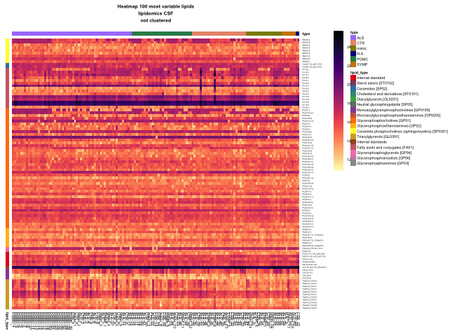

```r
# without grouping, 100 most variable lipids
d = assay(lipidomics_data_CSF$se_filt_impute)
d2 = head(order(rowVars(d),decreasing = T),100)
data = d[d2,]
data_z = t(scale(t(data),center = TRUE,scale = TRUE))
data_z[is.na(data_z)] <- 0

#row annotation
names_lipids = rownames(data)
lipids = Lipids_final %>%
  select(Name,Class) %>%
  filter(Name %in% names_lipids)
idx <- match(names_lipids, lipids$Name)
keep <- !is.na(idx)
lipids <- lipids[idx[keep], ]
data   <- data[keep, , drop = FALSE]
annotation_row = data.frame(lipid_type = as.factor(lipids$Class))
rownames(annotation_row) = lipids$Name

# order data
row_order <- order(annotation_row$lipid_type)
data          <- data[row_order, col_order]
data_z          <- data_z[row_order, col_order]
annotation_row <- annotation_row[row_order, , drop = FALSE]

# expression data
p = make_pheatmap(data,
                  cluster_cols = F,
                  main = paste0("Heatmap 100 most variable lipids\n",title, "\nnot clustered"),
                  labels_col = colnames(d),
                  #color = colorRampPalette(c("navy", "white", "firebrick3"))(100))
                  color = viridis::magma(100, direction = -1))
```

```r
save_pheatmap_pdf(p, filename = paste0("plots/heatmap_imputed_mostvar_",title,".pdf"))
```

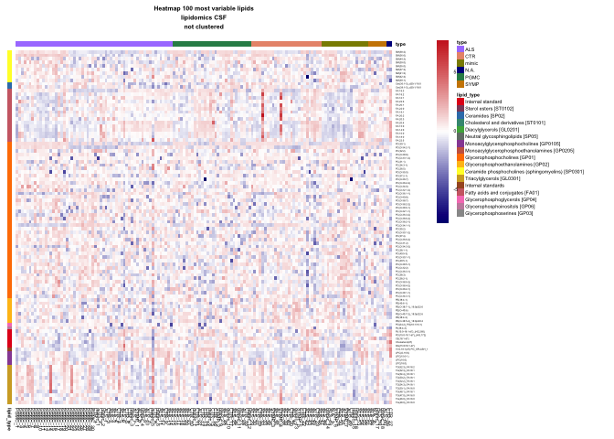

```r
# z-score
p = make_pheatmap(data_z,
                  cluster_cols = F,
                  main = paste0("Heatmap 100 most variable lipids\n",title, "\nnot clustered"),
                  labels_col = colnames(d),
                  color = colorRampPalette(c("navy", "white", "firebrick3"))(100))
```

```r
                  #color = viridis::magma(100, direction = -1))
save_pheatmap_pdf(p, filename = paste0("plots/heatmap_zscore_imputed_mostvar_",title,".pdf"))
```

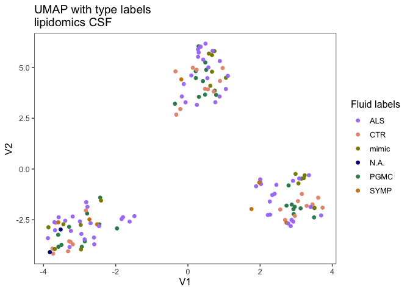

```r
## UMAP (with participant status type)
d_CSF = t(assay(lipidomics_data_CSF$se_filt_impute))
labels_group = tube_batch_CSF$type
group = c("mediumpurple1", "darksalmon", "yellow4","blue4","seagreen4","orange3")
UMAP_density_plot(data = d_CSF,
                          ggtitle = paste0("UMAP with type labels\n", title),
                          legend_name = "Fluid labels",
                          labels = labels_group,
                          file_location = paste0("plots/UMAP_type_",title,".pdf"),
                          file_location_labels =paste0("plots/UMAP_type_labels_",title,".pdf"),
                          colour_set = group)
```

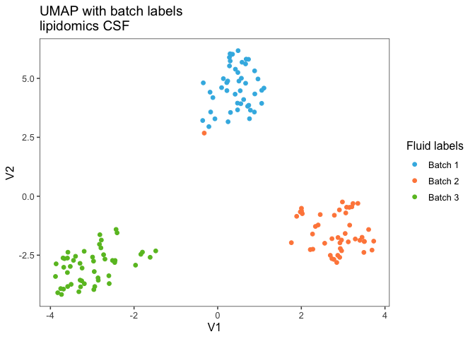

```r
# UMAP (with batch info)
labels_group = tube_batch_CSF$Batch
group = c("#3DB7E4", "#FF8849", "#69BE28")
UMAP_density_plot(data = d_CSF,
                          ggtitle = paste0("UMAP with batch labels\n", title),
                          legend_name = "Fluid labels",
                          labels = labels_group,
                          file_location = paste0("plots/UMAP_batch_",title,".pdf"),
                          file_location_labels =paste0("plots/UMAP_batch_labels_",title,".pdf"),
                          colour_set = group)
```

#### - Plasma

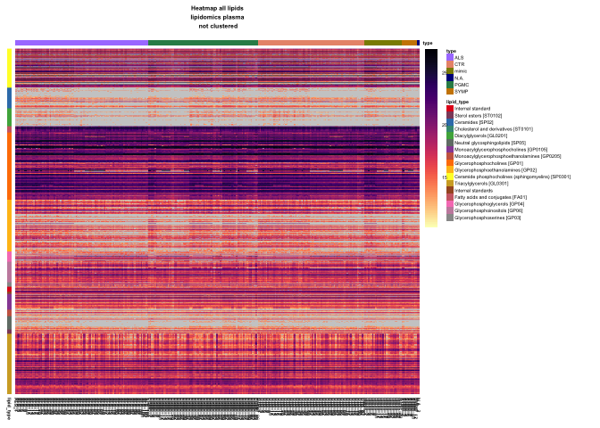

```r
## Distribution of expression values per ID and tube number
mean_expression_plot(data = t(assay(lipidomics_data_plasma$se)),
                      file_sample = "plots/boxplots_expression_each_sample_plasma.pdf",
                      file_mass = "plots/boxplots_expression_each_lipid_plasma.pdf",
                      title = "plasma lipidomics")

## Heatmaps
# plasma
title = "lipidomics plasma"

data = assay(lipidomics_data_plasma$se)
data_z = t(scale(t(data),center = TRUE,scale = TRUE))
data_z[is.na(data_z)] <- 0

#row annotation
names_lipids = rownames(data)
Lipids_final <- read_excel("data input/RE_ metabolomics/Lipids_final.xlsx")
lipids = Lipids_final %>%
  select(Name,Class) %>%
  filter(Name %in% names_lipids)
lipids = lipids[match(lipids$Name,names_lipids),]
annotation_row = data.frame(lipid_type = as.factor(lipids$Class))
rownames(annotation_row) = lipids$Name
participant_type = tube_batch_plasma
annotation_col = data.frame(type = as.factor(lipidomics_data_plasma$se$condition))
rownames(annotation_col) = lipidomics_data_plasma$se$ID
annotation_col$type <- factor(
  annotation_col$type,
  levels = c("ALS","PGMC","CTR","mimic","SYMP", "N.A."))
colors_type = c("mediumpurple1", "darksalmon", "yellow4","blue4","seagreen4","orange3")
names(colors_type) = c("ALS","CTR","mimic","N.A.","PGMC","SYMP")
mycolors = colorRampPalette(brewer.pal(9, "Set1"))(length(unique(annotation_row$lipid_type)))
names(mycolors) <- unique(annotation_row$lipid_type)
annotation_colours <- list(
  lipid_type = mycolors,
  type = colors_type)

# order data
row_order <- order(annotation_row$lipid_type)
col_order <- order(annotation_col$type)
data          <- data[row_order, col_order]
data_z          <- data_z[row_order, col_order]
annotation_row <- annotation_row[row_order, , drop = FALSE]
annotation_col <- annotation_col[col_order, , drop = FALSE]

#without grouping, all lipids, expression data
p = make_pheatmap(data = data,
                  cluster_cols = F,
                  main = paste0("Heatmap all lipids\n",title, "\n not clustered"),
                  show_rownames = F,
                  labels_col = colnames(data),
                  #color = colorRampPalette(c("navy", "white", "firebrick3"))(100))
                  color = viridis::magma(100, direction = -1))
```

```r
save_pheatmap_pdf(p, filename = paste0("plots/heatmap_raw_",title,".pdf"))
```

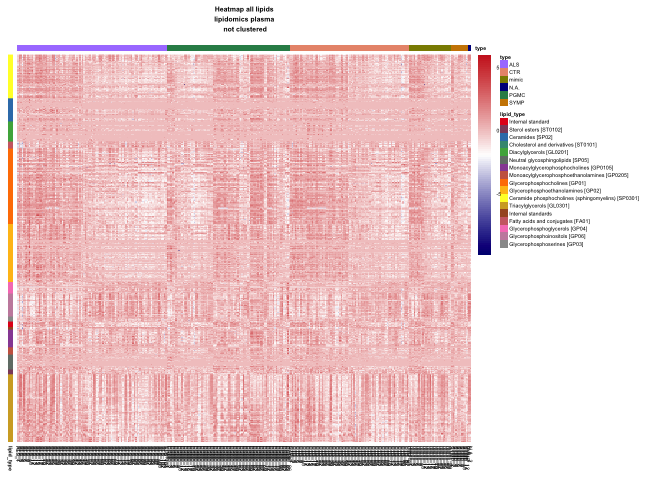

```r
#without grouping, all lipids, z-score
p = make_pheatmap(data = data_z,
                  cluster_cols = F,
                  main = paste0("Heatmap all lipids\n",title, "\n not clustered"),
                  show_rownames = F,
                  labels_col = colnames(data),
                  color = colorRampPalette(c("navy", "white", "firebrick3"))(100))
```

```r
                  #color = viridis::magma(100, direction = -1))
save_pheatmap_pdf(p, filename = paste0("plots/heatmap_zscore_raw_",title,".pdf"))
```

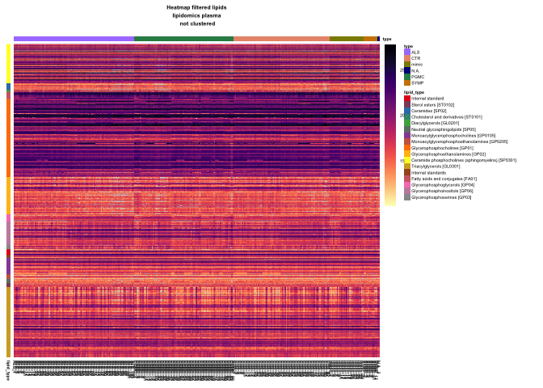

```r
#without grouping, filtered lipids
data = assay(lipidomics_data_plasma$se_filt_norm)
data_z = t(scale(t(data),center = TRUE,scale = TRUE))
data_z[is.na(data_z)] <- 0

#row annotation
names_lipids = rownames(data)
lipids = Lipids_final %>%
  select(Name,Class) %>%
  filter(Name %in% names_lipids)
idx <- match(names_lipids, lipids$Name)
keep <- !is.na(idx)
lipids <- lipids[idx[keep], ]
data   <- data[keep, , drop = FALSE]
annotation_row = data.frame(lipid_type = as.factor(lipids$Class))
rownames(annotation_row) = lipids$Name

# order data
row_order <- order(annotation_row$lipid_type)
data          <- data[row_order, col_order]
data_z          <- data_z[row_order, col_order]
annotation_row <- annotation_row[row_order, , drop = FALSE]

# expression data
p = make_pheatmap(data = data,
                  cluster_cols = F,
                  main = paste0("Heatmap filtered lipids\n",title, "\n not clustered"),
                  show_rownames = F,
                  labels_col = colnames(data),
                  #color = colorRampPalette(c("navy", "white", "firebrick3"))(100))
                  color = viridis::magma(100, direction = -1))
```

```r
save_pheatmap_pdf(p, filename = paste0("plots/heatmap_filtered_",title,".pdf"))
```

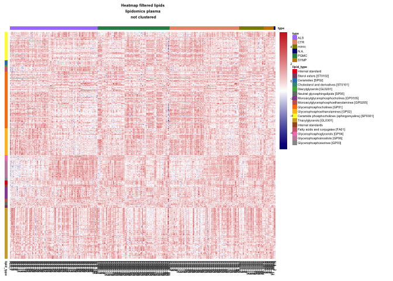

```r
# z-score
p = make_pheatmap(data = data_z,
                  cluster_cols = F,
                  main = paste0("Heatmap filtered lipids\n",title, "\n not clustered"),
                  show_rownames = F,
                  labels_col = colnames(data),
                  color = colorRampPalette(c("navy", "white", "firebrick3"))(100))
```

```r
                  #color = viridis::magma(100, direction = -1))
save_pheatmap_pdf(p, filename = paste0("plots/heatmap_zscore_filtered_",title,".pdf"))
```

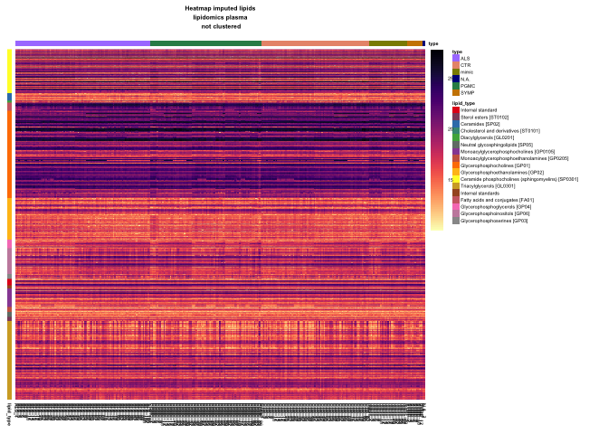

```r
#without grouping, filtered and imputed
data = assay(lipidomics_data_plasma$se_filt_impute)
data_z = t(scale(t(data),center = TRUE,scale = TRUE))
data_z[is.na(data_z)] <- 0

#row annotation
names_lipids = rownames(data)
lipids = Lipids_final %>%
  select(Name,Class) %>%
  filter(Name %in% names_lipids)
idx <- match(names_lipids, lipids$Name)
keep <- !is.na(idx)
lipids <- lipids[idx[keep], ]
data   <- data[keep, , drop = FALSE]
annotation_row = data.frame(lipid_type = as.factor(lipids$Class))
rownames(annotation_row) = lipids$Name

# order data
row_order <- order(annotation_row$lipid_type)
data          <- data[row_order, col_order]
data_z <- data_z[row_order, col_order]
annotation_row <- annotation_row[row_order, , drop = FALSE]

# expression data
p = make_pheatmap(data = data,
                  cluster_cols = F,
                  main = paste0("Heatmap imputed lipids\n",title, "\n not clustered"),
                  show_rownames = F,
                  labels_col = colnames(data),
                  #color = colorRampPalette(c("navy", "white", "firebrick3"))(100))
                  color = viridis::magma(100, direction = -1))
```

```r
save_pheatmap_pdf(p, filename = paste0("plots/heatmap_imputed_",title,".pdf"))
```

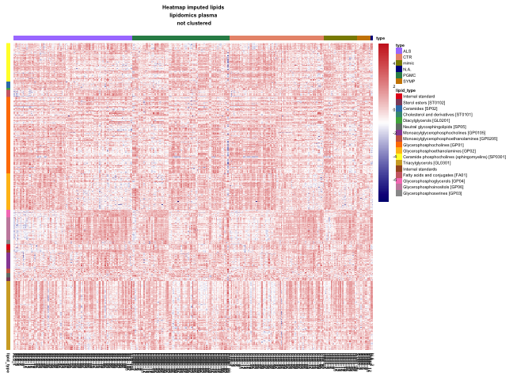

```r
# z-score
p = make_pheatmap(data = data_z,
                  cluster_cols = F,
                  main = paste0("Heatmap imputed lipids\n",title, "\n not clustered"),
                  show_rownames = F,
                  labels_col = colnames(data),
                  color = colorRampPalette(c("navy", "white", "firebrick3"))(100))
```

```r
                  #color = viridis::magma(100, direction = -1))
save_pheatmap_pdf(p, filename = paste0("plots/heatmap_zscore_imputed_",title,".pdf"))
```

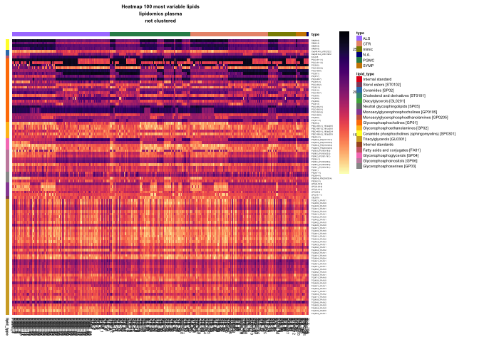

```r
# without grouping, 100 most variable lipids
d = assay(lipidomics_data_plasma$se_filt_impute)
d2 = head(order(rowVars(d),decreasing = T),100)
data = d[d2,]
data_z = t(scale(t(data),center = TRUE,scale = TRUE))
data_z[is.na(data_z)] <- 0

#row annotation
names_lipids = rownames(data)
lipids = Lipids_final %>%
  select(Name,Class) %>%
  filter(Name %in% names_lipids)
idx <- match(names_lipids, lipids$Name)
keep <- !is.na(idx)
lipids <- lipids[idx[keep], ]
data   <- data[keep, , drop = FALSE]
annotation_row = data.frame(lipid_type = as.factor(lipids$Class))
rownames(annotation_row) = lipids$Name

# order data
row_order <- order(annotation_row$lipid_type)
data          <- data[row_order, col_order]
data_z <- data_z[row_order, col_order]
annotation_row <- annotation_row[row_order, , drop = FALSE]

# expression data
p = make_pheatmap(data,
                  cluster_cols = F,
                  main = paste0("Heatmap 100 most variable lipids\n",title, "\nnot clustered"),
                  labels_col = colnames(d),
                  #color = colorRampPalette(c("navy", "white", "firebrick3"))(100))
                  color = viridis::magma(100, direction = -1))
```

```r
save_pheatmap_pdf(p, filename = paste0("plots/heatmap_imputed_mostvar_",title,".pdf"))
```

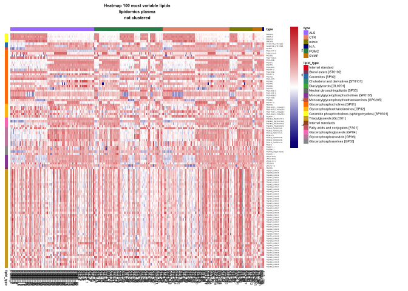

```r
# z-score
p = make_pheatmap(data_z,
                  cluster_cols = F,
                  main = paste0("Heatmap 100 most variable lipids\n",title, "\nnot clustered"),
                  labels_col = colnames(d),
                  color = colorRampPalette(c("navy", "white", "firebrick3"))(100))
```

```r
                  #color = viridis::magma(100, direction = -1))
save_pheatmap_pdf(p, filename = paste0("plots/heatmap_zscore_imputed_mostvar_",title,".pdf"))
```

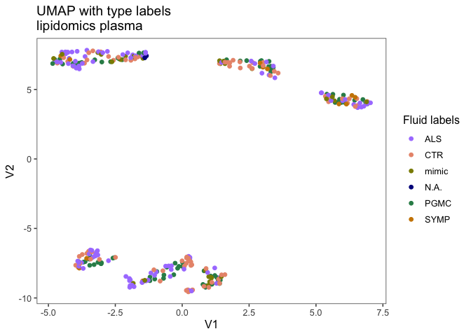

```r
## UMAP (with participant status type)
d_plasma = t(assay(lipidomics_data_plasma$se_filt_impute))
labels_group = tube_batch_plasma$type
group = c("mediumpurple1", "darksalmon", "yellow4","blue4","seagreen4","orange3")
UMAP_density_plot(data = d_plasma,
                          ggtitle = paste0("UMAP with type labels\n", title),
                          legend_name = "Fluid labels",
                          labels = labels_group,
                          file_location = paste0("plots/UMAP_type_",title,".pdf"),
                          file_location_labels =paste0("plots/UMAP_type_labels_",title,".pdf"),
                          colour_set = group)
```

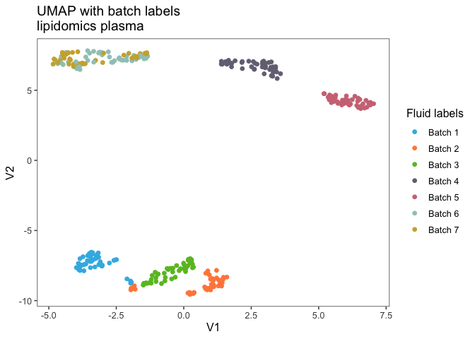

```r
# UMAP (with batch info)
labels_group = tube_batch_plasma$Batch
group = c("#3DB7E4", "#FF8849", "#69BE28","#757083","#CF7684","#A0C8C0","#CDAE3B")
UMAP_density_plot(data = d_plasma,
                          ggtitle = paste0("UMAP with batch labels\n", title),
                          legend_name = "Fluid labels",
                          labels = labels_group,
                          file_location = paste0("plots/UMAP_batch_",title,".pdf"),
                          file_location_labels =paste0("plots/UMAP_batch_labels_",title,".pdf"),
                          colour_set = group)
```

- CSF and Plasma together

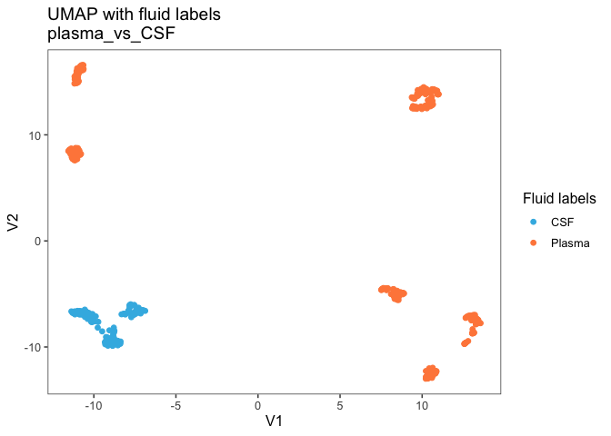

```r
 proteins_in_both_fluids = colnames(d_CSF)[colnames(d_CSF) %in% colnames(d_plasma)]

  d_1 = d_CSF[,proteins_in_both_fluids]
  d_2 = d_plasma[,proteins_in_both_fluids]

  d = do.call("rbind",list(d_1,d_2))

  labels_group = c(rep("CSF", nrow(d_1)), rep("Plasma", nrow(d_2)))
  title = "plasma_vs_CSF"

# UMAP of both biofluids
UMAP_density_plot(data = d,
                  ggtitle = paste0("UMAP with fluid labels\n", title),
                  legend_name = "Fluid labels",
                  labels = labels_group,
                  file_location = paste0("plots/UMAP_fluid_group_lipids_",title,".pdf"),
                  file_location_labels=paste0("plots/UMAP_fluid_group_labels_",title,".pdf"),
                  colour_set = group)
```

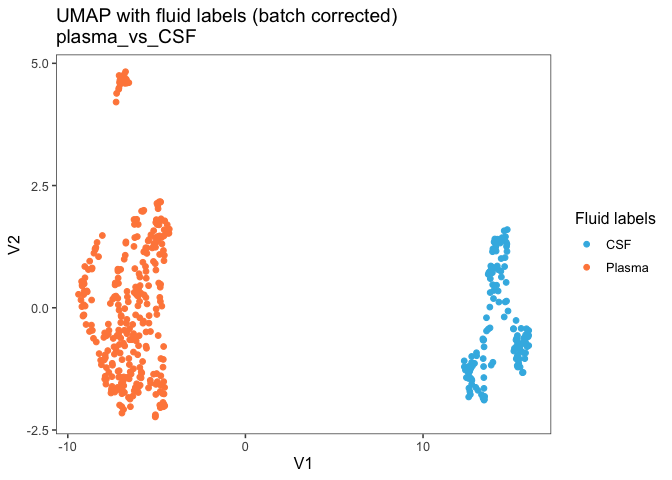

```r
# UMAP of both biofluids - batch corrected

batch_CSF = tube_batch_CSF$Batch
batch_plasma = tube_batch_plasma$Batch
batch = c(batch_CSF,batch_plasma)
fluid = labels_group
design = model.matrix(~fluid)

d_batch_corrected <- limma::removeBatchEffect(t(d), batch = batch, design = design)
d_batch_corrected <- t(d_batch_corrected)

UMAP_density_plot(data = d_batch_corrected,
                  ggtitle = paste0("UMAP with fluid labels (batch corrected)\n", title),
                  legend_name = "Fluid labels",
                  labels = labels_group,
                  file_location = paste0("plots/UMAP_fluid_group_lipids_batch_corrected",title,".pdf"),
                  file_location_labels=paste0("plots/UMAP_fluid_group_labels_batch_corrected",title,".pdf"),
                  colour_set = group)
```